# Kinematic and acoustic contributors to sensorimotor control of speech in Parkinson’s disease

Teja Rebernik

Generated on: Thu Sep 26 10:33:51 2024

The following R Markdown file shows model summaries and visualizations accompanying the analysis of acoustic and kinematic contributors to sensorimotor control of speech in Parkinson’s disease.

Due to the computing demands of generalized additive models, all models have been previously run and saved. The code used to generate them, however, is provided

# 1 Libraries

```r
library(mgcv)
library(itsadug)
library(dplyr)
```

```r
library(tidyr)
library(ggplot2)
library(car)
packageVersion("mgcv")
```

```
## [1] '1.9.1'
```

```r
packageVersion("itsadug")
```

```
## [1] '2.4.1'
```

# 2 Adaptive responses to predictable vowel formant perturbation

## 2.1 Data preparation

```r
#load the data and prepare it for analysis
adaptive <- read.csv("dataset_consistent_0606.csv", header=T)
str(adaptive)
```

```
## 'data.frame':    152702 obs. of  26 variables:
##  $ participant   : chr  "TRCS02" "TRCS02" "TRCS02" "TRCS02" ...
##  $ measure       : chr  "mean_f1" "mean_f1" "mean_f1" "mean_f1" ...
##  $ mean_value    : num  520 520 520 520 520 ...
##  $ sd_value      : num  41.9 41.9 41.9 41.9 41.9 ...
##  $ trial         : int  1 2 3 4 5 6 7 8 9 10 ...
##  $ duration      : num  95 145 155 145 150 ...
##  $ target_word   : chr  "wet" "pet" "net" "wet" ...
##  $ phase         : chr  "start" "start" "start" "start" ...
##  $ value         : num  486 478 483 539 463 ...
##  $ perc.value    : num  -6.51 -8.12 -7.09 3.7 -10.87 ...
##  $ z.value       : num  -0.806 -1.006 -0.879 0.459 -1.348 ...
##  $ group         : chr  "CS" "CS" "CS" "CS" ...
##  $ age           : num  70.7 70.7 70.7 70.7 70.7 70.7 70.7 70.7 70.7 70.7 ...
##  $ sex           : chr  "V" "V" "V" "V" ...
##  $ moca          : int  27 27 27 27 27 27 27 27 27 27 ...
##  $ hearing_better: chr  "moderate" "moderate" "moderate" "moderate" ...
##  $ hearing_worse : chr  "moderate" "moderate" "moderate" "moderate" ...
##  $ year_dx       : int  NA NA NA NA NA NA NA NA NA NA ...
##  $ mds_updrsIII  : int  NA NA NA NA NA NA NA NA NA NA ...
##  $ subtype       : chr  "" "" "" "" ...
##  $ how_typical   : num  75.9 75.9 75.9 75.9 75.9 75.9 75.9 75.9 75.9 75.9 ...
##  $ sd_severity   : num  17.2 17.2 17.2 17.2 17.2 ...
##  $ ACUITY        : num  2.46 2.46 2.46 2.46 2.46 ...
##  $ BIAS          : num  3.9 3.9 3.9 3.9 3.9 ...
##  $ average_500   : num  30 30 30 30 30 30 30 30 30 30 ...
##  $ average_2000  : num  55 55 55 55 55 55 55 55 55 55 ...
```

```r
adaptive <- adaptive %>%
  dplyr::rename(targetWord = target_word)

cols <- c("participant", "measure", "targetWord", "group", "subtype", "sex")

adaptive[cols] <- lapply(adaptive[cols], factor)
adaptive$phase <- as.factor(adaptive$phase)

adaptive_pp <- adaptive %>%
  select(participant, age, group, sex, mds_updrsIII, hearing_worse) %>%
  unique()

table(adaptive$participant, adaptive$phase)
```

```
##
##           end ramp start stay
##   TRCS02  528  528   528 1056
##   TRCS03  528  528   528 1056
##   TRCS06  528  528   528 1056
##   TRCS07  528  528   528 1056
##   TRCS08  528  528   528 1056
##   TRCS09  528  528   528 1056
##   TRCS10  528  528   528 1056
##   TRCS11  528  528   528 1056
##   TRCS12  528  528   528 1056
##   TRCS13  528  528   528 1056
##   TRCS14  528  528   528 1056
##   TRCS15  528  528   528 1056
##   TRCS16  528  528   528 1056
##   TRCS18  528  528   528 1056
##   TRCS19  528  528   528 1056
##   TRCS20  528  528   528 1056
##   TRCS21  528  528   528 1056
##   TRCS24  528  528   528 1056
##   TRCS25  528  528   528 1056
##   TRCS27  528  528   528 1056
##   TRCS29  528  528   528 1056
##   TRCS30  396  528   528 1056
##   TRCS31  528  528   528 1056
##   TRCS32  528  528   528 1056
##   TRCS33  528  528   528 1056
##   TRPD01  528  528   528 1056
##   TRPD02  528  528   528 1056
##   TRPD03  528  528   528 1056
##   TRPD05  528  528   528 1056
##   TRPD06  528  528   528 1056
##   TRPD07  528  528   528 1056
##   TRPD08  528  528   528 1056
##   TRPD09  528  528   528 1056
##   TRPD10  528  528   528 1056
##   TRPD11  528  528   528 1056
##   TRPD12  528  528   528 1056
##   TRPD13  528  528   528 1056
##   TRPD14  528  528   528 1056
##   TRPD15  242  528   528 1056
##   TRPD16  528  528   528 1056
##   TRPD19  528  528   528 1056
##   TRPD20  528  528   528 1056
##   TRPD21  528  528   528 1056
##   TRPD22  528  528   528 1056
##   TRPD23  528  528   528 1056
##   TRPD24  528  528   528 1056
##   TRPD25  528  528   528 1056
##   TRPD26  528  528   528 1056
##   TRPD29  528  528   528 1056
##   TRPD30  528  528   528 1056
##   TRPD31  528  528   528 1056
##   TRPD32  528  528   528 1056
##   TRPD33  528  528   528 1056
##   TRPD35  528  528   528 1056
##   TRPD37  528  528   528 1056
##   TRPD38  528  528   528 1056
##   TRPD39  528  528   528 1056
##   TRPD40  528  528   528 1056
```

```r
# unify column names
table(adaptive$measure)
```

```
##
##  jaw_based_f1  jaw_based_f2  jaw_based_la jaw_based_lix jaw_based_liz
##          6941          6941          6941          6941          6941
## jaw_based_tbx jaw_based_tbz jaw_based_ttx jaw_based_ttz  lip_based_f1
##          6941          6941          6941          6941          6941
##  lip_based_f2  lip_based_la       mean_f1       mean_f2     mean_jawx
##          6941         13882          6941          6941          6941
##     mean_jawz       mean_la      mean_tbx      mean_tbz      mean_ttx
##          6941          6941          6941          6941          6941
##      mean_ttz
##          6941
```

```r
lvls_to_keep <- c("mean_f1", "mean_f2", "mean_jawx", "mean_jawz",
                  "mean_tbx", "mean_tbz", "mean_ttx", "mean_ttz")

adaptive <- adaptive %>%
  filter(measure %in% lvls_to_keep) %>%
  droplevels()

table(adaptive$measure)
```

```
##
##   mean_f1   mean_f2 mean_jawx mean_jawz  mean_tbx  mean_tbz  mean_ttx  mean_ttz
##      6941      6941      6941      6941      6941      6941      6941      6941
```

```r
# rename columns

adaptive <- adaptive %>%
  mutate(measure = recode_factor(measure,
                          mean_f1 = "F1",
                          mean_f2 = "F2",
                          mean_jawx = "LIx",
                          mean_jawz = "LIz",
                          mean_tbx = "TBx",
                          mean_tbz = "TBz",
                          mean_ttx = "TTx",
                          mean_ttz = "TTz"))

table(adaptive$measure)
```

```
##
##   F1   F2  LIx  LIz  TBx  TBz  TTx  TTz
## 6941 6941 6941 6941 6941 6941 6941 6941
```

```r
#make binary smooths for assessing differences between groups

# for group distinction
adaptive$isPDf1 <- (adaptive$group=='PD' & adaptive$measure == 'F1')*1
adaptive$isPDf2 <- (adaptive$group=='PD' & adaptive$measure == 'F2')*1
adaptive$isPDttz <- (adaptive$group=='PD' & adaptive$measure == 'TTz')*1
adaptive$isPDttx <- (adaptive$group=='PD' & adaptive$measure == 'TTx')*1
adaptive$isPDtbz <- (adaptive$group=='PD' & adaptive$measure == 'TBz')*1
adaptive$isPDtbx <- (adaptive$group=='PD' & adaptive$measure == 'TBx')*1
adaptive$isPDjawz <- (adaptive$group=='PD' & adaptive$measure == 'LIz')*1
adaptive$isPDjawx <- (adaptive$group=='PD' & adaptive$measure == 'LIx')*1
```

```r
 # for sex and group

adaptive$isPDf1F <- (adaptive$group=='PD' & adaptive$measure == 'F1' & adaptive$sex == 'V')*1
adaptive$isPDf2F <- (adaptive$group=='PD' & adaptive$measure == 'F2' & adaptive$sex == 'V')*1
adaptive$isPDttzF <- (adaptive$group=='PD' & adaptive$measure == 'TTz' & adaptive$sex == 'V')*1
adaptive$isPDttxF <- (adaptive$group=='PD' & adaptive$measure == 'TTx' & adaptive$sex == 'V')*1
adaptive$isPDtbzF <- (adaptive$group=='PD' & adaptive$measure == 'TBz' & adaptive$sex == 'V')*1
adaptive$isPDtbxF <- (adaptive$group=='PD' & adaptive$measure == 'TBx' & adaptive$sex == 'V')*1
adaptive$isPDjawzF <- (adaptive$group=='PD' & adaptive$measure == 'LIz' & adaptive$sex == 'V')*1
adaptive$isPDjawxF <- (adaptive$group=='PD' & adaptive$measure == 'LIx' & adaptive$sex == 'V')*1

adaptive$isPDf1M <- (adaptive$group=='PD' & adaptive$measure == 'F1' & adaptive$sex == 'M')*1
adaptive$isPDf2M <- (adaptive$group=='PD' & adaptive$measure == 'F2' & adaptive$sex == 'M')*1
adaptive$isPDttzM <- (adaptive$group=='PD' & adaptive$measure == 'TTz' & adaptive$sex == 'M')*1
adaptive$isPDttxM <- (adaptive$group=='PD' & adaptive$measure == 'TTx' & adaptive$sex == 'M')*1
adaptive$isPDtbzM <- (adaptive$group=='PD' & adaptive$measure == 'TBz' & adaptive$sex == 'M')*1
adaptive$isPDtbxM <- (adaptive$group=='PD' & adaptive$measure == 'TBx' & adaptive$sex == 'M')*1
adaptive$isPDjawzM <- (adaptive$group=='PD' & adaptive$measure == 'LIz' & adaptive$sex == 'M')*1
adaptive$isPDjawxM <- (adaptive$group=='PD' & adaptive$measure == 'LIx' & adaptive$sex == 'M')*1
```

```r
# make sure data is ordered

adaptive <- adaptive %>%
  arrange(measure, participant, trial)

# create new variable sex*measure

adaptive$MeasureSex <- paste0(adaptive$measure, "_", adaptive$sex)
adaptive$MeasureSex <- as.factor(adaptive$MeasureSex)
```

```r
# ignore TB for now

adaptive_noTB <- adaptive %>%
  filter(! (measure == "TBz" | measure == "TBx")) %>%
  droplevels()

table(adaptive_noTB$measure)
```

```
##
##   F1   F2  LIx  LIz  TTx  TTz
## 6941 6941 6941 6941 6941 6941
```

```r
# save tongue back data for adaptive
level_to_keep <- "TBz"

TB_participants_adaptive <- adaptive[adaptive$measure == level_to_keep & !is.na(adaptive$z.value), ]

TB_participants_adaptive <- TB_participants_adaptive %>%
  select(participant) %>%
  droplevels() %>%
  unique()

levels_to_keep_adaptive <- levels(TB_participants_adaptive$participant)

TB_adaptive <- adaptive[adaptive$participant %in% levels_to_keep_adaptive,] %>%
  droplevels()

table(TB_adaptive$participant)
```

```
##
## TRCS03 TRCS06 TRCS08 TRCS12 TRCS14 TRCS18 TRCS19 TRCS21 TRCS24 TRCS25 TRCS29
##    960    960    960    960    960    960    960    960    960    960    960
## TRCS31 TRCS32 TRCS33 TRPD02 TRPD03 TRPD06 TRPD08 TRPD09 TRPD10 TRPD11 TRPD16
##    960    960    960    960    960    960    960    960    960    960    960
## TRPD19 TRPD20 TRPD25 TRPD26 TRPD30 TRPD32 TRPD39
##    960    960    960    960    960    960    960
```

```r
TB_adaptive <- TB_adaptive %>%
  arrange(participant, measure, trial)

TB_adaptive %>%
  select(participant, group, sex) %>%
  unique()%>%
  group_by(group, sex) %>%
  summarize(count = n())
```

```
## # A tibble: 4 × 3
## # Groups:   group [2]
##   group sex   count
##   <fct> <fct> <int>
## 1 CS    M         9
## 2 CS    V         5
## 3 PD    M         9
## 4 PD    V         6
```

## 2.2 Differences between IwPD and CS

We ran two hypothesis-testing models: one with all participants and assessing all measures except TB, and one with a subgroup of participants for whom all sensors (including TB) could be placed.

```r
#the following code has been used to run the model assessing differences between groups across all measures except TB

# m1_adaptive <- bam(z.value ~ s(trial, by=measure) + measure +
#
#   s(trial, by=isPDf1) + s(trial, by=isPDf2) +
#
#   s(trial, by=isPDttz) + s(trial, by=isPDttx) +
#
#   s(trial, by=isPDjawx) + s(trial, by=isPDjawz) +
#
#   s(trial, participant, by=measure, bs='fs',m=1) +
#
#   s(trial, targetWord, by=measure, bs='fs', m=1) +
#
#   s(trial, targetWord, by=isPDf1, bs='fs', m=1) +
#   s(trial, targetWord, by=isPDf2, bs='fs', m=1) +
#
#   s(trial, targetWord, by=isPDttz, bs='fs', m=1) +
#   s(trial, targetWord, by=isPDttx, bs='fs', m=1) +
#
#   s(trial, targetWord, by=isPDjawx, bs='fs', m=1) +
#   s(trial, targetWord, by=isPDjawz, bs='fs', m=1),
#
# data=adaptive_noTB, family="scat", discrete=T, nthreads=12)

m1_adaptive <- readRDS("m1_adaptive.rds")
```

```r
#the following code has been used to run the model assessing differences between groups across all measures, including TB
#binary smooths for TB are added

# m1_adaptive_tb <- bam(z.value ~ s(trial, by=measure) + measure +
#
#             s(trial, by=isPDf1) + s(trial, by=isPDf2) +
#
#             s(trial, by=isPDttz) + s(trial, by=isPDttx) +
#
#               s(trial, by=isPDtbz) + s(trial, by=isPDtbx) +
#
#             s(trial, by=isPDjawx) + s(trial, by=isPDjawz) +
#
#             s(trial, participant, by=measure, bs='fs',m=1) +
#
#             s(trial, targetWord, by=measure, bs='fs', m=1) +
#
#             s(trial, targetWord, by=isPDf1, bs='fs', m=1) +
#             s(trial, targetWord, by=isPDf2, bs='fs', m=1) +
#
#             s(trial, targetWord, by=isPDttz, bs='fs', m=1) +
#             s(trial, targetWord, by=isPDttx, bs='fs', m=1) +
#
#             s(trial, targetWord, by=isPDjawx, bs='fs', m=1) +
#             s(trial, targetWord, by=isPDjawz, bs='fs', m=1) +
#
#             s(trial, targetWord, by=isPDtbx, bs='fs', m=1) +
#             s(trial, targetWord, by=isPDtbz, bs='fs', m=1),
#
#           data=TB_adaptive, family="scat", discrete=T, nthreads=12)

m1_adaptive_tb <- readRDS("m1_adaptive_tb.rds")
```

```r
# there is no significant difference between IwPD and CS in any of the reported measures
summary(m1_adaptive, re.test=F)
```

```
##
## Family: Scaled t(5.253,0.679)
## Link function: identity
##
## Formula:
## z.value ~ s(trial, by = measure) + measure + s(trial, by = isPDf1) +
##     s(trial, by = isPDf2) + s(trial, by = isPDttz) + s(trial,
##     by = isPDttx) + s(trial, by = isPDjawx) + s(trial, by = isPDjawz) +
##     s(trial, participant, by = measure, bs = "fs", m = 1) + s(trial,
##     targetWord, by = measure, bs = "fs", m = 1) + s(trial, targetWord,
##     by = isPDf1, bs = "fs", m = 1) + s(trial, targetWord, by = isPDf2,
##     bs = "fs", m = 1) + s(trial, targetWord, by = isPDttz, bs = "fs",
##     m = 1) + s(trial, targetWord, by = isPDttx, bs = "fs", m = 1) +
##     s(trial, targetWord, by = isPDjawx, bs = "fs", m = 1) + s(trial,
##     targetWord, by = isPDjawz, bs = "fs", m = 1)
##
## Parametric coefficients:
##             Estimate Std. Error t value Pr(>|t|)
## (Intercept)  0.04619    0.15542   0.297  0.76631
## measureF2   -0.71661    0.25152  -2.849  0.00439 **
## measureLIx   0.01689    0.26842   0.063  0.94983
## measureLIz   0.03946    0.26171   0.151  0.88015
## measureTTx  -0.29538    0.21661  -1.364  0.17267
## measureTTz   0.02795    0.27148   0.103  0.91801
## ---
## Signif. codes:  0 '***' 0.001 '**' 0.01 '*' 0.05 '.' 0.1 ' ' 1
##
## Approximate significance of smooth terms:
##                       edf Ref.df      F  p-value
## s(trial):measureF1  7.222  7.892  8.604  < 2e-16 ***
## s(trial):measureF2  8.516  8.784 24.342  < 2e-16 ***
## s(trial):measureLIx 5.476  6.274  3.293 0.003600 **
## s(trial):measureLIz 4.613  5.265  1.645 0.120833
## s(trial):measureTTx 3.978  4.526  4.903 0.000346 ***
## s(trial):measureTTz 4.217  4.861  3.497 0.005545 **
## s(trial):isPDf1     3.852  4.157  1.061 0.463970
## s(trial):isPDf2     3.710  3.986  1.640 0.178556
## s(trial):isPDttz    4.937  5.522  1.154 0.278088
## s(trial):isPDttx    2.610  2.730  0.724 0.574092
## s(trial):isPDjawx   2.001  2.001  0.048 0.953162
## s(trial):isPDjawz   2.004  2.006  1.403 0.246414
## ---
## Signif. codes:  0 '***' 0.001 '**' 0.01 '*' 0.05 '.' 0.1 ' ' 1
##
## R-sq.(adj) =  0.472   Deviance explained = 42.4%
## fREML =  67684  Scale est. = 1         n = 40840
```

```r
summary(m1_adaptive_tb, re.test=F)
```

```
##
## Family: Scaled t(5.637,0.668)
## Link function: identity
##
## Formula:
## z.value ~ s(trial, by = measure) + measure + s(trial, by = isPDf1) +
##     s(trial, by = isPDf2) + s(trial, by = isPDttz) + s(trial,
##     by = isPDttx) + s(trial, by = isPDtbz) + s(trial, by = isPDtbx) +
##     s(trial, by = isPDjawx) + s(trial, by = isPDjawz) + s(trial,
##     participant, by = measure, bs = "fs", m = 1) + s(trial, targetWord,
##     by = measure, bs = "fs", m = 1) + s(trial, targetWord, by = isPDf1,
##     bs = "fs", m = 1) + s(trial, targetWord, by = isPDf2, bs = "fs",
##     m = 1) + s(trial, targetWord, by = isPDttz, bs = "fs", m = 1) +
##     s(trial, targetWord, by = isPDttx, bs = "fs", m = 1) + s(trial,
##     targetWord, by = isPDjawx, bs = "fs", m = 1) + s(trial, targetWord,
##     by = isPDjawz, bs = "fs", m = 1) + s(trial, targetWord, by = isPDtbx,
##     bs = "fs", m = 1) + s(trial, targetWord, by = isPDtbz, bs = "fs",
##     m = 1)
##
## Parametric coefficients:
##             Estimate Std. Error t value Pr(>|t|)
## (Intercept)  0.03675    0.20180   0.182   0.8555
## measureF2   -0.83462    0.33842  -2.466   0.0137 *
## measureLIx   0.01403    0.32003   0.044   0.9650
## measureLIz  -0.05461    0.32574  -0.168   0.8669
## measureTBx  -0.21326    0.29074  -0.734   0.4633
## measureTBz  -0.28208    0.35906  -0.786   0.4321
## measureTTx  -0.23367    0.26671  -0.876   0.3810
## measureTTz  -0.08961    0.32337  -0.277   0.7817
## ---
## Signif. codes:  0 '***' 0.001 '**' 0.01 '*' 0.05 '.' 0.1 ' ' 1
##
## Approximate significance of smooth terms:
##                       edf Ref.df      F p-value
## s(trial):measureF1  6.940  7.659  7.823 < 2e-16 ***
## s(trial):measureF2  8.307  8.672 20.428 < 2e-16 ***
## s(trial):measureLIx 4.747  5.474  1.926 0.11936
## s(trial):measureLIz 1.001  1.001  0.054 0.81763
## s(trial):measureTBx 2.680  2.939  1.794 0.18308
## s(trial):measureTBz 6.291  6.984  6.695 < 2e-16 ***
## s(trial):measureTTx 3.425  3.886  3.943 0.00516 **
## s(trial):measureTTz 4.797  5.479  2.824 0.01861 *
## s(trial):isPDf1     2.005  2.005  0.455 0.63663
## s(trial):isPDf2     2.001  2.001  0.152 0.85927
## s(trial):isPDttz    3.787  4.114  1.589 0.17079
## s(trial):isPDttx    2.000  2.001  0.063 0.93895
## s(trial):isPDtbz    3.213  3.395  0.992 0.41311
## s(trial):isPDtbx    2.001  2.001  0.183 0.83251
## s(trial):isPDjawx   2.000  2.000  0.032 0.96846
## s(trial):isPDjawz   2.000  2.001  1.263 0.28287
## ---
## Signif. codes:  0 '***' 0.001 '**' 0.01 '*' 0.05 '.' 0.1 ' ' 1
##
## R-sq.(adj) =  0.536   Deviance explained = 47.4%
## fREML =  45076  Scale est. = 1         n = 27188
```

### 2.2.1 Visualization of the hypothesis-testing model

```r
# Figure 2 (manuscript)

par(mfrow=c(1,2))
plot_smooth(m1_adaptive, view="trial", cond=list(measure="F1", isPDf1=1, isPDf2=0, isPDttz=0, isPDttx=0, isPDjawx=0, isPDjawz=0), rug=F, col="darkgoldenrod2", main="Change in F1 across trial", hide.label = T, ylim=c(-2,2), cex.axis=1, cex.lab=1, cex.main=1, ylab="F1 (z-normalized)", xlab="Trial")
```

```
## Summary:
##  * measure : factor; set to the value(s): F1.
##  * trial : numeric predictor; with 30 values ranging from 1.000000 to 120.000000.
##  * isPDf1 : numeric predictor; set to the value(s): 1.
##  * isPDf2 : numeric predictor; set to the value(s): 0.
##  * isPDttz : numeric predictor; set to the value(s): 0.
##  * isPDttx : numeric predictor; set to the value(s): 0.
##  * isPDjawx : numeric predictor; set to the value(s): 0.
##  * isPDjawz : numeric predictor; set to the value(s): 0.
##  * participant : factor; set to the value(s): TRCS02. (Might be canceled as random effect, check below.)
##  * targetWord : factor; set to the value(s): wet. (Might be canceled as random effect, check below.)
##  * NOTE : The following random effects columns are canceled: s(trial,participant):measureF1,s(trial,participant):measureF2,s(trial,participant):measureLIx,s(trial,participant):measureLIz,s(trial,participant):measureTTx,s(trial,participant):measureTTz,s(trial,targetWord):measureF1,s(trial,targetWo…
##
```

```r
plot_smooth(m1_adaptive, view="trial", cond=list(measure="F1", isPDf1=0, isPDf2=0, isPDttz=0, isPDttx=0, isPDjawx=0, isPDjawz=0 ), rug=F, col="darkorchid3", add=T)
```

```
## Summary:
##  * measure : factor; set to the value(s): F1.
##  * trial : numeric predictor; with 30 values ranging from 1.000000 to 120.000000.
##  * isPDf1 : numeric predictor; set to the value(s): 0.
##  * isPDf2 : numeric predictor; set to the value(s): 0.
##  * isPDttz : numeric predictor; set to the value(s): 0.
##  * isPDttx : numeric predictor; set to the value(s): 0.
##  * isPDjawx : numeric predictor; set to the value(s): 0.
##  * isPDjawz : numeric predictor; set to the value(s): 0.
##  * participant : factor; set to the value(s): TRCS02. (Might be canceled as random effect, check below.)
##  * targetWord : factor; set to the value(s): wet. (Might be canceled as random effect, check below.)
##  * NOTE : The following random effects columns are canceled: s(trial,participant):measureF1,s(trial,participant):measureF2,s(trial,participant):measureLIx,s(trial,participant):measureLIz,s(trial,participant):measureTTx,s(trial,participant):measureTTz,s(trial,targetWord):measureF1,s(trial,targetWo…
##
```

```r
par(abline(h=0, v=c(1, 25,49,97), lty=3))
```

```
## named list()
```

```r
legend(50, -0.7, legend=c("IwPD", "CS"), col = c("darkgoldenrod2", "darkorchid3"), lty=1:1, cex=1)

plot_smooth(m1_adaptive, view="trial", cond=list(measure="F2", isPDf1=0, isPDf2=1, isPDttz=0, isPDttx=0, isPDjawx=0, isPDjawz=0), rug=F, col="darkgoldenrod2", main="Change in F2 across trial", hide.label = T, ylab="F2 (z-normalized)", xlab="Trial", ylim=c(-2,2), cex.axis=1, cex.lab=1, cex.main=1)
```

```
## Summary:
##  * measure : factor; set to the value(s): F2.
##  * trial : numeric predictor; with 30 values ranging from 1.000000 to 120.000000.
##  * isPDf1 : numeric predictor; set to the value(s): 0.
##  * isPDf2 : numeric predictor; set to the value(s): 1.
##  * isPDttz : numeric predictor; set to the value(s): 0.
##  * isPDttx : numeric predictor; set to the value(s): 0.
##  * isPDjawx : numeric predictor; set to the value(s): 0.
##  * isPDjawz : numeric predictor; set to the value(s): 0.
##  * participant : factor; set to the value(s): TRCS02. (Might be canceled as random effect, check below.)
##  * targetWord : factor; set to the value(s): wet. (Might be canceled as random effect, check below.)
##  * NOTE : The following random effects columns are canceled: s(trial,participant):measureF1,s(trial,participant):measureF2,s(trial,participant):measureLIx,s(trial,participant):measureLIz,s(trial,participant):measureTTx,s(trial,participant):measureTTz,s(trial,targetWord):measureF1,s(trial,targetWo…
##
```

```r
plot_smooth(m1_adaptive, view="trial", cond=list(measure="F2", isPDf1=0, isPDf2=0, isPDttz=0, isPDttx=0, isPDjawx=0, isPDjawz=0 ), rug=F, col="darkorchid3", add=T)
```

```
## Summary:
##  * measure : factor; set to the value(s): F2.
##  * trial : numeric predictor; with 30 values ranging from 1.000000 to 120.000000.
##  * isPDf1 : numeric predictor; set to the value(s): 0.
##  * isPDf2 : numeric predictor; set to the value(s): 0.
##  * isPDttz : numeric predictor; set to the value(s): 0.
##  * isPDttx : numeric predictor; set to the value(s): 0.
##  * isPDjawx : numeric predictor; set to the value(s): 0.
##  * isPDjawz : numeric predictor; set to the value(s): 0.
##  * participant : factor; set to the value(s): TRCS02. (Might be canceled as random effect, check below.)
##  * targetWord : factor; set to the value(s): wet. (Might be canceled as random effect, check below.)
##  * NOTE : The following random effects columns are canceled: s(trial,participant):measureF1,s(trial,participant):measureF2,s(trial,participant):measureLIx,s(trial,participant):measureLIz,s(trial,participant):measureTTx,s(trial,participant):measureTTz,s(trial,targetWord):measureF1,s(trial,targetWo…
##
```

```r
par(abline(h=0, v=c(1, 25,49,97), lty=3))
```

```
## named list()
```

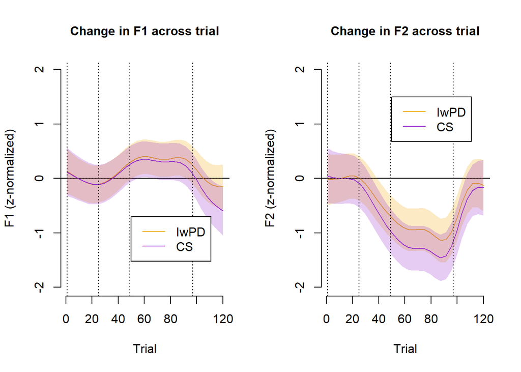

```r
legend(50, 1.5, legend=c("IwPD", "CS"), col = c("darkgoldenrod2", "darkorchid3"), lty=1:1, cex=1)
```

```r
# Figure 3 (manuscript)

par(mfrow=c(1,2))
plot_smooth(m1_adaptive, view="trial", cond=list(measure="TTz", isPDf1=0, isPDf2=0, isPDttz=1, isPDttx=0, isPDjawx=0, isPDjawz=0), rug=F, col="darkgoldenrod2", main="Change in TTy across trial", ylab="TTy (z-normalized)", xlab="Trial", hide.label = T, ylim=c(-2, 2), cex.axis=1, cex.lab=1, cex.main=1)
```

```
## Summary:
##  * measure : factor; set to the value(s): TTz.
##  * trial : numeric predictor; with 30 values ranging from 1.000000 to 120.000000.
##  * isPDf1 : numeric predictor; set to the value(s): 0.
##  * isPDf2 : numeric predictor; set to the value(s): 0.
##  * isPDttz : numeric predictor; set to the value(s): 1.
##  * isPDttx : numeric predictor; set to the value(s): 0.
##  * isPDjawx : numeric predictor; set to the value(s): 0.
##  * isPDjawz : numeric predictor; set to the value(s): 0.
##  * participant : factor; set to the value(s): TRCS02. (Might be canceled as random effect, check below.)
##  * targetWord : factor; set to the value(s): wet. (Might be canceled as random effect, check below.)
##  * NOTE : The following random effects columns are canceled: s(trial,participant):measureF1,s(trial,participant):measureF2,s(trial,participant):measureLIx,s(trial,participant):measureLIz,s(trial,participant):measureTTx,s(trial,participant):measureTTz,s(trial,targetWord):measureF1,s(trial,targetWo…
##
```

```r
plot_smooth(m1_adaptive, view="trial", cond=list(measure="TTz", isPDf1=0, isPDf2=0, isPDttz=0, isPDttx=0, isPDjawx=0, isPDjawz=0 ), rug=F, col="darkorchid3", add=T)
```

```
## Summary:
##  * measure : factor; set to the value(s): TTz.
##  * trial : numeric predictor; with 30 values ranging from 1.000000 to 120.000000.
##  * isPDf1 : numeric predictor; set to the value(s): 0.
##  * isPDf2 : numeric predictor; set to the value(s): 0.
##  * isPDttz : numeric predictor; set to the value(s): 0.
##  * isPDttx : numeric predictor; set to the value(s): 0.
##  * isPDjawx : numeric predictor; set to the value(s): 0.
##  * isPDjawz : numeric predictor; set to the value(s): 0.
##  * participant : factor; set to the value(s): TRCS02. (Might be canceled as random effect, check below.)
##  * targetWord : factor; set to the value(s): wet. (Might be canceled as random effect, check below.)
##  * NOTE : The following random effects columns are canceled: s(trial,participant):measureF1,s(trial,participant):measureF2,s(trial,participant):measureLIx,s(trial,participant):measureLIz,s(trial,participant):measureTTx,s(trial,participant):measureTTz,s(trial,targetWord):measureF1,s(trial,targetWo…
##
```

```r
par(abline(h=0, v=c(1, 25,49,97), lty=3))
```

```
## named list()
```

```r
legend(52, -0.8, legend=c("IwPD", "CS"), col = c("darkgoldenrod2", "darkorchid3"), lty=1:1, cex=1)

plot_smooth(m1_adaptive_tb, view="trial", cond=list(measure="TBz", isPDf1=0, isPDf2=0, isPDttz=0, isPDttx=0, isPDjawx=0, isPDjawz=0, isPDtbx=0, isPDtbz=1), rug=F, col="darkgoldenrod2", main="Change in TBy across trial", hide.label = T, ylim=c(-2, 2), cex.axis=1, cex.lab=1, cex.main=1, ylab="TBy (z-normalized)", xlab="Trial")
```

```
## Summary:
##  * measure : factor; set to the value(s): TBz.
##  * trial : numeric predictor; with 30 values ranging from 1.000000 to 120.000000.
##  * isPDf1 : numeric predictor; set to the value(s): 0.
##  * isPDf2 : numeric predictor; set to the value(s): 0.
##  * isPDttz : numeric predictor; set to the value(s): 0.
##  * isPDttx : numeric predictor; set to the value(s): 0.
##  * isPDtbz : numeric predictor; set to the value(s): 1.
##  * isPDtbx : numeric predictor; set to the value(s): 0.
##  * isPDjawx : numeric predictor; set to the value(s): 0.
##  * isPDjawz : numeric predictor; set to the value(s): 0.
##  * participant : factor; set to the value(s): TRCS03. (Might be canceled as random effect, check below.)
##  * targetWord : factor; set to the value(s): wet. (Might be canceled as random effect, check below.)
##  * NOTE : The following random effects columns are canceled: s(trial,participant):measureF1,s(trial,participant):measureF2,s(trial,participant):measureLIx,s(trial,participant):measureLIz,s(trial,participant):measureTBx,s(trial,participant):measureTBz,s(trial,participant):measureTTx,s(trial,partic…
##
```

```r
plot_smooth(m1_adaptive_tb, view="trial", cond=list(measure="TBz",  isPDf1=0, isPDf2=0, isPDttz=0, isPDttx=0, isPDjawx=0, isPDjawz=0, isPDtbx=0, isPDtbz=0), rug=F, col="darkorchid3", add=T)
```

```
## Summary:
##  * measure : factor; set to the value(s): TBz.
##  * trial : numeric predictor; with 30 values ranging from 1.000000 to 120.000000.
##  * isPDf1 : numeric predictor; set to the value(s): 0.
##  * isPDf2 : numeric predictor; set to the value(s): 0.
##  * isPDttz : numeric predictor; set to the value(s): 0.
##  * isPDttx : numeric predictor; set to the value(s): 0.
##  * isPDtbz : numeric predictor; set to the value(s): 0.
##  * isPDtbx : numeric predictor; set to the value(s): 0.
##  * isPDjawx : numeric predictor; set to the value(s): 0.
##  * isPDjawz : numeric predictor; set to the value(s): 0.
##  * participant : factor; set to the value(s): TRCS03. (Might be canceled as random effect, check below.)
##  * targetWord : factor; set to the value(s): wet. (Might be canceled as random effect, check below.)
##  * NOTE : The following random effects columns are canceled: s(trial,participant):measureF1,s(trial,participant):measureF2,s(trial,participant):measureLIx,s(trial,participant):measureLIz,s(trial,participant):measureTBx,s(trial,participant):measureTBz,s(trial,participant):measureTTx,s(trial,partic…
##
```

```r
par(abline(h=0, v=c(1, 25,49,97), lty=3))
```

```
## named list()
```

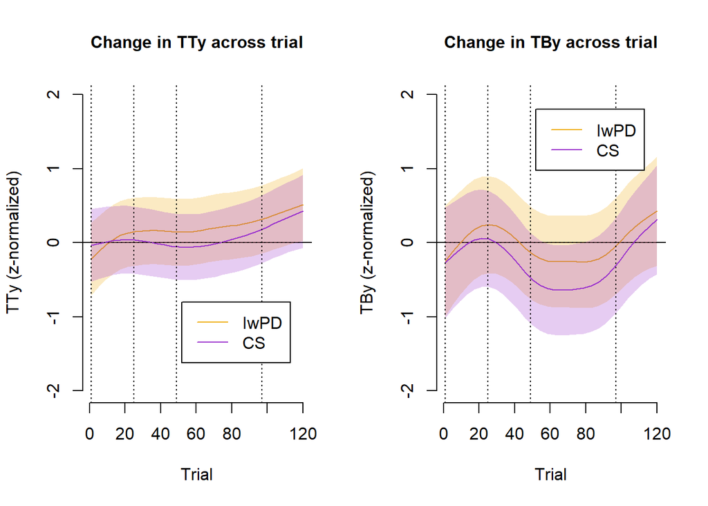

```r
legend(52, 1.8, legend=c("IwPD", "CS"), col = c("darkgoldenrod2", "darkorchid3"), lty=1:1, cex=1)
```

## 2.3 Overall effect of perturbation on the measures

The following two models assessed the effect of the adaptive formant perturbation on all measures, regardless of group

```r
# m0_adaptive <- bam(z.value ~ s(trial, by=measure) + measure +
#
#             s(trial, participant, by=measure, bs='fs',m=1) +
#
#             s(trial, targetWord, by=measure, bs='fs', m=1),
#
#           data=adaptive_noTB, family="scat", discrete=T, nthreads=12)

m0_adaptive <- readRDS("m0_adaptive.rds")
```

```r
# m0_adaptive_tb <- bam(z.value ~ s(trial, by=measure) + measure +
#
#             s(trial, participant, by=measure, bs='fs',m=1) +
#
#             s(trial, targetWord, by=measure, bs='fs', m=1),
#
#           data=TB_adaptive, family="scat", discrete=T, nthreads=12)

m0_adaptive_tb <- readRDS("m0_adaptive_tb.rds")
```

```r
summary(m0_adaptive, re.test=F)
```

```
##
## Family: Scaled t(5.268,0.682)
## Link function: identity
##
## Formula:
## z.value ~ s(trial, by = measure) + measure + s(trial, participant,
##     by = measure, bs = "fs", m = 1) + s(trial, targetWord, by = measure,
##     bs = "fs", m = 1)
##
## Parametric coefficients:
##              Estimate Std. Error t value Pr(>|t|)
## (Intercept)  0.093013   0.131614   0.707  0.47975
## measureF2   -0.646906   0.215847  -2.997  0.00273 **
## measureLIx  -0.004406   0.261382  -0.017  0.98655
## measureLIz   0.076438   0.237884   0.321  0.74797
## measureTTx  -0.250622   0.182230  -1.375  0.16904
## measureTTz   0.052643   0.271125   0.194  0.84605
## ---
## Signif. codes:  0 '***' 0.001 '**' 0.01 '*' 0.05 '.' 0.1 ' ' 1
##
## Approximate significance of smooth terms:
##                       edf Ref.df      F  p-value
## s(trial):measureF1  7.289  7.984 10.711  < 2e-16 ***
## s(trial):measureF2  8.531  8.808 32.724  < 2e-16 ***
## s(trial):measureLIx 5.393  6.187  3.596 0.001073 **
## s(trial):measureLIz 4.663  5.325  3.241 0.004784 **
## s(trial):measureTTx 3.829  4.354  5.200 0.000272 ***
## s(trial):measureTTz 4.908  5.681  5.066 4.37e-05 ***
## ---
## Signif. codes:  0 '***' 0.001 '**' 0.01 '*' 0.05 '.' 0.1 ' ' 1
##
## R-sq.(adj) =  0.469   Deviance explained = 42.2%
## fREML =  67587  Scale est. = 1         n = 40840
```

```r
summary(m0_adaptive_tb, re.test=F)
```

```
##
## Family: Scaled t(5.662,0.673)
## Link function: identity
##
## Formula:
## z.value ~ s(trial, by = measure) + measure + s(trial, participant,
##     by = measure, bs = "fs", m = 1) + s(trial, targetWord, by = measure,
##     bs = "fs", m = 1)
##
## Parametric coefficients:
##             Estimate Std. Error t value Pr(>|t|)
## (Intercept)  0.06808    0.16003   0.425  0.67056
## measureF2   -0.79585    0.27762  -2.867  0.00415 **
## measureLIx  -0.02723    0.28817  -0.094  0.92472
## measureLIz   0.04201    0.28008   0.150  0.88078
## measureTBx  -0.30842    0.22710  -1.358  0.17445
## measureTBz  -0.18555    0.31901  -0.582  0.56081
## measureTTx  -0.25712    0.20638  -1.246  0.21282
## measureTTz   0.01422    0.30584   0.046  0.96292
## ---
## Signif. codes:  0 '***' 0.001 '**' 0.01 '*' 0.05 '.' 0.1 ' ' 1
##
## Approximate significance of smooth terms:
##                       edf Ref.df      F p-value
## s(trial):measureF1  6.937  7.660  7.838 < 2e-16 ***
## s(trial):measureF2  8.301  8.674 21.806 < 2e-16 ***
## s(trial):measureLIx 4.556  5.258  1.670 0.10581
## s(trial):measureLIz 1.000  1.000  1.928 0.16492
## s(trial):measureTBx 2.713  2.979  2.081 0.11205
## s(trial):measureTBz 6.254  6.963  7.296 < 2e-16 ***
## s(trial):measureTTx 3.384  3.840  3.821 0.00658 **
## s(trial):measureTTz 4.891  5.599  2.834 0.00798 **
## ---
## Signif. codes:  0 '***' 0.001 '**' 0.01 '*' 0.05 '.' 0.1 ' ' 1
##
## R-sq.(adj) =  0.532   Deviance explained =   47%
## fREML =  44968  Scale est. = 1         n = 27188
```

```r
# model visualization (not featured in the manuscript)

par(mfrow=c(1,2))
plot_smooth(m0_adaptive, view="trial", cond=list(measure="F1"), rug=F, col="darkgoldenrod2", main="Change in F1 across trial", ylab="F1 (z-normalized)", xlab="Trial", hide.label = T, ylim=c(-2, 2), cex.axis=1, cex.lab=1, cex.main=1)
```

```
## Summary:
##  * measure : factor; set to the value(s): F1.
##  * trial : numeric predictor; with 30 values ranging from 1.000000 to 120.000000.
##  * participant : factor; set to the value(s): TRCS02. (Might be canceled as random effect, check below.)
##  * targetWord : factor; set to the value(s): wet. (Might be canceled as random effect, check below.)
##  * NOTE : The following random effects columns are canceled: s(trial,participant):measureF1,s(trial,participant):measureF2,s(trial,participant):measureLIx,s(trial,participant):measureLIz,s(trial,participant):measureTTx,s(trial,participant):measureTTz,s(trial,targetWord):measureF1,s(trial,targetWo…
##
```

```
## Summary:
##  * measure : factor; set to the value(s): F2.
##  * trial : numeric predictor; with 30 values ranging from 1.000000 to 120.000000.
##  * participant : factor; set to the value(s): TRCS02. (Might be canceled as random effect, check below.)
##  * targetWord : factor; set to the value(s): wet. (Might be canceled as random effect, check below.)
##  * NOTE : The following random effects columns are canceled: s(trial,participant):measureF1,s(trial,participant):measureF2,s(trial,participant):measureLIx,s(trial,participant):measureLIz,s(trial,participant):measureTTx,s(trial,participant):measureTTz,s(trial,targetWord):measureF1,s(trial,targetWo…
##
```

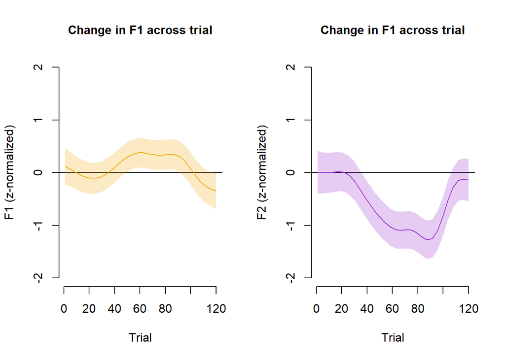

```r
plot_smooth(m0_adaptive, view="trial", cond=list(measure="F2"), rug=F, col="darkorchid3", main="Change in F1 across trial", ylab="F2 (z-normalized)", xlab="Trial", hide.label = T, ylim=c(-2, 2), cex.axis=1, cex.lab=1, cex.main=1)
```

```r
par(mfrow=c(1,2))
plot_smooth(m0_adaptive, view="trial", cond=list(measure="TTx"), rug=F, col="darkgoldenrod2", main="Change in TTx across trial", ylab="TTx (z-normalized)", xlab="Trial", hide.label = T, ylim=c(-1, 1), cex.axis=1, cex.lab=1, cex.main=1)
```

```
## Summary:
##  * measure : factor; set to the value(s): TTx.
##  * trial : numeric predictor; with 30 values ranging from 1.000000 to 120.000000.
##  * participant : factor; set to the value(s): TRCS02. (Might be canceled as random effect, check below.)
##  * targetWord : factor; set to the value(s): wet. (Might be canceled as random effect, check below.)
##  * NOTE : The following random effects columns are canceled: s(trial,participant):measureF1,s(trial,participant):measureF2,s(trial,participant):measureLIx,s(trial,participant):measureLIz,s(trial,participant):measureTTx,s(trial,participant):measureTTz,s(trial,targetWord):measureF1,s(trial,targetWo…
##
```

```
## Summary:
##  * measure : factor; set to the value(s): TTz.
##  * trial : numeric predictor; with 30 values ranging from 1.000000 to 120.000000.
##  * participant : factor; set to the value(s): TRCS02. (Might be canceled as random effect, check below.)
##  * targetWord : factor; set to the value(s): wet. (Might be canceled as random effect, check below.)
##  * NOTE : The following random effects columns are canceled: s(trial,participant):measureF1,s(trial,participant):measureF2,s(trial,participant):measureLIx,s(trial,participant):measureLIz,s(trial,participant):measureTTx,s(trial,participant):measureTTz,s(trial,targetWord):measureF1,s(trial,targetWo…
##
```

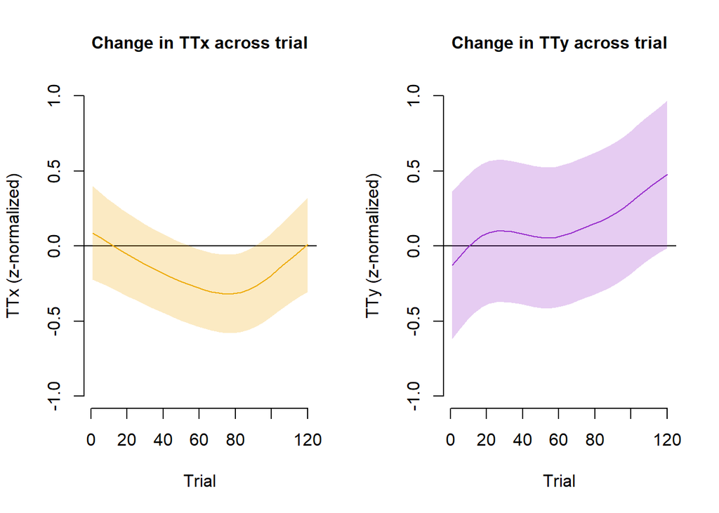

```r
plot_smooth(m0_adaptive, view="trial", cond=list(measure="TTz"), rug=F, col="darkorchid3", main="Change in TTy across trial", ylab="TTy (z-normalized)", xlab="Trial", hide.label = T, ylim=c(-1, 1), cex.axis=1, cex.lab=1, cex.main=1)
```

```r
par(mfrow=c(1,2))
plot_smooth(m0_adaptive_tb, view="trial", cond=list(measure="TBx"), rug=F, col="darkgoldenrod2", main="Change in TBx across trial", ylab="TBx (z-normalized)", xlab="Trial", hide.label = T, ylim=c(-1, 1), cex.axis=1, cex.lab=1, cex.main=1)
```

```
## Summary:
##  * measure : factor; set to the value(s): TBx.
##  * trial : numeric predictor; with 30 values ranging from 1.000000 to 120.000000.
##  * participant : factor; set to the value(s): TRCS03. (Might be canceled as random effect, check below.)
##  * targetWord : factor; set to the value(s): wet. (Might be canceled as random effect, check below.)
##  * NOTE : The following random effects columns are canceled: s(trial,participant):measureF1,s(trial,participant):measureF2,s(trial,participant):measureLIx,s(trial,participant):measureLIz,s(trial,participant):measureTBx,s(trial,participant):measureTBz,s(trial,participant):measureTTx,s(trial,partic…
##
```

```
## Summary:
##  * measure : factor; set to the value(s): TBz.
##  * trial : numeric predictor; with 30 values ranging from 1.000000 to 120.000000.
##  * participant : factor; set to the value(s): TRCS03. (Might be canceled as random effect, check below.)
##  * targetWord : factor; set to the value(s): wet. (Might be canceled as random effect, check below.)
##  * NOTE : The following random effects columns are canceled: s(trial,participant):measureF1,s(trial,participant):measureF2,s(trial,participant):measureLIx,s(trial,participant):measureLIz,s(trial,participant):measureTBx,s(trial,participant):measureTBz,s(trial,participant):measureTTx,s(trial,partic…
##
```

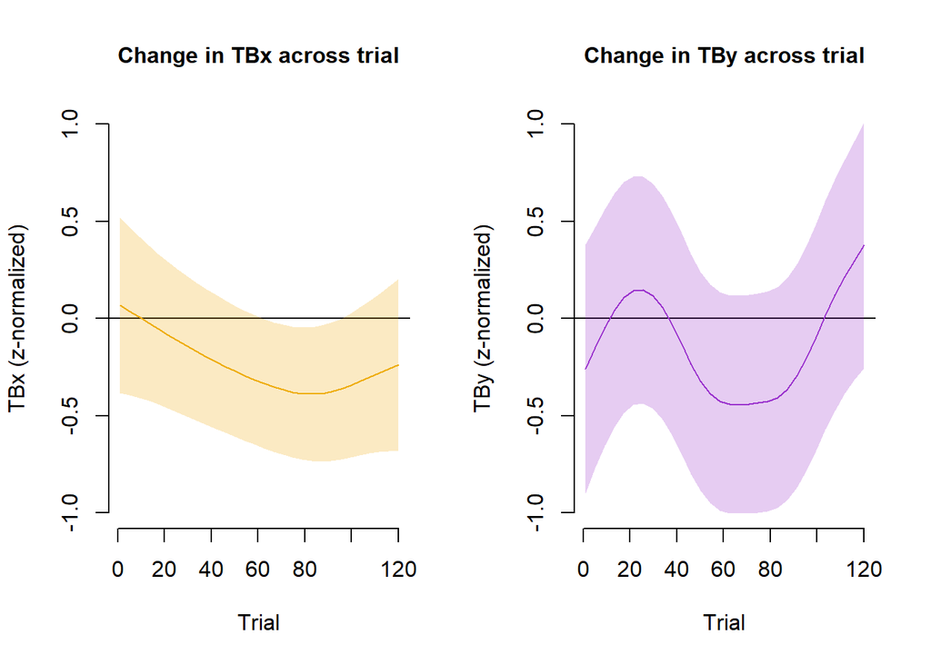

```r
plot_smooth(m0_adaptive_tb, view="trial", cond=list(measure="TBz"), rug=F, col="darkorchid3", main="Change in TBy across trial", ylab="TBy (z-normalized)", xlab="Trial", hide.label = T, ylim=c(-1, 1), cex.axis=1, cex.lab=1, cex.main=1)
```

```r
par(mfrow=c(1,2))
plot_smooth(m0_adaptive, view="trial", cond=list(measure="LIx"), rug=F, col="darkgoldenrod2", main="Change in JAWx across trial", ylab="JAWx (z-normalized)", xlab="Trial", hide.label = T, ylim=c(-1, 1), cex.axis=1, cex.lab=1, cex.main=1)
```

```
## Summary:
##  * measure : factor; set to the value(s): LIx.
##  * trial : numeric predictor; with 30 values ranging from 1.000000 to 120.000000.
##  * participant : factor; set to the value(s): TRCS02. (Might be canceled as random effect, check below.)
##  * targetWord : factor; set to the value(s): wet. (Might be canceled as random effect, check below.)
##  * NOTE : The following random effects columns are canceled: s(trial,participant):measureF1,s(trial,participant):measureF2,s(trial,participant):measureLIx,s(trial,participant):measureLIz,s(trial,participant):measureTTx,s(trial,participant):measureTTz,s(trial,targetWord):measureF1,s(trial,targetWo…
##
```

```
## Summary:
##  * measure : factor; set to the value(s): LIz.
##  * trial : numeric predictor; with 30 values ranging from 1.000000 to 120.000000.
##  * participant : factor; set to the value(s): TRCS02. (Might be canceled as random effect, check below.)
##  * targetWord : factor; set to the value(s): wet. (Might be canceled as random effect, check below.)
##  * NOTE : The following random effects columns are canceled: s(trial,participant):measureF1,s(trial,participant):measureF2,s(trial,participant):measureLIx,s(trial,participant):measureLIz,s(trial,participant):measureTTx,s(trial,participant):measureTTz,s(trial,targetWord):measureF1,s(trial,targetWo…
##
```

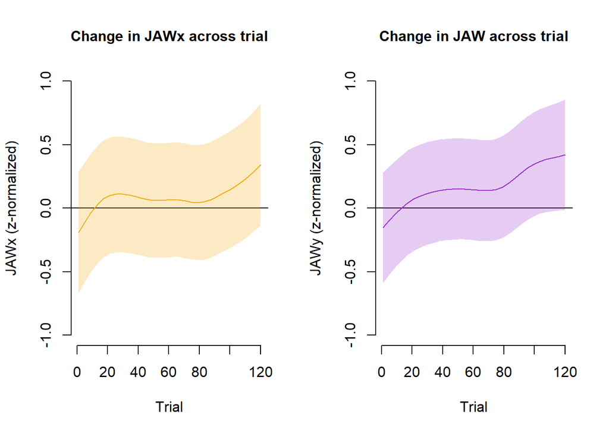

```r
plot_smooth(m0_adaptive, view="trial", cond=list(measure="LIz"), rug=F, col="darkorchid3", main="Change in JAW across trial", ylab="JAWy (z-normalized)", xlab="Trial", hide.label = T, ylim=c(-1, 1), cex.axis=1, cex.lab=1, cex.main=1)
```

## 2.4 Differences between male and female speakers

These two models assess the effect of sex on all variables (except TB: m2_adaptive, with TB: m2_adaptive_TB).

```r
# m2_adaptive <- bam(z.value ~ s(trial, by=MeasureSex) + MeasureSex +
#             s(trial, by=isPDf1F) + s(trial, by=isPDf1M) +
#             s(trial, by=isPDf2F) + s(trial, by=isPDf2M) +
#
#             s(trial, by=isPDttzF) + s(trial, by=isPDttzM) +
#             s(trial, by=isPDttxF) + s(trial, by=isPDttxM) +
#
#             s(trial, by=isPDjawzF) + s(trial, by=isPDjawzM) +
#             s(trial, by=isPDjawxF) + s(trial, by=isPDjawxM) +
#
#             s(trial, participant, by=measure, bs='fs',m=1) +
#             s(trial, targetWord, by=MeasureSex, bs='fs', m=1) +
#
#             s(trial, targetWord, by=isPDf1F, bs='fs', m=1) +
#             s(trial, targetWord, by=isPDf1M, bs='fs', m=1) +
#
#             s(trial, targetWord, by=isPDf2F, bs='fs', m=1) +
#             s(trial, targetWord, by=isPDf2M, bs='fs', m=1) +
#
#             s(trial, targetWord, by=isPDttzF, bs='fs', m=1) +
#             s(trial, targetWord, by=isPDttzM, bs='fs', m=1) +
#
#             s(trial, targetWord, by=isPDttxF, bs='fs', m=1) +
#             s(trial, targetWord, by=isPDttxM, bs='fs', m=1) +
#
#             s(trial, targetWord, by=isPDjawzF, bs='fs', m=1) +
#             s(trial, targetWord, by=isPDjawzM, bs='fs', m=1) +
#
#             s(trial, targetWord, by=isPDjawxF, bs='fs', m=1) +
#             s(trial, targetWord, by=isPDjawxM, bs='fs', m=1),
#
#             data=adaptive_noTB, family = "scat", discrete=T, nthreads=12)

m2_adaptive <- readRDS("m2_adaptive_sex.rds")
```

```r
# m2_adaptive_tb <- bam(z.value ~ s(trial, by=MeasureSex) + MeasureSex +
#             s(trial, by=isPDf1F) + s(trial, by=isPDf1M) +
#             s(trial, by=isPDf2F) + s(trial, by=isPDf2M) +
#
#             s(trial, by=isPDttzF) + s(trial, by=isPDttzM) +
#             s(trial, by=isPDttxF) + s(trial, by=isPDttxM) +
#
#             s(trial, by=isPDtbzF) + s(trial, by=isPDtbzM) +
#             s(trial, by=isPDtbxF) + s(trial, by=isPDtbxM) +
#
#             s(trial, by=isPDjawzF) + s(trial, by=isPDjawzM) +
#             s(trial, by=isPDjawxF) + s(trial, by=isPDjawxM) +
#
#             s(trial, participant, by=measure, bs='fs',m=1) +
#             s(trial, targetWord, by=MeasureSex, bs='fs', m=1) +
#
#             s(trial, targetWord, by=isPDf1F, bs='fs', m=1) +
#             s(trial, targetWord, by=isPDf1M, bs='fs', m=1) +
#
#             s(trial, targetWord, by=isPDf2F, bs='fs', m=1) +
#             s(trial, targetWord, by=isPDf2M, bs='fs', m=1) +
#
#             s(trial, targetWord, by=isPDttzF, bs='fs', m=1) +
#             s(trial, targetWord, by=isPDttzM, bs='fs', m=1) +
#
#             s(trial, targetWord, by=isPDttxF, bs='fs', m=1) +
#             s(trial, targetWord, by=isPDttxM, bs='fs', m=1) +
#
#             s(trial, targetWord, by=isPDtbzF, bs='fs', m=1) +
#             s(trial, targetWord, by=isPDtbzM, bs='fs', m=1) +
#
#             s(trial, targetWord, by=isPDtbxF, bs='fs', m=1) +
#             s(trial, targetWord, by=isPDtbxM, bs='fs', m=1) +
#
#             s(trial, targetWord, by=isPDjawzF, bs='fs', m=1) +
#             s(trial, targetWord, by=isPDjawzM, bs='fs', m=1) +
#
#             s(trial, targetWord, by=isPDjawxF, bs='fs', m=1) +
#             s(trial, targetWord, by=isPDjawxM, bs='fs', m=1),
#
#             data=TB_adaptive, family = "scat", discrete=T, nthreads=12)

m2_adaptive_tb <- readRDS("m2_adaptive_tb_sex.rds")
```

```r
summary(m2_adaptive, re.test=F)
```

```
##
## Family: Scaled t(5.278,0.673)
## Link function: identity
##
## Formula:
## z.value ~ s(trial, by = MeasureSex) + MeasureSex + s(trial, by = isPDf1F) +
##     s(trial, by = isPDf1M) + s(trial, by = isPDf2F) + s(trial,
##     by = isPDf2M) + s(trial, by = isPDttzF) + s(trial, by = isPDttzM) +
##     s(trial, by = isPDttxF) + s(trial, by = isPDttxM) + s(trial,
##     by = isPDjawzF) + s(trial, by = isPDjawzM) + s(trial, by = isPDjawxF) +
##     s(trial, by = isPDjawxM) + s(trial, participant, by = measure,
##     bs = "fs", m = 1) + s(trial, targetWord, by = MeasureSex,
##     bs = "fs", m = 1) + s(trial, targetWord, by = isPDf1F, bs = "fs",
##     m = 1) + s(trial, targetWord, by = isPDf1M, bs = "fs", m = 1) +
##     s(trial, targetWord, by = isPDf2F, bs = "fs", m = 1) + s(trial,
##     targetWord, by = isPDf2M, bs = "fs", m = 1) + s(trial, targetWord,
##     by = isPDttzF, bs = "fs", m = 1) + s(trial, targetWord, by = isPDttzM,
##     bs = "fs", m = 1) + s(trial, targetWord, by = isPDttxF, bs = "fs",
##     m = 1) + s(trial, targetWord, by = isPDttxM, bs = "fs", m = 1) +
##     s(trial, targetWord, by = isPDjawzF, bs = "fs", m = 1) +
##     s(trial, targetWord, by = isPDjawzM, bs = "fs", m = 1) +
##     s(trial, targetWord, by = isPDjawxF, bs = "fs", m = 1) +
##     s(trial, targetWord, by = isPDjawxM, bs = "fs", m = 1)
##
## Parametric coefficients:
##                 Estimate Std. Error t value Pr(>|t|)
## (Intercept)     -0.09329    0.18137  -0.514   0.6070
## MeasureSexF1_V   0.32813    0.27424   1.197   0.2315
## MeasureSexF2_M  -0.68533    0.30000  -2.284   0.0224 *
## MeasureSexF2_V  -0.44074    0.30625  -1.439   0.1501
## MeasureSexLIx_M  0.16307    0.30362   0.537   0.5912
## MeasureSexLIx_V  0.15657    0.30159   0.519   0.6037
## MeasureSexLIz_M  0.28540    0.30355   0.940   0.3471
## MeasureSexLIz_V  0.05147    0.30151   0.171   0.8645
## MeasureSexTTx_M -0.25118    0.26550  -0.946   0.3441
## MeasureSexTTx_V -0.05813    0.24987  -0.233   0.8160
## MeasureSexTTz_M  0.37053    0.31834   1.164   0.2444
## MeasureSexTTz_V -0.09486    0.28298  -0.335   0.7375
## ---
## Signif. codes:  0 '***' 0.001 '**' 0.01 '*' 0.05 '.' 0.1 ' ' 1
```

[output cut: 17 more lines]

```
## s(trial):isPDf2F         2.001  2.001  0.041  0.96046
## s(trial):isPDf2M         3.590  3.836  1.466  0.18286
## s(trial):isPDttzF        4.872  5.463  2.824  0.00925 **
## s(trial):isPDttzM        2.001  2.001  0.056  0.94606
## s(trial):isPDttxF        4.334  4.757  1.080  0.39306
## s(trial):isPDttxM        2.002  2.003  2.748  0.06406 .
## s(trial):isPDjawzF       2.001  2.001  0.859  0.42391
## s(trial):isPDjawzM       4.109  4.486  0.795  0.44272
## s(trial):isPDjawxF       2.335  2.411  0.186  0.79609
## s(trial):isPDjawxM       4.512  4.990  1.092  0.36367
## ---
## Signif. codes:  0 '***' 0.001 '**' 0.01 '*' 0.05 '.' 0.1 ' ' 1
##
## R-sq.(adj) =  0.482   Deviance explained = 43.3%
## fREML =  67845  Scale est. = 1         n = 40840
```

```r
summary(m2_adaptive_tb, re.test=F)
```

```
##
## Family: Scaled t(5.649,0.656)
## Link function: identity
##
## Formula:
## z.value ~ s(trial, by = MeasureSex) + MeasureSex + s(trial, by = isPDf1F) +
##     s(trial, by = isPDf1M) + s(trial, by = isPDf2F) + s(trial,
##     by = isPDf2M) + s(trial, by = isPDttzF) + s(trial, by = isPDttzM) +
##     s(trial, by = isPDttxF) + s(trial, by = isPDttxM) + s(trial,
##     by = isPDtbzF) + s(trial, by = isPDtbzM) + s(trial, by = isPDtbxF) +
##     s(trial, by = isPDtbxM) + s(trial, by = isPDjawzF) + s(trial,
##     by = isPDjawzM) + s(trial, by = isPDjawxF) + s(trial, by = isPDjawxM) +
##     s(trial, participant, by = measure, bs = "fs", m = 1) + s(trial,
##     targetWord, by = MeasureSex, bs = "fs", m = 1) + s(trial,
##     targetWord, by = isPDf1F, bs = "fs", m = 1) + s(trial, targetWord,
##     by = isPDf1M, bs = "fs", m = 1) + s(trial, targetWord, by = isPDf2F,
##     bs = "fs", m = 1) + s(trial, targetWord, by = isPDf2M, bs = "fs",
##     m = 1) + s(trial, targetWord, by = isPDttzF, bs = "fs", m = 1) +
##     s(trial, targetWord, by = isPDttzM, bs = "fs", m = 1) + s(trial,
##     targetWord, by = isPDttxF, bs = "fs", m = 1) + s(trial, targetWord,
##     by = isPDttxM, bs = "fs", m = 1) + s(trial, targetWord, by = isPDtbzF,
##     bs = "fs", m = 1) + s(trial, targetWord, by = isPDtbzM, bs = "fs",
##     m = 1) + s(trial, targetWord, by = isPDtbxF, bs = "fs", m = 1) +
##     s(trial, targetWord, by = isPDtbxM, bs = "fs", m = 1) + s(trial,
##     targetWord, by = isPDjawzF, bs = "fs", m = 1) + s(trial,
##     targetWord, by = isPDjawzM, bs = "fs", m = 1) + s(trial,
##     targetWord, by = isPDjawxF, bs = "fs", m = 1) + s(trial,
##     targetWord, by = isPDjawxM, bs = "fs", m = 1)
##
## Parametric coefficients:
##                  Estimate Std. Error t value Pr(>|t|)
## (Intercept)     -0.135238   0.223873  -0.604    0.546
## MeasureSexF1_V   0.528950   0.397964   1.329    0.184
## MeasureSexF2_M  -0.680141   0.401125  -1.696    0.090 .
## MeasureSexF2_V  -0.719188   0.456954  -1.574    0.116
## MeasureSexLIx_M  0.293219   0.373384   0.785    0.432
## MeasureSexLIx_V  0.002691   0.361870   0.007    0.994
## MeasureSexLIz_M  0.252868   0.371988   0.680    0.497
## MeasureSexLIz_V -0.134105   0.403335  -0.332    0.740
## MeasureSexTBx_M -0.123795   0.344367  -0.359    0.719
```

[output cut: 34 more lines]

```
## s(trial):isPDttxF        3.211  3.440  0.712 0.642744
## s(trial):isPDttxM        2.001  2.001  1.067 0.344102
## s(trial):isPDtbzF        4.412  4.776  2.263 0.048154 *
## s(trial):isPDtbzM        2.001  2.001  0.005 0.995117
## s(trial):isPDtbxF        4.961  5.436  1.981 0.061606 .
## s(trial):isPDtbxM        3.413  3.643  0.526 0.720011
## s(trial):isPDjawzF       2.002  2.002  0.760 0.467493
## s(trial):isPDjawzM       2.000  2.001  0.712 0.490480
## s(trial):isPDjawxF       3.732  4.084  1.089 0.354137
## s(trial):isPDjawxM       3.954  4.334  0.742 0.655464
## ---
## Signif. codes:  0 '***' 0.001 '**' 0.01 '*' 0.05 '.' 0.1 ' ' 1
##
## R-sq.(adj) =  0.551   Deviance explained = 48.7%
## fREML =  45302  Scale est. = 1         n = 27188
```

### 2.4.1 Visualization of the effect of sex

```r
# Figure 4 (manuscript): Effect of sex on F1

par(mfrow=c(1,2))

plot_smooth(m2_adaptive, view="trial", cond=list(MeasureSex="F1_V", isPDf1F=1, isPDf2F=0, isPDttzF=0, isPDttxF=0, isPDjawxF=0, isPDjawzF=0, isPDf1M=0, isPDf2M=0, isPDttzM=0, isPDttxM=0, isPDjawxM=0, measure="F1", isPDjawzM=0), main="F1 across trial (female speakers)", ylim=c(-2,2), rug=F, col="darkgoldenrod2", ylab="F1 (z-normalized)", xlab="Trial", hide.label=T)
```

```
## Summary:
##  * MeasureSex : factor; set to the value(s): F1_V.
##  * trial : numeric predictor; with 30 values ranging from 1.000000 to 120.000000.
##  * isPDf1F : numeric predictor; set to the value(s): 1.
##  * isPDf1M : numeric predictor; set to the value(s): 0.
##  * isPDf2F : numeric predictor; set to the value(s): 0.
##  * isPDf2M : numeric predictor; set to the value(s): 0.
##  * isPDttzF : numeric predictor; set to the value(s): 0.
##  * isPDttzM : numeric predictor; set to the value(s): 0.
##  * isPDttxF : numeric predictor; set to the value(s): 0.
##  * isPDttxM : numeric predictor; set to the value(s): 0.
##  * isPDjawzF : numeric predictor; set to the value(s): 0.
##  * isPDjawzM : numeric predictor; set to the value(s): 0.
##  * isPDjawxF : numeric predictor; set to the value(s): 0.
##  * isPDjawxM : numeric predictor; set to the value(s): 0.
##  * participant : factor; set to the value(s): TRCS02. (Might be canceled as random effect, check below.)
##  * measure : factor; set to the value(s): F1.
##  * targetWord : factor; set to the value(s): wet. (Might be canceled as random effect, check below.)
##  * NOTE : The following random effects columns are canceled: s(trial,participant):measureF1,s(trial,participant):measureF2,s(trial,participant):measureLIx,s(trial,participant):measureLIz,s(trial,participant):measureTTx,s(trial,participant):measureTTz,s(trial,targetWord):MeasureSexF1_M,s(trial,tar…
##
```

```r
plot_smooth(m2_adaptive, view="trial", cond=list(MeasureSex="F1_V", isPDf1F=0, isPDf2F=0, isPDttzF=0, isPDttxF=0, isPDjawxF=0, isPDjawzF=0, isPDf1M=0, isPDf2M=0, isPDttzM=0, isPDttxM=0, isPDjawxM=0, isPDjawzM=0, measure="F1"), rug=F, col="darkorchid3", add=T)
```

```
## Summary:
##  * MeasureSex : factor; set to the value(s): F1_V.
##  * trial : numeric predictor; with 30 values ranging from 1.000000 to 120.000000.
##  * isPDf1F : numeric predictor; set to the value(s): 0.
##  * isPDf1M : numeric predictor; set to the value(s): 0.
##  * isPDf2F : numeric predictor; set to the value(s): 0.
##  * isPDf2M : numeric predictor; set to the value(s): 0.
##  * isPDttzF : numeric predictor; set to the value(s): 0.
##  * isPDttzM : numeric predictor; set to the value(s): 0.
##  * isPDttxF : numeric predictor; set to the value(s): 0.
##  * isPDttxM : numeric predictor; set to the value(s): 0.
##  * isPDjawzF : numeric predictor; set to the value(s): 0.
##  * isPDjawzM : numeric predictor; set to the value(s): 0.
##  * isPDjawxF : numeric predictor; set to the value(s): 0.
##  * isPDjawxM : numeric predictor; set to the value(s): 0.
##  * participant : factor; set to the value(s): TRCS02. (Might be canceled as random effect, check below.)
##  * measure : factor; set to the value(s): F1.
##  * targetWord : factor; set to the value(s): wet. (Might be canceled as random effect, check below.)
##  * NOTE : The following random effects columns are canceled: s(trial,participant):measureF1,s(trial,participant):measureF2,s(trial,participant):measureLIx,s(trial,participant):measureLIz,s(trial,participant):measureTTx,s(trial,participant):measureTTz,s(trial,targetWord):MeasureSexF1_M,s(trial,tar…
##
```

```r
abline(h=0, v=c(1, 25,49,97), lty=3)
#abline(h=0, v=c(115, 120), lty=1)
xright <- 115
xleft <- 120
ybottom <- -2
ytop <- 2
polygon(x = c(xleft, xleft, xright, xright), y = c(ybottom, ytop, ytop, ybottom), col = rgb(0.6, 0.8, 1, 0.3), border = NA)
#abline(v = c(xleft, xright), lty = 2)
legend(52, -0.5, legend=c("IwPD", "CS"), col = c("darkgoldenrod2", "darkorchid3"), lty=1:1, cex=1)

plot_smooth(m2_adaptive, view="trial", cond=list(MeasureSex="F1_M", isPDf1F=0, isPDf2F=0, isPDttzF=0, isPDttxF=0, isPDjawxF=0, isPDjawzF=0, isPDf1M=1, isPDf2M=0, isPDttzM=0, isPDttxM=0, isPDjawxM=0, isPDjawzM=0, measure="F1"), main="F1 across trial (male speakers)", ylim=c(-2,2), rug=F, col="darkgoldenrod2", ylab="F1 (z-normalized)", xlab="Trial", hide.label=T)
```

```
## Summary:
##  * MeasureSex : factor; set to the value(s): F1_M.
##  * trial : numeric predictor; with 30 values ranging from 1.000000 to 120.000000.
##  * isPDf1F : numeric predictor; set to the value(s): 0.
##  * isPDf1M : numeric predictor; set to the value(s): 1.
##  * isPDf2F : numeric predictor; set to the value(s): 0.
##  * isPDf2M : numeric predictor; set to the value(s): 0.
##  * isPDttzF : numeric predictor; set to the value(s): 0.
##  * isPDttzM : numeric predictor; set to the value(s): 0.
##  * isPDttxF : numeric predictor; set to the value(s): 0.
##  * isPDttxM : numeric predictor; set to the value(s): 0.
##  * isPDjawzF : numeric predictor; set to the value(s): 0.
##  * isPDjawzM : numeric predictor; set to the value(s): 0.
##  * isPDjawxF : numeric predictor; set to the value(s): 0.
##  * isPDjawxM : numeric predictor; set to the value(s): 0.
##  * participant : factor; set to the value(s): TRCS02. (Might be canceled as random effect, check below.)
##  * measure : factor; set to the value(s): F1.
##  * targetWord : factor; set to the value(s): wet. (Might be canceled as random effect, check below.)
##  * NOTE : The following random effects columns are canceled: s(trial,participant):measureF1,s(trial,participant):measureF2,s(trial,participant):measureLIx,s(trial,participant):measureLIz,s(trial,participant):measureTTx,s(trial,participant):measureTTz,s(trial,targetWord):MeasureSexF1_M,s(trial,tar…
##
```

```r
plot_smooth(m2_adaptive, view="trial", cond=list(MeasureSex="F1_M", isPDf1F=0, isPDf2F=0, isPDttzF=0, isPDttxF=0, isPDjawxF=0, isPDjawzF=0, isPDf1M=0, isPDf2M=0, isPDttzM=0, isPDttxM=0, isPDjawxM=0, isPDjawzM=0, measure="F1"), rug=F, col="darkorchid3", add=T)
```

```
## Summary:
##  * MeasureSex : factor; set to the value(s): F1_M.
##  * trial : numeric predictor; with 30 values ranging from 1.000000 to 120.000000.
##  * isPDf1F : numeric predictor; set to the value(s): 0.
##  * isPDf1M : numeric predictor; set to the value(s): 0.
##  * isPDf2F : numeric predictor; set to the value(s): 0.
##  * isPDf2M : numeric predictor; set to the value(s): 0.
##  * isPDttzF : numeric predictor; set to the value(s): 0.
##  * isPDttzM : numeric predictor; set to the value(s): 0.
##  * isPDttxF : numeric predictor; set to the value(s): 0.
##  * isPDttxM : numeric predictor; set to the value(s): 0.
##  * isPDjawzF : numeric predictor; set to the value(s): 0.
##  * isPDjawzM : numeric predictor; set to the value(s): 0.
##  * isPDjawxF : numeric predictor; set to the value(s): 0.
##  * isPDjawxM : numeric predictor; set to the value(s): 0.
##  * participant : factor; set to the value(s): TRCS02. (Might be canceled as random effect, check below.)
##  * measure : factor; set to the value(s): F1.
##  * targetWord : factor; set to the value(s): wet. (Might be canceled as random effect, check below.)
##  * NOTE : The following random effects columns are canceled: s(trial,participant):measureF1,s(trial,participant):measureF2,s(trial,participant):measureLIx,s(trial,participant):measureLIz,s(trial,participant):measureTTx,s(trial,participant):measureTTz,s(trial,targetWord):MeasureSexF1_M,s(trial,tar…
##
```

```r
par(abline(h=0, v=c(1, 25,49,97), lty=3))
```

```
## named list()
```

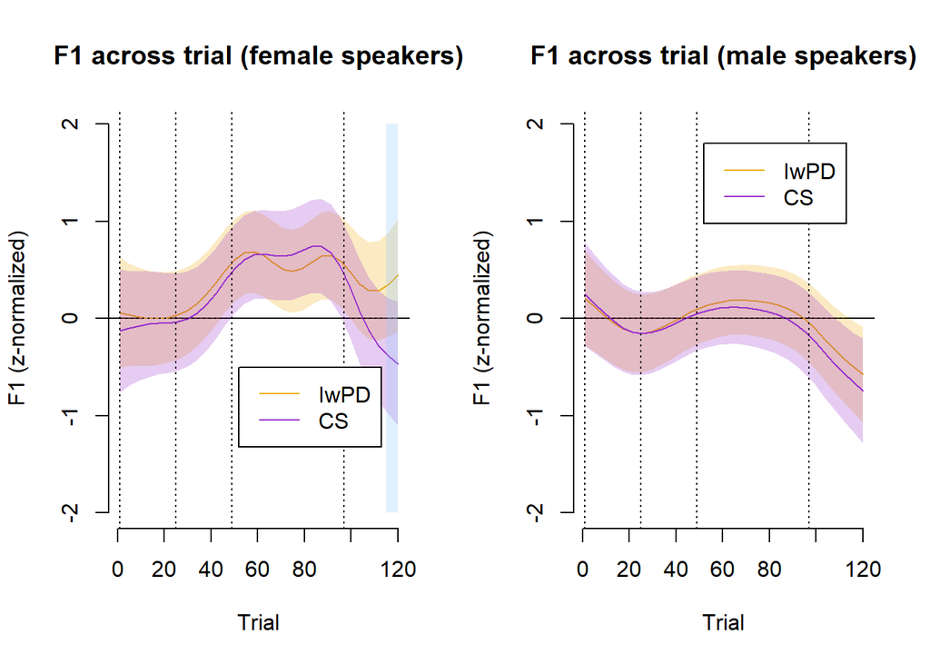

```r
legend(52, 1.8, legend=c("IwPD", "CS"), col = c("darkgoldenrod2", "darkorchid3"), lty=1:1, cex=1)
```

```r
# Figure 5 (manuscript): Effect of sex on F2

par(mfrow=c(1,2))

plot_smooth(m2_adaptive, view="trial", cond=list(MeasureSex="F2_V", isPDf1F=0, isPDf2F=1, isPDttzF=0, isPDttxF=0, isPDjawxF=0, isPDjawzF=0, isPDf1M=0, isPDf2M=0, isPDttzM=0, isPDttxM=0, isPDjawxM=0, isPDjawzM=0, measure="F2"), main="F2 across trial (female speakers)", ylim=c(-2,2), rug=F, col="darkgoldenrod2", ylab="F2 (z-normalized)", xlab="Trial", hide.label=T)
```

```
## Summary:
##  * MeasureSex : factor; set to the value(s): F2_V.
##  * trial : numeric predictor; with 30 values ranging from 1.000000 to 120.000000.
##  * isPDf1F : numeric predictor; set to the value(s): 0.
##  * isPDf1M : numeric predictor; set to the value(s): 0.
##  * isPDf2F : numeric predictor; set to the value(s): 1.
##  * isPDf2M : numeric predictor; set to the value(s): 0.
##  * isPDttzF : numeric predictor; set to the value(s): 0.
##  * isPDttzM : numeric predictor; set to the value(s): 0.
##  * isPDttxF : numeric predictor; set to the value(s): 0.
##  * isPDttxM : numeric predictor; set to the value(s): 0.
##  * isPDjawzF : numeric predictor; set to the value(s): 0.
##  * isPDjawzM : numeric predictor; set to the value(s): 0.
##  * isPDjawxF : numeric predictor; set to the value(s): 0.
##  * isPDjawxM : numeric predictor; set to the value(s): 0.
##  * participant : factor; set to the value(s): TRCS02. (Might be canceled as random effect, check below.)
##  * measure : factor; set to the value(s): F2.
##  * targetWord : factor; set to the value(s): wet. (Might be canceled as random effect, check below.)
##  * NOTE : The following random effects columns are canceled: s(trial,participant):measureF1,s(trial,participant):measureF2,s(trial,participant):measureLIx,s(trial,participant):measureLIz,s(trial,participant):measureTTx,s(trial,participant):measureTTz,s(trial,targetWord):MeasureSexF1_M,s(trial,tar…
##
```

```r
plot_smooth(m2_adaptive, view="trial", cond=list(MeasureSex="F2_V", isPDf1F=0, isPDf2F=0, isPDttzF=0, isPDttxF=0, isPDjawxF=0, isPDjawzF=0, isPDf1M=0, isPDf2M=0, isPDttzM=0, isPDttxM=0, isPDjawxM=0, isPDjawzM=0, measure="F2"), rug=F, col="darkorchid3", add=T)
```

```
## Summary:
##  * MeasureSex : factor; set to the value(s): F2_V.
##  * trial : numeric predictor; with 30 values ranging from 1.000000 to 120.000000.
##  * isPDf1F : numeric predictor; set to the value(s): 0.
##  * isPDf1M : numeric predictor; set to the value(s): 0.
##  * isPDf2F : numeric predictor; set to the value(s): 0.
##  * isPDf2M : numeric predictor; set to the value(s): 0.
##  * isPDttzF : numeric predictor; set to the value(s): 0.
##  * isPDttzM : numeric predictor; set to the value(s): 0.
##  * isPDttxF : numeric predictor; set to the value(s): 0.
##  * isPDttxM : numeric predictor; set to the value(s): 0.
##  * isPDjawzF : numeric predictor; set to the value(s): 0.
##  * isPDjawzM : numeric predictor; set to the value(s): 0.
##  * isPDjawxF : numeric predictor; set to the value(s): 0.
##  * isPDjawxM : numeric predictor; set to the value(s): 0.
##  * participant : factor; set to the value(s): TRCS02. (Might be canceled as random effect, check below.)
##  * measure : factor; set to the value(s): F2.
##  * targetWord : factor; set to the value(s): wet. (Might be canceled as random effect, check below.)
##  * NOTE : The following random effects columns are canceled: s(trial,participant):measureF1,s(trial,participant):measureF2,s(trial,participant):measureLIx,s(trial,participant):measureLIz,s(trial,participant):measureTTx,s(trial,participant):measureTTz,s(trial,targetWord):MeasureSexF1_M,s(trial,tar…
##
```

```r
abline(h=0, v=c(1, 25,49,97), lty=3)
legend(52, 1.3, legend=c("IwPD", "CS"), col = c("darkgoldenrod2", "darkorchid3"), lty=1:1, cex=1)

plot_smooth(m2_adaptive, view="trial", cond=list(MeasureSex="F2_M", isPDf1F=0, isPDf2F=0, isPDttzF=0, isPDttxF=0, isPDjawxF=0, isPDjawzF=0, isPDf1M=0, isPDf2M=1, isPDttzM=0, isPDttxM=0, isPDjawxM=0, isPDjawzM=0, measure="F2"), main="F2 across trial (male speakers)", ylim=c(-2,2), rug=F, col="darkgoldenrod2", ylab="F2 (z-normalized)", xlab="Trial", hide.label=T)
```

```
## Summary:
##  * MeasureSex : factor; set to the value(s): F2_M.
##  * trial : numeric predictor; with 30 values ranging from 1.000000 to 120.000000.
##  * isPDf1F : numeric predictor; set to the value(s): 0.
##  * isPDf1M : numeric predictor; set to the value(s): 0.
##  * isPDf2F : numeric predictor; set to the value(s): 0.
##  * isPDf2M : numeric predictor; set to the value(s): 1.
##  * isPDttzF : numeric predictor; set to the value(s): 0.
##  * isPDttzM : numeric predictor; set to the value(s): 0.
##  * isPDttxF : numeric predictor; set to the value(s): 0.
##  * isPDttxM : numeric predictor; set to the value(s): 0.
##  * isPDjawzF : numeric predictor; set to the value(s): 0.
##  * isPDjawzM : numeric predictor; set to the value(s): 0.
##  * isPDjawxF : numeric predictor; set to the value(s): 0.
##  * isPDjawxM : numeric predictor; set to the value(s): 0.
##  * participant : factor; set to the value(s): TRCS02. (Might be canceled as random effect, check below.)
##  * measure : factor; set to the value(s): F2.
##  * targetWord : factor; set to the value(s): wet. (Might be canceled as random effect, check below.)
##  * NOTE : The following random effects columns are canceled: s(trial,participant):measureF1,s(trial,participant):measureF2,s(trial,participant):measureLIx,s(trial,participant):measureLIz,s(trial,participant):measureTTx,s(trial,participant):measureTTz,s(trial,targetWord):MeasureSexF1_M,s(trial,tar…
##
```

```r
plot_smooth(m2_adaptive, view="trial", cond=list(MeasureSex="F2_M", isPDf1F=0, isPDf2F=0, isPDttzF=0, isPDttxF=0, isPDjawxF=0, isPDjawzF=0, isPDf1M=0, isPDf2M=0, isPDttzM=0, isPDttxM=0, isPDjawxM=0, isPDjawzM=0, measure="F2"), rug=F, col="darkorchid3", add=T)
```

```
## Summary:
##  * MeasureSex : factor; set to the value(s): F2_M.
##  * trial : numeric predictor; with 30 values ranging from 1.000000 to 120.000000.
##  * isPDf1F : numeric predictor; set to the value(s): 0.
##  * isPDf1M : numeric predictor; set to the value(s): 0.
##  * isPDf2F : numeric predictor; set to the value(s): 0.
##  * isPDf2M : numeric predictor; set to the value(s): 0.
##  * isPDttzF : numeric predictor; set to the value(s): 0.
##  * isPDttzM : numeric predictor; set to the value(s): 0.
##  * isPDttxF : numeric predictor; set to the value(s): 0.
##  * isPDttxM : numeric predictor; set to the value(s): 0.
##  * isPDjawzF : numeric predictor; set to the value(s): 0.
##  * isPDjawzM : numeric predictor; set to the value(s): 0.
##  * isPDjawxF : numeric predictor; set to the value(s): 0.
##  * isPDjawxM : numeric predictor; set to the value(s): 0.
##  * participant : factor; set to the value(s): TRCS02. (Might be canceled as random effect, check below.)
##  * measure : factor; set to the value(s): F2.
##  * targetWord : factor; set to the value(s): wet. (Might be canceled as random effect, check below.)
##  * NOTE : The following random effects columns are canceled: s(trial,participant):measureF1,s(trial,participant):measureF2,s(trial,participant):measureLIx,s(trial,participant):measureLIz,s(trial,participant):measureTTx,s(trial,participant):measureTTz,s(trial,targetWord):MeasureSexF1_M,s(trial,tar…
##
```

```r
par(abline(h=0, v=c(1, 25,49,97), lty=3))
```

```
## named list()
```

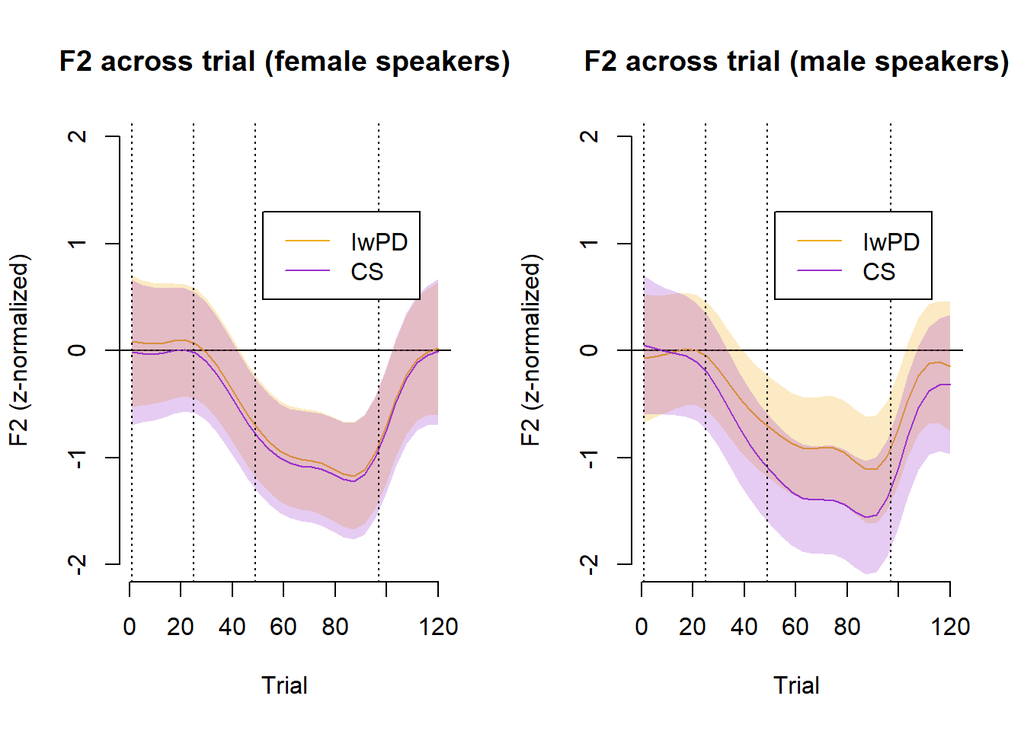

```r
legend(52, 1.3, legend=c("IwPD", "CS"), col = c("darkgoldenrod2", "darkorchid3"), lty=1:1, cex=1)
```

```r
# Figure 6 (manuscript): Effect of sex on TTy

par(mfrow=c(1,2))

plot_smooth(m2_adaptive, view="trial", cond=list(MeasureSex="TTz_V", isPDf1F=0, isPDf2F=0, isPDttzF=1, isPDttxF=0, isPDjawxF=0, isPDjawzF=0, isPDf1M=0, isPDf2M=0, isPDttzM=0, isPDttxM=0, isPDjawxM=0, isPDjawzM=0, measure="TTz"), main="TTy across trial (female speakers)", ylim=c(-2,2), rug=F, col="darkgoldenrod2", ylab="TTy (z-normalized)", xlab="Trial", hide.label=T)
```

```
## Summary:
##  * MeasureSex : factor; set to the value(s): TTz_V.
##  * trial : numeric predictor; with 30 values ranging from 1.000000 to 120.000000.
##  * isPDf1F : numeric predictor; set to the value(s): 0.
##  * isPDf1M : numeric predictor; set to the value(s): 0.
##  * isPDf2F : numeric predictor; set to the value(s): 0.
##  * isPDf2M : numeric predictor; set to the value(s): 0.
##  * isPDttzF : numeric predictor; set to the value(s): 1.
##  * isPDttzM : numeric predictor; set to the value(s): 0.
##  * isPDttxF : numeric predictor; set to the value(s): 0.
##  * isPDttxM : numeric predictor; set to the value(s): 0.
##  * isPDjawzF : numeric predictor; set to the value(s): 0.
##  * isPDjawzM : numeric predictor; set to the value(s): 0.
##  * isPDjawxF : numeric predictor; set to the value(s): 0.
##  * isPDjawxM : numeric predictor; set to the value(s): 0.
##  * participant : factor; set to the value(s): TRCS02. (Might be canceled as random effect, check below.)
##  * measure : factor; set to the value(s): TTz.
##  * targetWord : factor; set to the value(s): wet. (Might be canceled as random effect, check below.)
##  * NOTE : The following random effects columns are canceled: s(trial,participant):measureF1,s(trial,participant):measureF2,s(trial,participant):measureLIx,s(trial,participant):measureLIz,s(trial,participant):measureTTx,s(trial,participant):measureTTz,s(trial,targetWord):MeasureSexF1_M,s(trial,tar…
##
```

```r
plot_smooth(m2_adaptive, view="trial", cond=list(MeasureSex="TTz_V", isPDf1F=0, isPDf2F=0, isPDttzF=0, isPDttxF=0, isPDjawxF=0, isPDjawzF=0, isPDf1M=0, isPDf2M=0, isPDttzM=0, isPDttxM=0, isPDjawxM=0, isPDjawzM=0, measure="TTz"), rug=F, col="darkorchid3", add=T)
```

```
## Summary:
##  * MeasureSex : factor; set to the value(s): TTz_V.
##  * trial : numeric predictor; with 30 values ranging from 1.000000 to 120.000000.
##  * isPDf1F : numeric predictor; set to the value(s): 0.
##  * isPDf1M : numeric predictor; set to the value(s): 0.
##  * isPDf2F : numeric predictor; set to the value(s): 0.
##  * isPDf2M : numeric predictor; set to the value(s): 0.
##  * isPDttzF : numeric predictor; set to the value(s): 0.
##  * isPDttzM : numeric predictor; set to the value(s): 0.
##  * isPDttxF : numeric predictor; set to the value(s): 0.
##  * isPDttxM : numeric predictor; set to the value(s): 0.
##  * isPDjawzF : numeric predictor; set to the value(s): 0.
##  * isPDjawzM : numeric predictor; set to the value(s): 0.
##  * isPDjawxF : numeric predictor; set to the value(s): 0.
##  * isPDjawxM : numeric predictor; set to the value(s): 0.
##  * participant : factor; set to the value(s): TRCS02. (Might be canceled as random effect, check below.)
##  * measure : factor; set to the value(s): TTz.
##  * targetWord : factor; set to the value(s): wet. (Might be canceled as random effect, check below.)
##  * NOTE : The following random effects columns are canceled: s(trial,participant):measureF1,s(trial,participant):measureF2,s(trial,participant):measureLIx,s(trial,participant):measureLIz,s(trial,participant):measureTTx,s(trial,participant):measureTTz,s(trial,targetWord):MeasureSexF1_M,s(trial,tar…
##
```

```r
abline(h=0, v=c(1, 25,49,97), lty=3)
#abline(h=0, v=c(115, 120), lty=1)
xright <- 39.5
xleft <- 87.5
ybottom <- -2
ytop <- 2
polygon(x = c(xleft, xleft, xright, xright), y = c(ybottom, ytop, ytop, ybottom), col = rgb(0.6, 0.8, 1, 0.3), border = NA)
#abline(v = c(xleft, xright), lty = 2)
legend(1, -0.8, legend=c("IwPD", "CS"), col = c("darkgoldenrod2", "darkorchid3"), lty=1:1, cex=1)

plot_smooth(m2_adaptive, view="trial", cond=list(MeasureSex="TTz_M", isPDf1F=0, isPDf2F=0, isPDttzF=0, isPDttxF=0, isPDjawxF=0, isPDjawzF=0, isPDf1M=0, isPDf2M=0, isPDttzM=1, isPDttxM=0, isPDjawxM=0, isPDjawzM=0, measure="TTz"), main="TTy across trial (male speakers)", ylim=c(-2,2), rug=F, col="darkgoldenrod2", ylab="TTy (z-normalized)", xlab="Trial", hide.label=T)
```

```
## Summary:
##  * MeasureSex : factor; set to the value(s): TTz_M.
##  * trial : numeric predictor; with 30 values ranging from 1.000000 to 120.000000.
##  * isPDf1F : numeric predictor; set to the value(s): 0.
##  * isPDf1M : numeric predictor; set to the value(s): 0.
##  * isPDf2F : numeric predictor; set to the value(s): 0.
##  * isPDf2M : numeric predictor; set to the value(s): 0.
##  * isPDttzF : numeric predictor; set to the value(s): 0.
##  * isPDttzM : numeric predictor; set to the value(s): 1.
##  * isPDttxF : numeric predictor; set to the value(s): 0.
##  * isPDttxM : numeric predictor; set to the value(s): 0.
##  * isPDjawzF : numeric predictor; set to the value(s): 0.
##  * isPDjawzM : numeric predictor; set to the value(s): 0.
##  * isPDjawxF : numeric predictor; set to the value(s): 0.
##  * isPDjawxM : numeric predictor; set to the value(s): 0.
##  * participant : factor; set to the value(s): TRCS02. (Might be canceled as random effect, check below.)
##  * measure : factor; set to the value(s): TTz.
##  * targetWord : factor; set to the value(s): wet. (Might be canceled as random effect, check below.)
##  * NOTE : The following random effects columns are canceled: s(trial,participant):measureF1,s(trial,participant):measureF2,s(trial,participant):measureLIx,s(trial,participant):measureLIz,s(trial,participant):measureTTx,s(trial,participant):measureTTz,s(trial,targetWord):MeasureSexF1_M,s(trial,tar…
##
```

```r
plot_smooth(m2_adaptive, view="trial", cond=list(MeasureSex="TTz_M", isPDf1F=0, isPDf2F=0, isPDttzF=0, isPDttxF=0, isPDjawxF=0, isPDjawzF=0, isPDf1M=0, isPDf2M=0, isPDttzM=0, isPDttxM=0, isPDjawxM=0, isPDjawzM=0, measure="TTz"), rug=F, col="darkorchid3", add=T)
```

```
## Summary:
##  * MeasureSex : factor; set to the value(s): TTz_M.
##  * trial : numeric predictor; with 30 values ranging from 1.000000 to 120.000000.
##  * isPDf1F : numeric predictor; set to the value(s): 0.
##  * isPDf1M : numeric predictor; set to the value(s): 0.
##  * isPDf2F : numeric predictor; set to the value(s): 0.
##  * isPDf2M : numeric predictor; set to the value(s): 0.
##  * isPDttzF : numeric predictor; set to the value(s): 0.
##  * isPDttzM : numeric predictor; set to the value(s): 0.
##  * isPDttxF : numeric predictor; set to the value(s): 0.
##  * isPDttxM : numeric predictor; set to the value(s): 0.
##  * isPDjawzF : numeric predictor; set to the value(s): 0.
##  * isPDjawzM : numeric predictor; set to the value(s): 0.
##  * isPDjawxF : numeric predictor; set to the value(s): 0.
##  * isPDjawxM : numeric predictor; set to the value(s): 0.
##  * participant : factor; set to the value(s): TRCS02. (Might be canceled as random effect, check below.)
##  * measure : factor; set to the value(s): TTz.
##  * targetWord : factor; set to the value(s): wet. (Might be canceled as random effect, check below.)
##  * NOTE : The following random effects columns are canceled: s(trial,participant):measureF1,s(trial,participant):measureF2,s(trial,participant):measureLIx,s(trial,participant):measureLIz,s(trial,participant):measureTTx,s(trial,participant):measureTTz,s(trial,targetWord):MeasureSexF1_M,s(trial,tar…
##
```

```r
par(abline(h=0, v=c(1, 25,49,97), lty=3))
```

```
## named list()
```

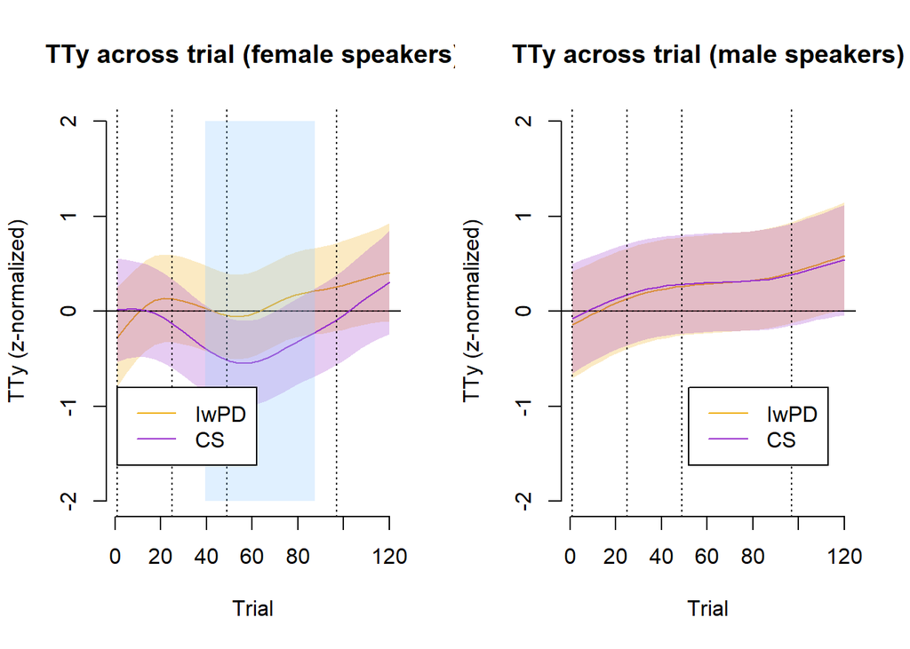

```r
legend(52, -0.8, legend=c("IwPD", "CS"), col = c("darkgoldenrod2", "darkorchid3"), lty=1:1, cex=1)
```

```r
# Figure 7 (manuscript): Effect of sex on TTx
par(mfrow=c(1,2))
plot_smooth(m2_adaptive, view="trial", cond=list(MeasureSex="TTx_V", isPDf1F=0, isPDf2F=0, isPDttzF=0, isPDttxF=1, isPDjawxF=0, isPDjawzF=0, isPDf1M=0, isPDf2M=0, isPDttzM=0, isPDttxM=0, isPDjawxM=0, isPDjawzM=0, measure="TTx"), main="TTx across trial (female speakers)", ylim=c(-2,2), rug=F, col="darkgoldenrod2", ylab="TTx (z-normalized)", xlab="Trial", hide.label=T)
```

```
## Summary:
##  * MeasureSex : factor; set to the value(s): TTx_V.
##  * trial : numeric predictor; with 30 values ranging from 1.000000 to 120.000000.
##  * isPDf1F : numeric predictor; set to the value(s): 0.
##  * isPDf1M : numeric predictor; set to the value(s): 0.
##  * isPDf2F : numeric predictor; set to the value(s): 0.
##  * isPDf2M : numeric predictor; set to the value(s): 0.
##  * isPDttzF : numeric predictor; set to the value(s): 0.
##  * isPDttzM : numeric predictor; set to the value(s): 0.
##  * isPDttxF : numeric predictor; set to the value(s): 1.
##  * isPDttxM : numeric predictor; set to the value(s): 0.
##  * isPDjawzF : numeric predictor; set to the value(s): 0.
##  * isPDjawzM : numeric predictor; set to the value(s): 0.
##  * isPDjawxF : numeric predictor; set to the value(s): 0.
##  * isPDjawxM : numeric predictor; set to the value(s): 0.
##  * participant : factor; set to the value(s): TRCS02. (Might be canceled as random effect, check below.)
##  * measure : factor; set to the value(s): TTx.
##  * targetWord : factor; set to the value(s): wet. (Might be canceled as random effect, check below.)
##  * NOTE : The following random effects columns are canceled: s(trial,participant):measureF1,s(trial,participant):measureF2,s(trial,participant):measureLIx,s(trial,participant):measureLIz,s(trial,participant):measureTTx,s(trial,participant):measureTTz,s(trial,targetWord):MeasureSexF1_M,s(trial,tar…
##
```

```r
plot_smooth(m2_adaptive, view="trial", cond=list(MeasureSex="TTx_V", isPDf1F=0, isPDf2F=0, isPDttzF=0, isPDttxF=0, isPDjawxF=0, isPDjawzF=0, isPDf1M=0, isPDf2M=0, isPDttzM=0, isPDttxM=0, isPDjawxM=0, isPDjawzM=0, measure="TTx"), rug=F, col="darkorchid3", add=T)
```

```
## Summary:
##  * MeasureSex : factor; set to the value(s): TTx_V.
##  * trial : numeric predictor; with 30 values ranging from 1.000000 to 120.000000.
##  * isPDf1F : numeric predictor; set to the value(s): 0.
##  * isPDf1M : numeric predictor; set to the value(s): 0.
##  * isPDf2F : numeric predictor; set to the value(s): 0.
##  * isPDf2M : numeric predictor; set to the value(s): 0.
##  * isPDttzF : numeric predictor; set to the value(s): 0.
##  * isPDttzM : numeric predictor; set to the value(s): 0.
##  * isPDttxF : numeric predictor; set to the value(s): 0.
##  * isPDttxM : numeric predictor; set to the value(s): 0.
##  * isPDjawzF : numeric predictor; set to the value(s): 0.
##  * isPDjawzM : numeric predictor; set to the value(s): 0.
##  * isPDjawxF : numeric predictor; set to the value(s): 0.
##  * isPDjawxM : numeric predictor; set to the value(s): 0.
##  * participant : factor; set to the value(s): TRCS02. (Might be canceled as random effect, check below.)
##  * measure : factor; set to the value(s): TTx.
##  * targetWord : factor; set to the value(s): wet. (Might be canceled as random effect, check below.)
##  * NOTE : The following random effects columns are canceled: s(trial,participant):measureF1,s(trial,participant):measureF2,s(trial,participant):measureLIx,s(trial,participant):measureLIz,s(trial,participant):measureTTx,s(trial,participant):measureTTz,s(trial,targetWord):MeasureSexF1_M,s(trial,tar…
##
```

```r
abline(h=0, v=c(1, 25,49,97), lty=3)
legend(52, 1.6, legend=c("IwPD", "CS"), col = c("darkgoldenrod2", "darkorchid3"), lty=1:1, cex=1)

plot_smooth(m2_adaptive, view="trial", cond=list(MeasureSex="TTx_M", isPDf1F=0, isPDf2F=0, isPDttzF=0, isPDttxF=0, isPDjawxF=0, isPDjawzF=0, isPDf1M=0, isPDf2M=0, isPDttzM=0, isPDttxM=1, isPDjawxM=0, isPDjawzM=0, measure="TTx"), main="TTx across trial (male speakers)", ylim=c(-2,2), rug=F, col="darkgoldenrod2", ylab="TTx (z-normalized)", xlab="Trial", hide.label=T)
```

```
## Summary:
##  * MeasureSex : factor; set to the value(s): TTx_M.
##  * trial : numeric predictor; with 30 values ranging from 1.000000 to 120.000000.
##  * isPDf1F : numeric predictor; set to the value(s): 0.
##  * isPDf1M : numeric predictor; set to the value(s): 0.
##  * isPDf2F : numeric predictor; set to the value(s): 0.
##  * isPDf2M : numeric predictor; set to the value(s): 0.
##  * isPDttzF : numeric predictor; set to the value(s): 0.
##  * isPDttzM : numeric predictor; set to the value(s): 0.
##  * isPDttxF : numeric predictor; set to the value(s): 0.
##  * isPDttxM : numeric predictor; set to the value(s): 1.
##  * isPDjawzF : numeric predictor; set to the value(s): 0.
##  * isPDjawzM : numeric predictor; set to the value(s): 0.
##  * isPDjawxF : numeric predictor; set to the value(s): 0.
##  * isPDjawxM : numeric predictor; set to the value(s): 0.
##  * participant : factor; set to the value(s): TRCS02. (Might be canceled as random effect, check below.)
##  * measure : factor; set to the value(s): TTx.
##  * targetWord : factor; set to the value(s): wet. (Might be canceled as random effect, check below.)
##  * NOTE : The following random effects columns are canceled: s(trial,participant):measureF1,s(trial,participant):measureF2,s(trial,participant):measureLIx,s(trial,participant):measureLIz,s(trial,participant):measureTTx,s(trial,participant):measureTTz,s(trial,targetWord):MeasureSexF1_M,s(trial,tar…
##
```

```r
plot_smooth(m2_adaptive, view="trial", cond=list(MeasureSex="TTx_M", isPDf1F=0, isPDf2F=0, isPDttzF=0, isPDttxF=0, isPDjawxF=0, isPDjawzF=0, isPDf1M=0, isPDf2M=0, isPDttzM=0, isPDttxM=0, isPDjawxM=0, isPDjawzM=0, measure="TTx"), rug=F, col="darkorchid3", add=T)
```

```
## Summary:
##  * MeasureSex : factor; set to the value(s): TTx_M.
##  * trial : numeric predictor; with 30 values ranging from 1.000000 to 120.000000.
##  * isPDf1F : numeric predictor; set to the value(s): 0.
##  * isPDf1M : numeric predictor; set to the value(s): 0.
##  * isPDf2F : numeric predictor; set to the value(s): 0.
##  * isPDf2M : numeric predictor; set to the value(s): 0.
##  * isPDttzF : numeric predictor; set to the value(s): 0.
##  * isPDttzM : numeric predictor; set to the value(s): 0.
##  * isPDttxF : numeric predictor; set to the value(s): 0.
##  * isPDttxM : numeric predictor; set to the value(s): 0.
##  * isPDjawzF : numeric predictor; set to the value(s): 0.
##  * isPDjawzM : numeric predictor; set to the value(s): 0.
##  * isPDjawxF : numeric predictor; set to the value(s): 0.
##  * isPDjawxM : numeric predictor; set to the value(s): 0.
##  * participant : factor; set to the value(s): TRCS02. (Might be canceled as random effect, check below.)
##  * measure : factor; set to the value(s): TTx.
##  * targetWord : factor; set to the value(s): wet. (Might be canceled as random effect, check below.)
##  * NOTE : The following random effects columns are canceled: s(trial,participant):measureF1,s(trial,participant):measureF2,s(trial,participant):measureLIx,s(trial,participant):measureLIz,s(trial,participant):measureTTx,s(trial,participant):measureTTz,s(trial,targetWord):MeasureSexF1_M,s(trial,tar…
##
```

```r
par(abline(h=0, v=c(1, 25,49,97), lty=3))
```

```
## named list()
```

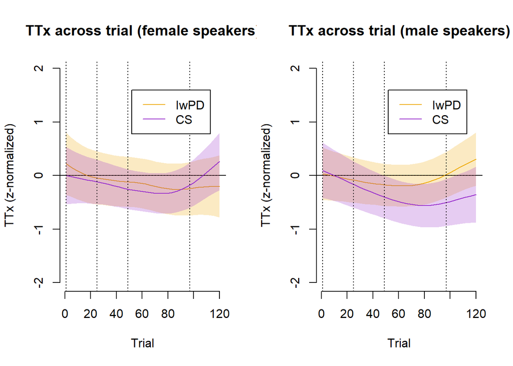

```r
legend(52, 1.6, legend=c("IwPD", "CS"), col = c("darkgoldenrod2", "darkorchid3"), lty=1:1, cex=1)
```

```r
# Figure 8 (manuscript): Effect of sex on TBy
par(mfrow=c(1,2))
plot_smooth(m2_adaptive_tb, view="trial", cond=list(MeasureSex="TBz_V", isPDf1F=0, isPDf2F=0, isPDttzF=0, isPDttxF=0, isPDjawxF=0, isPDjawzF=0, isPDf1M=0, isPDf2M=0, isPDttzM=0, isPDttxM=0, isPDjawxM=0, isPDjawzM=0, isPDtbzF=1, isPDtbzM=0, isPDtbxF=0, isPDtbxM=0, measure="TBz"), main="TBy across trial (female speakers)", ylim=c(-2,2), rug=F, col="darkgoldenrod2", ylab="TBy (z-normalized)", xlab="Trial", hide.label=T)
```

```
## Summary:
##  * MeasureSex : factor; set to the value(s): TBz_V.
##  * trial : numeric predictor; with 30 values ranging from 1.000000 to 120.000000.
##  * isPDf1F : numeric predictor; set to the value(s): 0.
##  * isPDf1M : numeric predictor; set to the value(s): 0.
##  * isPDf2F : numeric predictor; set to the value(s): 0.
##  * isPDf2M : numeric predictor; set to the value(s): 0.
##  * isPDttzF : numeric predictor; set to the value(s): 0.
##  * isPDttzM : numeric predictor; set to the value(s): 0.
##  * isPDttxF : numeric predictor; set to the value(s): 0.
##  * isPDttxM : numeric predictor; set to the value(s): 0.
##  * isPDtbzF : numeric predictor; set to the value(s): 1.
##  * isPDtbzM : numeric predictor; set to the value(s): 0.
##  * isPDtbxF : numeric predictor; set to the value(s): 0.
##  * isPDtbxM : numeric predictor; set to the value(s): 0.
##  * isPDjawzF : numeric predictor; set to the value(s): 0.
##  * isPDjawzM : numeric predictor; set to the value(s): 0.
##  * isPDjawxF : numeric predictor; set to the value(s): 0.
##  * isPDjawxM : numeric predictor; set to the value(s): 0.
##  * participant : factor; set to the value(s): TRCS03. (Might be canceled as random effect, check below.)
##  * measure : factor; set to the value(s): TBz.
##  * targetWord : factor; set to the value(s): wet. (Might be canceled as random effect, check below.)
##  * NOTE : The following random effects columns are canceled: s(trial,participant):measureF1,s(trial,participant):measureF2,s(trial,participant):measureLIx,s(trial,participant):measureLIz,s(trial,participant):measureTBx,s(trial,participant):measureTBz,s(trial,participant):measureTTx,s(trial,partic…
##
```

```r
plot_smooth(m2_adaptive_tb, view="trial", cond=list(MeasureSex="TBz_V", isPDf1F=0, isPDf2F=0, isPDttzF=0, isPDttxF=0, isPDjawxF=0, isPDjawzF=0, isPDf1M=0, isPDf2M=0, isPDttzM=0, isPDttxM=0, isPDjawxM=0, isPDjawzM=0, isPDtbzF=0, isPDtbzM=0, isPDtbxF=0, isPDtbxM=0, measure="TBz"), rug=F, col="darkorchid3", add=T)
```

```
## Summary:
##  * MeasureSex : factor; set to the value(s): TBz_V.
##  * trial : numeric predictor; with 30 values ranging from 1.000000 to 120.000000.
##  * isPDf1F : numeric predictor; set to the value(s): 0.
##  * isPDf1M : numeric predictor; set to the value(s): 0.
##  * isPDf2F : numeric predictor; set to the value(s): 0.
##  * isPDf2M : numeric predictor; set to the value(s): 0.
##  * isPDttzF : numeric predictor; set to the value(s): 0.
##  * isPDttzM : numeric predictor; set to the value(s): 0.
##  * isPDttxF : numeric predictor; set to the value(s): 0.
##  * isPDttxM : numeric predictor; set to the value(s): 0.
##  * isPDtbzF : numeric predictor; set to the value(s): 0.
##  * isPDtbzM : numeric predictor; set to the value(s): 0.
##  * isPDtbxF : numeric predictor; set to the value(s): 0.
##  * isPDtbxM : numeric predictor; set to the value(s): 0.
##  * isPDjawzF : numeric predictor; set to the value(s): 0.
##  * isPDjawzM : numeric predictor; set to the value(s): 0.
##  * isPDjawxF : numeric predictor; set to the value(s): 0.
##  * isPDjawxM : numeric predictor; set to the value(s): 0.
##  * participant : factor; set to the value(s): TRCS03. (Might be canceled as random effect, check below.)
##  * measure : factor; set to the value(s): TBz.
##  * targetWord : factor; set to the value(s): wet. (Might be canceled as random effect, check below.)
##  * NOTE : The following random effects columns are canceled: s(trial,participant):measureF1,s(trial,participant):measureF2,s(trial,participant):measureLIx,s(trial,participant):measureLIz,s(trial,participant):measureTBx,s(trial,participant):measureTBz,s(trial,participant):measureTTx,s(trial,partic…
##
```

```r
abline(h=0, v=c(1, 25,49,97), lty=3)
xright <- 45.5
xleft <- 83.9
ybottom <- -2
ytop <- 2
polygon(x = c(xleft, xleft, xright, xright), y = c(ybottom, ytop, ytop, ybottom), col = rgb(0.6, 0.8, 1, 0.3), border = NA)
legend(52, 1.6, legend=c("IwPD", "CS"), col = c("darkgoldenrod2", "darkorchid3"), lty=1:1, cex=1)

plot_smooth(m2_adaptive_tb, view="trial", cond=list(MeasureSex="TBz_M", isPDf1F=0, isPDf2F=0, isPDttzF=0, isPDttxF=0, isPDjawxF=0, isPDjawzF=0, isPDf1M=0, isPDf2M=0, isPDttzM=0, isPDttxM=0, isPDjawxM=0, isPDjawzM=0, isPDtbzF=0, isPDtbzM=1, isPDtbxF=0, isPDtbxM=0, measure="TBz"), main="TBy across trial (male speakers)", ylim=c(-2,2), rug=F, col="darkgoldenrod2", ylab="TBy (z-normalized)", xlab="Trial", hide.label=T)
```

```
## Summary:
##  * MeasureSex : factor; set to the value(s): TBz_M.
##  * trial : numeric predictor; with 30 values ranging from 1.000000 to 120.000000.
##  * isPDf1F : numeric predictor; set to the value(s): 0.
##  * isPDf1M : numeric predictor; set to the value(s): 0.
##  * isPDf2F : numeric predictor; set to the value(s): 0.
##  * isPDf2M : numeric predictor; set to the value(s): 0.
##  * isPDttzF : numeric predictor; set to the value(s): 0.
##  * isPDttzM : numeric predictor; set to the value(s): 0.
##  * isPDttxF : numeric predictor; set to the value(s): 0.
##  * isPDttxM : numeric predictor; set to the value(s): 0.
##  * isPDtbzF : numeric predictor; set to the value(s): 0.
##  * isPDtbzM : numeric predictor; set to the value(s): 1.
##  * isPDtbxF : numeric predictor; set to the value(s): 0.
##  * isPDtbxM : numeric predictor; set to the value(s): 0.
##  * isPDjawzF : numeric predictor; set to the value(s): 0.
##  * isPDjawzM : numeric predictor; set to the value(s): 0.
##  * isPDjawxF : numeric predictor; set to the value(s): 0.
##  * isPDjawxM : numeric predictor; set to the value(s): 0.
##  * participant : factor; set to the value(s): TRCS03. (Might be canceled as random effect, check below.)
##  * measure : factor; set to the value(s): TBz.
##  * targetWord : factor; set to the value(s): wet. (Might be canceled as random effect, check below.)
##  * NOTE : The following random effects columns are canceled: s(trial,participant):measureF1,s(trial,participant):measureF2,s(trial,participant):measureLIx,s(trial,participant):measureLIz,s(trial,participant):measureTBx,s(trial,participant):measureTBz,s(trial,participant):measureTTx,s(trial,partic…
##
```

```r
plot_smooth(m2_adaptive_tb, view="trial", cond=list(MeasureSex="TBz_M", isPDf1F=0, isPDf2F=0, isPDttzF=0, isPDttxF=0, isPDjawxF=0, isPDjawzF=0, isPDf1M=0, isPDf2M=0, isPDttzM=0, isPDttxM=0, isPDjawxM=0, isPDjawzM=0, isPDtbzF=0, isPDtbzM=0, isPDtbxF=0, isPDtbxM=0, measure="TBz"), rug=F, col="darkorchid3", add=T)
```

```
## Summary:
##  * MeasureSex : factor; set to the value(s): TBz_M.
##  * trial : numeric predictor; with 30 values ranging from 1.000000 to 120.000000.
##  * isPDf1F : numeric predictor; set to the value(s): 0.
##  * isPDf1M : numeric predictor; set to the value(s): 0.
##  * isPDf2F : numeric predictor; set to the value(s): 0.
##  * isPDf2M : numeric predictor; set to the value(s): 0.
##  * isPDttzF : numeric predictor; set to the value(s): 0.
##  * isPDttzM : numeric predictor; set to the value(s): 0.
##  * isPDttxF : numeric predictor; set to the value(s): 0.
##  * isPDttxM : numeric predictor; set to the value(s): 0.
##  * isPDtbzF : numeric predictor; set to the value(s): 0.
##  * isPDtbzM : numeric predictor; set to the value(s): 0.
##  * isPDtbxF : numeric predictor; set to the value(s): 0.
##  * isPDtbxM : numeric predictor; set to the value(s): 0.
##  * isPDjawzF : numeric predictor; set to the value(s): 0.
##  * isPDjawzM : numeric predictor; set to the value(s): 0.
##  * isPDjawxF : numeric predictor; set to the value(s): 0.
##  * isPDjawxM : numeric predictor; set to the value(s): 0.
##  * participant : factor; set to the value(s): TRCS03. (Might be canceled as random effect, check below.)
##  * measure : factor; set to the value(s): TBz.
##  * targetWord : factor; set to the value(s): wet. (Might be canceled as random effect, check below.)
##  * NOTE : The following random effects columns are canceled: s(trial,participant):measureF1,s(trial,participant):measureF2,s(trial,participant):measureLIx,s(trial,participant):measureLIz,s(trial,participant):measureTBx,s(trial,participant):measureTBz,s(trial,participant):measureTTx,s(trial,partic…
##
```

```r
par(abline(h=0, v=c(1, 25,49,97), lty=3))
```

```
## named list()
```

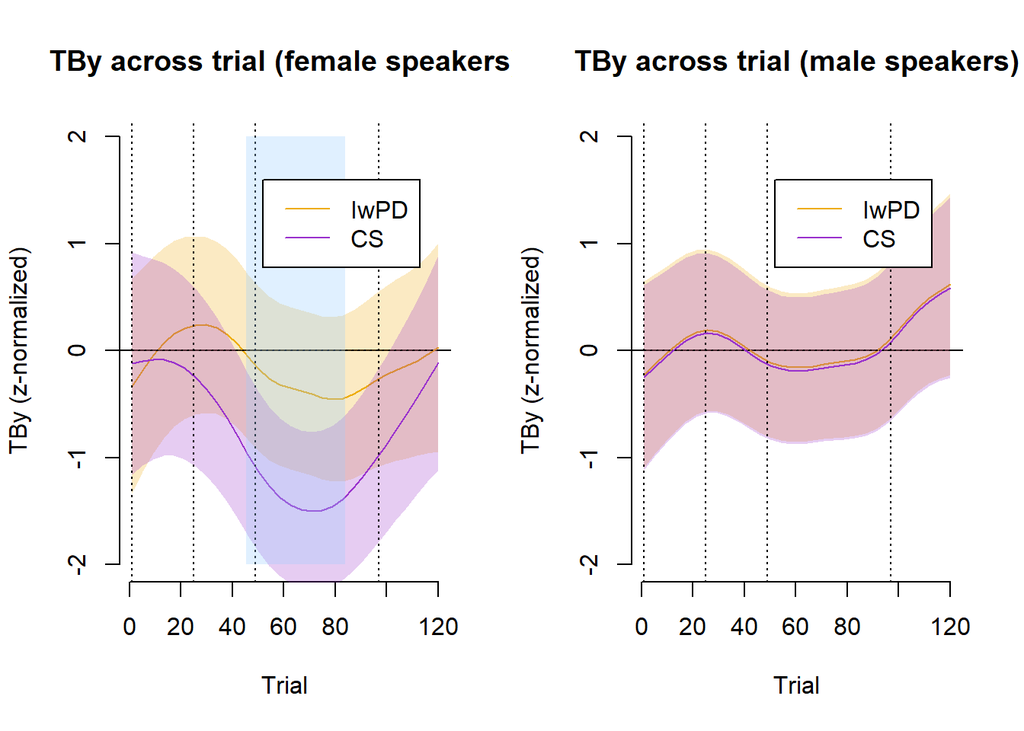

```r
legend(52, 1.6, legend=c("IwPD", "CS"), col = c("darkgoldenrod2", "darkorchid3"), lty=1:1, cex=1)
```

# 3 Reflexive responses to unexpected vowel formant perturbation

## 3.1 Data preparation

```r
dat <- read.csv("random_0606.csv", header=T)
head(dat)
```

```
##   participant measure targetWord time_vowel mean_trajectory sd_trajectory trial
## 1      TRCS02 f1_mean        DEK      0.000        562.2994       58.6786     1
## 2      TRCS02 f1_mean        DEK      0.005        562.2994       58.6786     1
## 3      TRCS02 f1_mean        DEK      0.010        562.2994       58.6786     1
## 4      TRCS02 f1_mean        DEK      0.015        562.2994       58.6786     1
## 5      TRCS02 f1_mean        DEK      0.020        562.2994       58.6786     1
## 6      TRCS02 f1_mean        DEK      0.025        562.2994       58.6786     1
##   text condition trial_type duration_vowel    value   z.value group  age sex
## 1  dek      down       down            405 409.5928 -2.602425    CS 70.7   V
## 2  dek      down       down            405 448.3318 -1.942235    CS 70.7   V
## 3  dek      down       down            405 470.0768 -1.571657    CS 70.7   V
## 4  dek      down       down            405 476.3648 -1.464497    CS 70.7   V
## 5  dek      down       down            405 485.8010 -1.303685    CS 70.7   V
## 6  dek      down       down            405 492.3008 -1.192916    CS 70.7   V
##   moca hearing_better hearing_worse year_dx mds_updrsIII subtype how_typical
## 1   27       moderate      moderate      NA           NA                75.9
## 2   27       moderate      moderate      NA           NA                75.9
## 3   27       moderate      moderate      NA           NA                75.9
## 4   27       moderate      moderate      NA           NA                75.9
## 5   27       moderate      moderate      NA           NA                75.9
## 6   27       moderate      moderate      NA           NA                75.9
##   sd_severity   ACUITY     BIAS average_500 average_2000
## 1    17.24407 2.462793 3.901973          30           55
## 2    17.24407 2.462793 3.901973          30           55
## 3    17.24407 2.462793 3.901973          30           55
## 4    17.24407 2.462793 3.901973          30           55
## 5    17.24407 2.462793 3.901973          30           55
## 6    17.24407 2.462793 3.901973          30           55
```

```r
cols <- c("participant", "condition", "measure", "targetWord", "group", "subtype", "sex")

dat[cols] <- lapply(dat[cols], factor)

str(dat)
```

```
## 'data.frame':    4718493 obs. of  28 variables:
##  $ participant    : Factor w/ 44 levels "TRCS02","TRCS03",..: 1 1 1 1 1 1 1 1 1 1 ...
##  $ measure        : Factor w/ 13 levels "f1_mean","f2_mean",..: 1 1 1 1 1 1 1 1 1 1 ...
##  $ targetWord     : Factor w/ 6 levels "BED","BEK","DEK",..: 3 3 3 3 3 3 3 3 3 3 ...
##  $ time_vowel     : num  0 0.005 0.01 0.015 0.02 0.025 0.03 0.035 0.04 0.045 ...
##  $ mean_trajectory: num  562 562 562 562 562 ...
##  $ sd_trajectory  : num  58.7 58.7 58.7 58.7 58.7 ...
##  $ trial          : int  1 1 1 1 1 1 1 1 1 1 ...
##  $ text           : chr  "dek" "dek" "dek" "dek" ...
##  $ condition      : Factor w/ 3 levels "ctrl","down",..: 2 2 2 2 2 2 2 2 2 2 ...
##  $ trial_type     : chr  "down" "down" "down" "down" ...
##  $ duration_vowel : num  405 405 405 405 405 ...
##  $ value          : num  410 448 470 476 486 ...
##  $ z.value        : num  -2.6 -1.94 -1.57 -1.46 -1.3 ...
##  $ group          : Factor w/ 2 levels "CS","PD": 1 1 1 1 1 1 1 1 1 1 ...
##  $ age            : num  70.7 70.7 70.7 70.7 70.7 70.7 70.7 70.7 70.7 70.7 ...
##  $ sex            : Factor w/ 2 levels "M","V": 2 2 2 2 2 2 2 2 2 2 ...
##  $ moca           : int  27 27 27 27 27 27 27 27 27 27 ...
##  $ hearing_better : chr  "moderate" "moderate" "moderate" "moderate" ...
##  $ hearing_worse  : chr  "moderate" "moderate" "moderate" "moderate" ...
##  $ year_dx        : int  NA NA NA NA NA NA NA NA NA NA ...
##  $ mds_updrsIII   : int  NA NA NA NA NA NA NA NA NA NA ...
##  $ subtype        : Factor w/ 4 levels "","indeterminate",..: 1 1 1 1 1 1 1 1 1 1 ...
##  $ how_typical    : num  75.9 75.9 75.9 75.9 75.9 75.9 75.9 75.9 75.9 75.9 ...
##  $ sd_severity    : num  17.2 17.2 17.2 17.2 17.2 ...
##  $ ACUITY         : num  2.46 2.46 2.46 2.46 2.46 ...
##  $ BIAS           : num  3.9 3.9 3.9 3.9 3.9 ...
##  $ average_500    : num  30 30 30 30 30 30 30 30 30 30 ...
##  $ average_2000   : num  55 55 55 55 55 55 55 55 55 55 ...
```

```r
dat_trials <- dat %>% select(participant, trial, condition) %>% unique()

table(dat_trials$participant, dat_trials$condition) #how many participants have each trial
```

```
##
##          ctrl down up
##   TRCS02   88   15 15
##   TRCS03   79   14 14
##   TRCS06   72   11 12
##   TRCS07   87   12 14
##   TRCS09   87   14 15
##   TRCS10   86   15 14
##   TRCS11   65   12  9
##   TRCS12   81   15 14
##   TRCS13   90   14 15
##   TRCS14   90   15 15
##   TRCS15   24    7  3
##   TRCS16   89   14 15
##   TRCS18   83   15 15
##   TRCS19   89   15 15
##   TRCS21   76   13 11
##   TRCS24   90   15 15
##   TRCS25   90   15 15
##   TRCS27   83   14 13
##   TRCS29   65   11 12
##   TRCS32   88   14 15
##   TRCS33   23    3  5
##   TRPD01   88   15 15
##   TRPD02   87   14 14
##   TRPD03   89   14 15
##   TRPD05   90   15 15
##   TRPD06   32    8  7
##   TRPD07   79   12 12
##   TRPD08   90   15 15
##   TRPD09   85   15 15
##   TRPD10   61   11 10
##   TRPD11   90   15 15
##   TRPD12   52    9  6
##   TRPD16   70   14 14
##   TRPD19   90   15 15
##   TRPD20   37   10  8
##   TRPD21   31    6  9
##   TRPD22   34    6  5
##   TRPD23   89   14 15
##   TRPD25   85   13 13
##   TRPD30   90   15 15
##   TRPD32   90   15 15
##   TRPD33   90   15 15
##   TRPD35   85   15 15
##   TRPD39   89   15 15
```

```r
table(dat$measure)
```

```
##
##      f1_mean      f2_mean      LA_mean TBx_sub_mean TBz_sub_mean TTx_sub_mean
##       362961       362961       362961       362961       362961       362961
## TTz_sub_mean    x_li_mean    x_tb_mean    x_tt_mean    z_li_mean    z_tb_mean
##       362961       362961       362961       362961       362961       362961
##    z_tt_mean
##       362961
```

```r
lvls_to_keep <- c("mean_f1", "mean_f2", "mean_jawx", "mean_jawz",
                  "mean_tbx", "mean_tbz", "mean_ttx", "mean_ttz")

dat <- dat %>%
  filter(! (measure == "TBz_sub_mean" | measure == "TBx_sub_mean" |
              measure == "TTz_sub_mean" | measure == "TTx_sub_mean" | measure == "LA_mean")) %>%
  droplevels()

table(dat$measure)
```

```
##
##   f1_mean   f2_mean x_li_mean x_tb_mean x_tt_mean z_li_mean z_tb_mean z_tt_mean
##    362961    362961    362961    362961    362961    362961    362961    362961
```

```r
dat <- dat %>%
  mutate(measure = recode_factor(measure,
                           f1_mean = "F1",
                           f2_mean = "F2",
                           x_li_mean = "LIx",
                           x_tb_mean = "TBx",
                           x_tt_mean = "TTx",
                           z_li_mean = "LIz",
                           z_tb_mean = "TBz",
                           z_tt_mean = "TTz"))

table(dat$measure)
```

```
##
##     F1     F2    LIx    TBx    TTx    LIz    TBz    TTz
## 362961 362961 362961 362961 362961 362961 362961 362961
```

```r
head(dat)
```

```
##   participant measure targetWord time_vowel mean_trajectory sd_trajectory trial
## 1      TRCS02      F1        DEK      0.000        562.2994       58.6786     1
## 2      TRCS02      F1        DEK      0.005        562.2994       58.6786     1
## 3      TRCS02      F1        DEK      0.010        562.2994       58.6786     1
## 4      TRCS02      F1        DEK      0.015        562.2994       58.6786     1
## 5      TRCS02      F1        DEK      0.020        562.2994       58.6786     1
## 6      TRCS02      F1        DEK      0.025        562.2994       58.6786     1
##   text condition trial_type duration_vowel    value   z.value group  age sex
## 1  dek      down       down            405 409.5928 -2.602425    CS 70.7   V
## 2  dek      down       down            405 448.3318 -1.942235    CS 70.7   V
## 3  dek      down       down            405 470.0768 -1.571657    CS 70.7   V
## 4  dek      down       down            405 476.3648 -1.464497    CS 70.7   V
## 5  dek      down       down            405 485.8010 -1.303685    CS 70.7   V
## 6  dek      down       down            405 492.3008 -1.192916    CS 70.7   V
##   moca hearing_better hearing_worse year_dx mds_updrsIII subtype how_typical
## 1   27       moderate      moderate      NA           NA                75.9
## 2   27       moderate      moderate      NA           NA                75.9
## 3   27       moderate      moderate      NA           NA                75.9
## 4   27       moderate      moderate      NA           NA                75.9
## 5   27       moderate      moderate      NA           NA                75.9
## 6   27       moderate      moderate      NA           NA                75.9
##   sd_severity   ACUITY     BIAS average_500 average_2000
## 1    17.24407 2.462793 3.901973          30           55
## 2    17.24407 2.462793 3.901973          30           55
## 3    17.24407 2.462793 3.901973          30           55
## 4    17.24407 2.462793 3.901973          30           55
## 5    17.24407 2.462793 3.901973          30           55
## 6    17.24407 2.462793 3.901973          30           55
```

```r
tail(dat)
```

```
##         participant measure targetWord time_vowel mean_trajectory sd_trajectory
## 2903683      TRPD39     LIz        DEK      0.375        -32.0681      1.151169
## 2903684      TRPD39     LIz        DEK      0.380        -32.0681      1.151169
## 2903685      TRPD39     LIz        DEK      0.385        -32.0681      1.151169
## 2903686      TRPD39     LIz        DEK      0.390        -32.0681      1.151169
## 2903687      TRPD39     LIz        DEK      0.395        -32.0681      1.151169
## 2903688      TRPD39     LIz        DEK      0.400        -32.0681      1.151169
##         trial text condition trial_type duration_vowel     value    z.value
## 2903683   120  dek      down       down            695 -32.55882 -0.4262785
## 2903684   120  dek      down       down            695 -32.54102 -0.4108124
## 2903685   120  dek      down       down            695 -32.52258 -0.3947963
## 2903686   120  dek      down       down            695 -32.50423 -0.3788563
## 2903687   120  dek      down       down            695 -32.48661 -0.3635468
## 2903688   120  dek      down       down            695 -32.47073 -0.3497584
##         group  age sex moca hearing_better hearing_worse year_dx mds_updrsIII
```

[output cut: 20 more lines]

```r
# create start_event (necessary to account for autocorrelation)

dat$start.event <- dat$time_vowel == min(dat$time_vowel)
head(dat)
```

```
##   participant measure targetWord time_vowel mean_trajectory sd_trajectory trial
## 1      TRCS02      F1        DEK      0.000        562.2994       58.6786     1
## 2      TRCS02      F1        DEK      0.005        562.2994       58.6786     1
## 3      TRCS02      F1        DEK      0.010        562.2994       58.6786     1
## 4      TRCS02      F1        DEK      0.015        562.2994       58.6786     1
## 5      TRCS02      F1        DEK      0.020        562.2994       58.6786     1
## 6      TRCS02      F1        DEK      0.025        562.2994       58.6786     1
##   text condition trial_type duration_vowel    value   z.value group  age sex
## 1  dek      down       down            405 409.5928 -2.602425    CS 70.7   V
## 2  dek      down       down            405 448.3318 -1.942235    CS 70.7   V
## 3  dek      down       down            405 470.0768 -1.571657    CS 70.7   V
## 4  dek      down       down            405 476.3648 -1.464497    CS 70.7   V
## 5  dek      down       down            405 485.8010 -1.303685    CS 70.7   V
## 6  dek      down       down            405 492.3008 -1.192916    CS 70.7   V
##   moca hearing_better hearing_worse year_dx mds_updrsIII subtype how_typical
## 1   27       moderate      moderate      NA           NA                75.9
## 2   27       moderate      moderate      NA           NA                75.9
## 3   27       moderate      moderate      NA           NA                75.9
## 4   27       moderate      moderate      NA           NA                75.9
## 5   27       moderate      moderate      NA           NA                75.9
## 6   27       moderate      moderate      NA           NA                75.9
##   sd_severity   ACUITY     BIAS average_500 average_2000 start.event
## 1    17.24407 2.462793 3.901973          30           55        TRUE
## 2    17.24407 2.462793 3.901973          30           55       FALSE
## 3    17.24407 2.462793 3.901973          30           55       FALSE
## 4    17.24407 2.462793 3.901973          30           55       FALSE
## 5    17.24407 2.462793 3.901973          30           55       FALSE
## 6    17.24407 2.462793 3.901973          30           55       FALSE
```

```r
#create measure GroupSex, GroupMeasure and GroupMeasureSex
dat$GroupSex <- paste0(dat$group, "_", dat$sex)
dat$GroupSex <- as.factor(dat$GroupSex)

dat$GroupMeasure <- paste0(dat$group, "_", dat$measure)
dat$GroupMeasure <- as.factor(dat$GroupMeasure)

dat$GroupMeasureSex <- paste0(dat$group, "_", dat$measure, "_", dat$sex)
dat$GroupMeasureSex <- as.factor(dat$GroupMeasureSex)

#arrange data
dat <- dat %>%
  arrange(participant, measure, trial, time_vowel)

head(dat)
```

```
##   participant measure targetWord time_vowel mean_trajectory sd_trajectory trial
## 1      TRCS02      F1        DEK      0.000        562.2994       58.6786     1
## 2      TRCS02      F1        DEK      0.005        562.2994       58.6786     1
## 3      TRCS02      F1        DEK      0.010        562.2994       58.6786     1
## 4      TRCS02      F1        DEK      0.015        562.2994       58.6786     1
## 5      TRCS02      F1        DEK      0.020        562.2994       58.6786     1
## 6      TRCS02      F1        DEK      0.025        562.2994       58.6786     1
##   text condition trial_type duration_vowel    value   z.value group  age sex
## 1  dek      down       down            405 409.5928 -2.602425    CS 70.7   V
## 2  dek      down       down            405 448.3318 -1.942235    CS 70.7   V
## 3  dek      down       down            405 470.0768 -1.571657    CS 70.7   V
## 4  dek      down       down            405 476.3648 -1.464497    CS 70.7   V
## 5  dek      down       down            405 485.8010 -1.303685    CS 70.7   V
## 6  dek      down       down            405 492.3008 -1.192916    CS 70.7   V
##   moca hearing_better hearing_worse year_dx mds_updrsIII subtype how_typical
```

[output cut: 20 more lines]

```r
#create smooths for assessing differences between groups

dat$isUPf1 <- (dat$condition == "up" & dat$measure == "F1")*1
dat$isUPf2 <- (dat$condition == "up" & dat$measure == "F2")*1
dat$isUPttx <- (dat$condition == "up" & dat$measure == "TTx")*1
dat$isUPttz <- (dat$condition == "up" & dat$measure == "TTz")*1
dat$isUPtbx <- (dat$condition == "up" & dat$measure == "TBx")*1
dat$isUPtbz <- (dat$condition == "up" & dat$measure == "TBz")*1
dat$isUPjawx <- (dat$condition == "up" & dat$measure == "LIx")*1
dat$isUPjawz <- (dat$condition == "up" & dat$measure == "LIz")*1

dat$isDOWNf1 <- (dat$condition == "down" & dat$measure == "F1")*1
dat$isDOWNf2 <- (dat$condition == "down" & dat$measure == "F2")*1
dat$isDOWNttx <- (dat$condition == "down" & dat$measure == "TTx")*1
dat$isDOWNttz <- (dat$condition == "down" & dat$measure == "TTz")*1
dat$isDOWNtbx <- (dat$condition == "down" & dat$measure == "TBx")*1
dat$isDOWNtbz <- (dat$condition == "down" & dat$measure == "TBz")*1
dat$isDOWNjawx <- (dat$condition == "down" & dat$measure == "LIx")*1
dat$isDOWNjawz <- (dat$condition == "down" & dat$measure == "LIz")*1

dat$isUPf1PD <- (dat$condition == "up" & dat$measure == "F1" & dat$group == "PD")*1
dat$isUPf2PD <- (dat$condition == "up" & dat$measure == "F2" & dat$group == "PD")*1
dat$isUPttxPD <- (dat$condition == "up" & dat$measure == "TTx" & dat$group == "PD")*1
dat$isUPttzPD <- (dat$condition == "up" & dat$measure == "TTz" & dat$group == "PD")*1
dat$isUPtbxPD <- (dat$condition == "up" & dat$measure == "TBx" & dat$group == "PD")*1
dat$isUPtbzPD <- (dat$condition == "up" & dat$measure == "TBz" & dat$group == "PD")*1
dat$isUPjawxPD <- (dat$condition == "up" & dat$measure == "LIx" & dat$group == "PD")*1
dat$isUPjawzPD <- (dat$condition == "up" & dat$measure == "LIz" & dat$group == "PD")*1

dat$isDOWNf1PD <- (dat$condition == "down" & dat$measure == "F1" & dat$group == "PD")*1
dat$isDOWNf2PD <- (dat$condition == "down" & dat$measure == "F2" & dat$group == "PD")*1
dat$isDOWNttxPD <- (dat$condition == "down" & dat$measure == "TTx" & dat$group == "PD")*1
dat$isDOWNttzPD <- (dat$condition == "down" & dat$measure == "TTz" & dat$group == "PD")*1
dat$isDOWNtbxPD <- (dat$condition == "down" & dat$measure == "TBx" & dat$group == "PD")*1
dat$isDOWNtbzPD <- (dat$condition == "down" & dat$measure == "TBz" & dat$group == "PD")*1
dat$isDOWNjawxPD <- (dat$condition == "down" & dat$measure == "LIx" & dat$group == "PD")*1
dat$isDOWNjawzPD <- (dat$condition == "down" & dat$measure == "LIz" & dat$group == "PD")*1
```

```r
#create smooths for assessing the effect of sex and group


dat$isUPf1F <- (dat$condition == "up" & dat$measure == "F1" & dat$sex == "V")*1
dat$isUPf2F <- (dat$condition == "up" & dat$measure == "F2" & dat$sex == "V")*1
dat$isUPttxF <- (dat$condition == "up" & dat$measure == "TTx" & dat$sex == "V")*1
dat$isUPttzF <- (dat$condition == "up" & dat$measure == "TTz" & dat$sex == "V")*1
dat$isUPtbxF <- (dat$condition == "up" & dat$measure == "TBx" & dat$sex == "V")*1
dat$isUPtbzF <- (dat$condition == "up" & dat$measure == "TBz" & dat$sex == "V")*1
dat$isUPjawxF <- (dat$condition == "up" & dat$measure == "LIx" & dat$sex == "V")*1
dat$isUPjawzF <- (dat$condition == "up" & dat$measure == "LIz" & dat$sex == "V")*1

dat$isDOWNf1F <- (dat$condition == "down" & dat$measure == "F1" & dat$sex == "V")*1
dat$isDOWNf2F <- (dat$condition == "down" & dat$measure == "F2" & dat$sex == "V")*1
dat$isDOWNttxF <- (dat$condition == "down" & dat$measure == "TTx" & dat$sex == "V")*1
dat$isDOWNttzF <- (dat$condition == "down" & dat$measure == "TTz" & dat$sex == "V")*1
dat$isDOWNtbxF <- (dat$condition == "down" & dat$measure == "TBx" & dat$sex == "V")*1
dat$isDOWNtbzF <- (dat$condition == "down" & dat$measure == "TBz" & dat$sex == "V")*1
dat$isDOWNjawxF <- (dat$condition == "down" & dat$measure == "LIx" & dat$sex == "V")*1
dat$isDOWNjawzF <- (dat$condition == "down" & dat$measure == "LIz" & dat$sex == "V")*1

dat$isUPf1PDF <- (dat$condition == "up" & dat$measure == "F1" & dat$group == "PD" & dat$sex == "V")*1
dat$isUPf2PDF <- (dat$condition == "up" & dat$measure == "F2" & dat$group == "PD" & dat$sex == "V")*1
dat$isUPttxPDF <- (dat$condition == "up" & dat$measure == "TTx" & dat$group == "PD" & dat$sex == "V")*1
dat$isUPttzPDF <- (dat$condition == "up" & dat$measure == "TTz" & dat$group == "PD" & dat$sex == "V")*1
dat$isUPtbxPDF <- (dat$condition == "up" & dat$measure == "TBx" & dat$group == "PD" & dat$sex == "V")*1
dat$isUPtbzPDF <- (dat$condition == "up" & dat$measure == "TBz" & dat$group == "PD" & dat$sex == "V")*1
dat$isUPjawxPDF <- (dat$condition == "up" & dat$measure == "LIx" & dat$group == "PD" & dat$sex == "V")*1
dat$isUPjawzPDF <- (dat$condition == "up" & dat$measure == "LIz" & dat$group == "PD" & dat$sex == "V")*1

dat$isDOWNf1PDF <- (dat$condition == "down" & dat$measure == "F1" & dat$group == "PD" & dat$sex == "V")*1
dat$isDOWNf2PDF <- (dat$condition == "down" & dat$measure == "F2" & dat$group == "PD" & dat$sex == "V")*1
dat$isDOWNttxPDF <- (dat$condition == "down" & dat$measure == "TTx" & dat$group == "PD" & dat$sex == "V")*1
dat$isDOWNttzPDF <- (dat$condition == "down" & dat$measure == "TTz" & dat$group == "PD" & dat$sex == "V")*1
dat$isDOWNtbxPDF <- (dat$condition == "down" & dat$measure == "TBx" & dat$group == "PD" & dat$sex == "V")*1
dat$isDOWNtbzPDF <- (dat$condition == "down" & dat$measure == "TBz" & dat$group == "PD" & dat$sex == "V")*1
dat$isDOWNjawxPDF <- (dat$condition == "down" & dat$measure == "LIx" & dat$group == "PD" & dat$sex == "V")*1
dat$isDOWNjawzPDF <- (dat$condition == "down" & dat$measure == "LIz" & dat$group == "PD" & dat$sex == "V")*1
```

```r
level_to_keep <- "TBz"

TB_participants_dat <- dat[dat$measure == level_to_keep & !is.na(dat$z.value), ]

TB_participants_dat <- TB_participants_dat %>%
  select(participant) %>%
  droplevels() %>%
  unique()

levels_to_keep_dat <- levels(TB_participants_dat$participant)

TB_dat <- dat[dat$participant %in% levels_to_keep_dat,] %>%
  droplevels()

TB_dat %>% #how many participants have the TB sensor?
  select(participant, group, sex) %>%
  unique()%>%
  group_by(group, sex) %>%
  summarize(count = n())
```

```
## # A tibble: 4 × 3
## # Groups:   group [2]
##   group sex   count
##   <fct> <fct> <int>
## 1 CS    M         6
## 2 CS    V         5
## 3 PD    M         7
## 4 PD    V         5
```

```r
dat_noTB <- dat %>%
  filter(!measure == "TBx") %>%
  filter(!measure == "TBz") %>%
  droplevels()
```

## 3.2 Differences between IwPD and CS

The following two ypothesis-testing models assessed the effect of the upwards and downwards reflexive formant perturbation on group

```r
# Rhoval was determined on the basis of the model run without the autocorrelation accounted for

# m1_reflexive <- bam(z.value ~ s(time_vowel, by=GroupMeasure) + GroupMeasure +
#
#                 s(time_vowel, by=isDOWNf1) + s(time_vowel, by=isUPf1) +
#                 s(time_vowel, by=isDOWNf1PD) + s(time_vowel, by=isUPf1PD) +
#
#                 s(time_vowel, by=isDOWNf2) + s(time_vowel, by=isUPf2) +
#                 s(time_vowel, by=isDOWNf2PD) + s(time_vowel, by=isUPf2PD) +
#
#                 s(time_vowel, by=isDOWNttx) + s(time_vowel, by=isUPttx) +
#                 s(time_vowel, by=isDOWNttxPD) + s(time_vowel, by=isUPttxPD) +
#
#                 s(time_vowel, by=isDOWNttz) + s(time_vowel, by=isUPttz) +
#                 s(time_vowel, by=isDOWNttzPD) + s(time_vowel, by=isUPttzPD) +
#
#                 s(time_vowel, by=isDOWNjawx) + s(time_vowel, by=isUPjawx) +
#                 s(time_vowel, by=isDOWNjawxPD) + s(time_vowel, by=isUPjawxPD) +
#
#                 s(time_vowel, by=isDOWNjawz) + s(time_vowel, by=isUPjawz) +
#                 s(time_vowel, by=isDOWNjawzPD) + s(time_vowel, by=isUPjawzPD) +
#
#                 s(time_vowel, participant, by=measure, bs='fs', m=1) +
#
#                 s(time_vowel, participant, by=isUPf1, bs='fs', m=1) +
#                 s(time_vowel, participant, by=isDOWNf1, bs='fs', m=1) +
#                 s(time_vowel, participant, by=isUPf2, bs='fs', m=1) +
#                 s(time_vowel, participant, by=isDOWNf2, bs='fs', m=1) +
#                 s(time_vowel, participant, by=isUPttx, bs='fs', m=1) +
#                 s(time_vowel, participant, by=isDOWNttx, bs='fs', m=1) +
#                 s(time_vowel, participant, by=isUPttz, bs='fs', m=1) +
#                 s(time_vowel, participant, by=isDOWNttz, bs='fs', m=1) +
#                 s(time_vowel, participant, by=isUPjawx, bs='fs', m=1) +
#                 s(time_vowel, participant, by=isDOWNjawx, bs='fs', m=1) +
#                 s(time_vowel, participant, by=isUPjawz, bs='fs', m=1) +
#                 s(time_vowel, participant, by=isDOWNjawz, bs='fs', m=1) +
#
#                 s(time_vowel, targetWord, by=GroupMeasure, bs='fs', m=1) +
#
#                 s(time_vowel, targetWord, by=isUPf1, bs='fs', m=1) +
#                 s(time_vowel, targetWord, by=isDOWNf1, bs='fs', m=1) +
#                 s(time_vowel, targetWord, by=isUPf2, bs='fs', m=1) +
#                 s(time_vowel, targetWord, by=isDOWNf2, bs='fs', m=1) +
#                 s(time_vowel, targetWord, by=isUPttx, bs='fs', m=1) +
#                 s(time_vowel, targetWord, by=isDOWNttx, bs='fs', m=1) +
#                 s(time_vowel, targetWord, by=isUPttz, bs='fs', m=1) +
#                 s(time_vowel, targetWord, by=isDOWNttz, bs='fs', m=1) +
#                 s(time_vowel, targetWord, by=isUPjawx, bs='fs', m=1) +
#                 s(time_vowel, targetWord, by=isDOWNjawx, bs='fs', m=1) +
#                 s(time_vowel, targetWord, by=isUPjawz, bs='fs', m=1) +
#                 s(time_vowel, targetWord, by=isDOWNjawz, bs='fs', m=1) +
#
#                 s(time_vowel, targetWord, by=isUPf1PD, bs='fs', m=1) +
#                 s(time_vowel, targetWord, by=isDOWNf1PD, bs='fs', m=1) +
#                 s(time_vowel, targetWord, by=isUPf2PD, bs='fs', m=1) +
#                 s(time_vowel, targetWord, by=isDOWNf2PD, bs='fs', m=1) +
#                 s(time_vowel, targetWord, by=isUPttxPD, bs='fs', m=1) +
#                 s(time_vowel, targetWord, by=isDOWNttxPD, bs='fs', m=1) +
#                 s(time_vowel, targetWord, by=isUPttzPD, bs='fs', m=1) +
#                 s(time_vowel, targetWord, by=isDOWNttzPD, bs='fs', m=1) +
#                 s(time_vowel, targetWord, by=isUPjawxPD, bs='fs', m=1) +
#                 s(time_vowel, targetWord, by=isDOWNjawxPD, bs='fs', m=1) +
#                 s(time_vowel, targetWord, by=isUPjawzPD, bs='fs', m=1) +
#                 s(time_vowel, targetWord, by=isDOWNjawzPD, bs='fs', m=1),
#
#                 data=dat_noTB, rho=0.95, AR.start = dat_noTB$start.event, family = "scat", discrete=T, nthreads=36)

m1_reflexive <- readRDS("m1_noTB.rds")
```

```r
# m1_TB <- bam(z.value ~ s(time_vowel, by=GroupMeasure) + GroupMeasure +
#
#                 s(time_vowel, by=isDOWNf1) + s(time_vowel, by=isUPf1) +
#                 s(time_vowel, by=isDOWNf1PD) + s(time_vowel, by=isUPf1PD) +
#
#                 s(time_vowel, by=isDOWNf2) + s(time_vowel, by=isUPf2) +
#                 s(time_vowel, by=isDOWNf2PD) + s(time_vowel, by=isUPf2PD) +
#
#                 s(time_vowel, by=isDOWNttx) + s(time_vowel, by=isUPttx) +
#                 s(time_vowel, by=isDOWNttxPD) + s(time_vowel, by=isUPttxPD) +
#
#                 s(time_vowel, by=isDOWNttz) + s(time_vowel, by=isUPttz) +
#                 s(time_vowel, by=isDOWNttzPD) + s(time_vowel, by=isUPttzPD) +
#
#                 s(time_vowel, by=isDOWNtbx) + s(time_vowel, by=isUPtbx) +
#                 s(time_vowel, by=isDOWNtbxPD) + s(time_vowel, by=isUPtbxPD) +
#
#                 s(time_vowel, by=isDOWNtbz) + s(time_vowel, by=isUPtbz) +
#                 s(time_vowel, by=isDOWNtbzPD) + s(time_vowel, by=isUPtbzPD) +
#
#                 s(time_vowel, by=isDOWNjawx) + s(time_vowel, by=isUPjawx) +
#                 s(time_vowel, by=isDOWNjawxPD) + s(time_vowel, by=isUPjawxPD) +
#
#                 s(time_vowel, by=isDOWNjawz) + s(time_vowel, by=isUPjawz) +
#                 s(time_vowel, by=isDOWNjawzPD) + s(time_vowel, by=isUPjawzPD) +
#
#                 s(time_vowel, participant, by=measure, bs='fs', m=1) +
#
#                 s(time_vowel, participant, by=isUPf1, bs='fs', m=1) +
#                 s(time_vowel, participant, by=isDOWNf1, bs='fs', m=1) +
#                 s(time_vowel, participant, by=isUPf2, bs='fs', m=1) +
#                 s(time_vowel, participant, by=isDOWNf2, bs='fs', m=1) +
#                 s(time_vowel, participant, by=isUPttx, bs='fs', m=1) +
#                 s(time_vowel, participant, by=isDOWNttx, bs='fs', m=1) +
#                 s(time_vowel, participant, by=isUPttz, bs='fs', m=1) +
#                 s(time_vowel, participant, by=isDOWNttz, bs='fs', m=1) +
#                 s(time_vowel, participant, by=isUPtbx, bs='fs', m=1) +
#                 s(time_vowel, participant, by=isDOWNtbx, bs='fs', m=1) +
#                 s(time_vowel, participant, by=isUPtbz, bs='fs', m=1) +
#                 s(time_vowel, participant, by=isDOWNtbz, bs='fs', m=1) +
#
#                 s(time_vowel, participant, by=isUPjawx, bs='fs', m=1) +
#                 s(time_vowel, participant, by=isDOWNjawx, bs='fs', m=1) +
#                 s(time_vowel, participant, by=isUPjawz, bs='fs', m=1) +
#                 s(time_vowel, participant, by=isDOWNjawz, bs='fs', m=1) +
#
#                 s(time_vowel, targetWord, by=GroupMeasure, bs='fs', m=1) +
#
#                 s(time_vowel, targetWord, by=isUPf1, bs='fs', m=1) +
#                 s(time_vowel, targetWord, by=isDOWNf1, bs='fs', m=1) +
#                 s(time_vowel, targetWord, by=isUPf2, bs='fs', m=1) +
#                 s(time_vowel, targetWord, by=isDOWNf2, bs='fs', m=1) +
#                 s(time_vowel, targetWord, by=isUPttx, bs='fs', m=1) +
#                 s(time_vowel, targetWord, by=isDOWNttx, bs='fs', m=1) +
#                 s(time_vowel, targetWord, by=isUPttz, bs='fs', m=1) +
#                 s(time_vowel, targetWord, by=isDOWNttz, bs='fs', m=1) +
#
#                 s(time_vowel, targetWord, by=isUPtbx, bs='fs', m=1) +
#                 s(time_vowel, targetWord, by=isDOWNtbx, bs='fs', m=1) +
#                 s(time_vowel, targetWord, by=isUPtbz, bs='fs', m=1) +
#                 s(time_vowel, targetWord, by=isDOWNtbz, bs='fs', m=1) +
#
#                 s(time_vowel, targetWord, by=isUPjawx, bs='fs', m=1) +
#                 s(time_vowel, targetWord, by=isDOWNjawx, bs='fs', m=1) +
#                 s(time_vowel, targetWord, by=isUPjawz, bs='fs', m=1) +
#                 s(time_vowel, targetWord, by=isDOWNjawz, bs='fs', m=1) +
#
#                 s(time_vowel, targetWord, by=isUPf1PD, bs='fs', m=1) +
#                 s(time_vowel, targetWord, by=isDOWNf1PD, bs='fs', m=1) +
#                 s(time_vowel, targetWord, by=isUPf2PD, bs='fs', m=1) +
#                 s(time_vowel, targetWord, by=isDOWNf2PD, bs='fs', m=1) +
#                 s(time_vowel, targetWord, by=isUPttxPD, bs='fs', m=1) +
#                 s(time_vowel, targetWord, by=isDOWNttxPD, bs='fs', m=1) +
#                 s(time_vowel, targetWord, by=isUPttzPD, bs='fs', m=1) +
#                 s(time_vowel, targetWord, by=isDOWNttzPD, bs='fs', m=1) +
#
#                 s(time_vowel, targetWord, by=isUPtbxPD, bs='fs', m=1) +
#                 s(time_vowel, targetWord, by=isDOWNtbxPD, bs='fs', m=1) +
#                 s(time_vowel, targetWord, by=isUPtbzPD, bs='fs', m=1) +
#                 s(time_vowel, targetWord, by=isDOWNtbzPD, bs='fs', m=1) +
#
#                 s(time_vowel, targetWord, by=isUPjawxPD, bs='fs', m=1) +
#                 s(time_vowel, targetWord, by=isDOWNjawxPD, bs='fs', m=1) +
#                 s(time_vowel, targetWord, by=isUPjawzPD, bs='fs', m=1) +
#                 s(time_vowel, targetWord, by=isDOWNjawzPD, bs='fs', m=1),
#
#                 data=TB_dat, rho=0.95, AR.start = TB_dat$start.event, family = "scat", discrete=T, nthreads=36)

m1_reflexive_tb <- readRDS("m1_TB.rds")
```

```r
summary(m1_reflexive, re.test=F)
```

```
##
## Family: Scaled t(6.301,0.67)
## Link function: identity
##
## Formula:
## z.value ~ s(time_vowel, by = GroupMeasure) + GroupMeasure + s(time_vowel,
##     by = isDOWNf1) + s(time_vowel, by = isUPf1) + s(time_vowel,
##     by = isDOWNf1PD) + s(time_vowel, by = isUPf1PD) + s(time_vowel,
##     by = isDOWNf2) + s(time_vowel, by = isUPf2) + s(time_vowel,
##     by = isDOWNf2PD) + s(time_vowel, by = isUPf2PD) + s(time_vowel,
##     by = isDOWNttx) + s(time_vowel, by = isUPttx) + s(time_vowel,
##     by = isDOWNttxPD) + s(time_vowel, by = isUPttxPD) + s(time_vowel,
##     by = isDOWNttz) + s(time_vowel, by = isUPttz) + s(time_vowel,
##     by = isDOWNttzPD) + s(time_vowel, by = isUPttzPD) + s(time_vowel,
##     by = isDOWNjawx) + s(time_vowel, by = isUPjawx) + s(time_vowel,
##     by = isDOWNjawxPD) + s(time_vowel, by = isUPjawxPD) + s(time_vowel,
##     by = isDOWNjawz) + s(time_vowel, by = isUPjawz) + s(time_vowel,
##     by = isDOWNjawzPD) + s(time_vowel, by = isUPjawzPD) + s(time_vowel,
##     participant, by = measure, bs = "fs", m = 1) + s(time_vowel,
##     participant, by = isUPf1, bs = "fs", m = 1) + s(time_vowel,
##     participant, by = isDOWNf1, bs = "fs", m = 1) + s(time_vowel,
##     participant, by = isUPf2, bs = "fs", m = 1) + s(time_vowel,
##     participant, by = isDOWNf2, bs = "fs", m = 1) + s(time_vowel,
##     participant, by = isUPttx, bs = "fs", m = 1) + s(time_vowel,
##     participant, by = isDOWNttx, bs = "fs", m = 1) + s(time_vowel,
##     participant, by = isUPttz, bs = "fs", m = 1) + s(time_vowel,
##     participant, by = isDOWNttz, bs = "fs", m = 1) + s(time_vowel,
##     participant, by = isUPjawx, bs = "fs", m = 1) + s(time_vowel,
##     participant, by = isDOWNjawx, bs = "fs", m = 1) + s(time_vowel,
##     participant, by = isUPjawz, bs = "fs", m = 1) + s(time_vowel,
##     participant, by = isDOWNjawz, bs = "fs", m = 1) + s(time_vowel,
##     targetWord, by = GroupMeasure, bs = "fs", m = 1) + s(time_vowel,
##     targetWord, by = isUPf1, bs = "fs", m = 1) + s(time_vowel,
##     targetWord, by = isDOWNf1, bs = "fs", m = 1) + s(time_vowel,
##     targetWord, by = isUPf2, bs = "fs", m = 1) + s(time_vowel,
##     targetWord, by = isDOWNf2, bs = "fs", m = 1) + s(time_vowel,
##     targetWord, by = isUPttx, bs = "fs", m = 1) + s(time_vowel,
##     targetWord, by = isDOWNttx, bs = "fs", m = 1) + s(time_vowel,
##     targetWord, by = isUPttz, bs = "fs", m = 1) + s(time_vowel,
##     targetWord, by = isDOWNttz, bs = "fs", m = 1) + s(time_vowel,
```

[output cut: 60 more lines]

```
## s(time_vowel):isDOWNttzPD        2.042  2.078   1.751 0.174320
## s(time_vowel):isUPttzPD          2.031  2.058   1.620 0.199673
## s(time_vowel):isDOWNjawx         2.051  2.100   0.211 0.837966
## s(time_vowel):isUPjawx           2.035  2.068   0.165 0.862810
## s(time_vowel):isDOWNjawxPD       2.036  2.071   0.332 0.716176
## s(time_vowel):isUPjawxPD         2.102  2.198   0.232 0.853716
## s(time_vowel):isDOWNjawz         2.069  2.127   3.051 0.049367 *
## s(time_vowel):isUPjawz           2.039  2.076   0.334 0.725521
## s(time_vowel):isDOWNjawzPD       3.219  3.926   1.946 0.107063
## s(time_vowel):isUPjawzPD         2.055  2.108   0.400 0.681651
## ---
## Signif. codes:  0 '***' 0.001 '**' 0.01 '*' 0.05 '.' 0.1 ' ' 1
##
## R-sq.(adj) =  0.374   Deviance explained = 31.2%
## fREML = 6.4448e+05  Scale est. = 1         n = 2129383
```

```r
summary(m1_reflexive_tb, re.test=F)
```

```
##
## Family: Scaled t(6.269,0.676)
## Link function: identity
##
## Formula:
## z.value ~ s(time_vowel, by = GroupMeasure) + GroupMeasure + s(time_vowel,
##     by = isDOWNf1) + s(time_vowel, by = isUPf1) + s(time_vowel,
##     by = isDOWNf1PD) + s(time_vowel, by = isUPf1PD) + s(time_vowel,
##     by = isDOWNf2) + s(time_vowel, by = isUPf2) + s(time_vowel,
##     by = isDOWNf2PD) + s(time_vowel, by = isUPf2PD) + s(time_vowel,
##     by = isDOWNttx) + s(time_vowel, by = isUPttx) + s(time_vowel,
##     by = isDOWNttxPD) + s(time_vowel, by = isUPttxPD) + s(time_vowel,
##     by = isDOWNttz) + s(time_vowel, by = isUPttz) + s(time_vowel,
##     by = isDOWNttzPD) + s(time_vowel, by = isUPttzPD) + s(time_vowel,
##     by = isDOWNtbx) + s(time_vowel, by = isUPtbx) + s(time_vowel,
##     by = isDOWNtbxPD) + s(time_vowel, by = isUPtbxPD) + s(time_vowel,
##     by = isDOWNtbz) + s(time_vowel, by = isUPtbz) + s(time_vowel,
##     by = isDOWNtbzPD) + s(time_vowel, by = isUPtbzPD) + s(time_vowel,
##     by = isDOWNjawx) + s(time_vowel, by = isUPjawx) + s(time_vowel,
##     by = isDOWNjawxPD) + s(time_vowel, by = isUPjawxPD) + s(time_vowel,
##     by = isDOWNjawz) + s(time_vowel, by = isUPjawz) + s(time_vowel,
##     by = isDOWNjawzPD) + s(time_vowel, by = isUPjawzPD) + s(time_vowel,
##     participant, by = measure, bs = "fs", m = 1) + s(time_vowel,
##     participant, by = isUPf1, bs = "fs", m = 1) + s(time_vowel,
##     participant, by = isDOWNf1, bs = "fs", m = 1) + s(time_vowel,
##     participant, by = isUPf2, bs = "fs", m = 1) + s(time_vowel,
##     participant, by = isDOWNf2, bs = "fs", m = 1) + s(time_vowel,
##     participant, by = isUPttx, bs = "fs", m = 1) + s(time_vowel,
##     participant, by = isDOWNttx, bs = "fs", m = 1) + s(time_vowel,
##     participant, by = isUPttz, bs = "fs", m = 1) + s(time_vowel,
##     participant, by = isDOWNttz, bs = "fs", m = 1) + s(time_vowel,
##     participant, by = isUPtbx, bs = "fs", m = 1) + s(time_vowel,
##     participant, by = isDOWNtbx, bs = "fs", m = 1) + s(time_vowel,
##     participant, by = isUPtbz, bs = "fs", m = 1) + s(time_vowel,
##     participant, by = isDOWNtbz, bs = "fs", m = 1) + s(time_vowel,
##     participant, by = isUPjawx, bs = "fs", m = 1) + s(time_vowel,
##     participant, by = isDOWNjawx, bs = "fs", m = 1) + s(time_vowel,
##     participant, by = isUPjawz, bs = "fs", m = 1) + s(time_vowel,
##     participant, by = isDOWNjawz, bs = "fs", m = 1) + s(time_vowel,
##     targetWord, by = GroupMeasure, bs = "fs", m = 1) + s(time_vowel,
```

[output cut: 92 more lines]

```
## s(time_vowel):isDOWNtbzPD        3.553  4.307   4.133 0.001946 **
## s(time_vowel):isUPtbzPD          2.012  2.023   2.256 0.105549
## s(time_vowel):isDOWNjawx         2.027  2.050   0.751 0.472875
## s(time_vowel):isUPjawx           2.067  2.132   0.570 0.539904
## s(time_vowel):isDOWNjawxPD       2.753  3.267   1.438 0.220663
## s(time_vowel):isUPjawxPD         2.021  2.041   1.864 0.149544
## s(time_vowel):isDOWNjawz         2.013  2.025   2.937 0.052064 .
## s(time_vowel):isUPjawz           2.045  2.089   1.561 0.203168
## s(time_vowel):isDOWNjawzPD       3.324  4.073   2.233 0.061885 .
## s(time_vowel):isUPjawzPD         2.027  2.052   1.768 0.167126
## ---
## Signif. codes:  0 '***' 0.001 '**' 0.01 '*' 0.05 '.' 0.1 ' ' 1
##
## R-sq.(adj) =   0.36   Deviance explained = 30.5%
## fREML = 4.5766e+05  Scale est. = 1         n = 1505816
```

### 3.2.1 Visualization of the hypothesis-testing model

```r
# Figure 9 (manuscript): Change in F1 depending on group and condition


par(mfrow=c(2,3))
plot_smooth(m1_reflexive, view="time_vowel", cond=list(GroupMeasure = "PD_F1",  measure = "F1",
                                                     isDOWNf1=0, isDOWNf1PD=0, isUPf1=1, isUPf1PD=1,
                                                     isDOWNf2=0, isDOWNf2PD=0, isUPf2=0, isUPf2PD=0,
                                                     isDOWNttx=0, isDOWNttxPD=0, isUPttx=0, isUPttxPD=0,
                                                     isDOWNttz=0, isDOWNttzPD=0, isUPttz=0, isUPttzPD=0,
                                                     isDOWNjawx=0, isDOWNjawxPD=0, isUPjawx=0, isUPjawxPD=0,
                                                     isDOWNjawz=0, isDOWNjawzPD=0, isUPjawz=0, isUPjawzPD=0),
            rug=F, col="darkorchid3", hide.label = T, main="IwPD", ylab="F1 (z-normalized)", xlab="Time [s]", ylim=c(-3,1))
```

```
## Summary:
##  * GroupMeasure : factor; set to the value(s): PD_F1.
##  * time_vowel : numeric predictor; with 30 values ranging from 0.000000 to 0.400000.
##  * isDOWNf1 : numeric predictor; set to the value(s): 0.
##  * isUPf1 : numeric predictor; set to the value(s): 1.
##  * isDOWNf1PD : numeric predictor; set to the value(s): 0.
##  * isUPf1PD : numeric predictor; set to the value(s): 1.
##  * isDOWNf2 : numeric predictor; set to the value(s): 0.
##  * isUPf2 : numeric predictor; set to the value(s): 0.
##  * isDOWNf2PD : numeric predictor; set to the value(s): 0.
##  * isUPf2PD : numeric predictor; set to the value(s): 0.
##  * isDOWNttx : numeric predictor; set to the value(s): 0.
##  * isUPttx : numeric predictor; set to the value(s): 0.
##  * isDOWNttxPD : numeric predictor; set to the value(s): 0.
##  * isUPttxPD : numeric predictor; set to the value(s): 0.
##  * isDOWNttz : numeric predictor; set to the value(s): 0.
##  * isUPttz : numeric predictor; set to the value(s): 0.
##  * isDOWNttzPD : numeric predictor; set to the value(s): 0.
##  * isUPttzPD : numeric predictor; set to the value(s): 0.
##  * isDOWNjawx : numeric predictor; set to the value(s): 0.
##  * isUPjawx : numeric predictor; set to the value(s): 0.
##  * isDOWNjawxPD : numeric predictor; set to the value(s): 0.
##  * isUPjawxPD : numeric predictor; set to the value(s): 0.
##  * isDOWNjawz : numeric predictor; set to the value(s): 0.
##  * isUPjawz : numeric predictor; set to the value(s): 0.
##  * isDOWNjawzPD : numeric predictor; set to the value(s): 0.
##  * isUPjawzPD : numeric predictor; set to the value(s): 0.
##  * participant : factor; set to the value(s): TRCS14. (Might be canceled as random effect, check below.)
##  * measure : factor; set to the value(s): F1.
##  * targetWord : factor; set to the value(s): BED. (Might be canceled as random effect, check below.)
##  * NOTE : The following random effects columns are canceled: s(time_vowel,participant):measureF1,s(time_vowel,participant):measureF2,s(time_vowel,participant):measureLIx,s(time_vowel,participant):measureLIz,s(time_vowel,participant):measureTTx,s(time_vowel,participant):measureTTz,s(time_vowel,par…
##
```

```r
plot_smooth(m1_reflexive, view="time_vowel", cond=list(GroupMeasure = "PD_F1",  measure = "F1",
                                                     isDOWNf1=0, isDOWNf1PD=0, isUPf1=0, isUPf1PD=0,
                                                     isDOWNf2=0, isDOWNf2PD=0, isUPf2=0, isUPf2PD=0,
                                                     isDOWNttx=0, isDOWNttxPD=0, isUPttx=0, isUPttxPD=0,
                                                     isDOWNttz=0, isDOWNttzPD=0, isUPttz=0, isUPttzPD=0,
                                                     isDOWNjawx=0, isDOWNjawxPD=0, isUPjawx=0,                                                                isUPjawxPD=0,
                                                     isDOWNjawz=0, isDOWNjawzPD=0, isUPjawz=0, isUPjawzPD=0), rug=F, col="darkgoldenrod2", add=T)
```

```
## Summary:
##  * GroupMeasure : factor; set to the value(s): PD_F1.
##  * time_vowel : numeric predictor; with 30 values ranging from 0.000000 to 0.400000.
##  * isDOWNf1 : numeric predictor; set to the value(s): 0.
##  * isUPf1 : numeric predictor; set to the value(s): 0.
##  * isDOWNf1PD : numeric predictor; set to the value(s): 0.
##  * isUPf1PD : numeric predictor; set to the value(s): 0.
##  * isDOWNf2 : numeric predictor; set to the value(s): 0.
##  * isUPf2 : numeric predictor; set to the value(s): 0.
##  * isDOWNf2PD : numeric predictor; set to the value(s): 0.
##  * isUPf2PD : numeric predictor; set to the value(s): 0.
##  * isDOWNttx : numeric predictor; set to the value(s): 0.
##  * isUPttx : numeric predictor; set to the value(s): 0.
##  * isDOWNttxPD : numeric predictor; set to the value(s): 0.
##  * isUPttxPD : numeric predictor; set to the value(s): 0.
##  * isDOWNttz : numeric predictor; set to the value(s): 0.
##  * isUPttz : numeric predictor; set to the value(s): 0.
##  * isDOWNttzPD : numeric predictor; set to the value(s): 0.
##  * isUPttzPD : numeric predictor; set to the value(s): 0.
##  * isDOWNjawx : numeric predictor; set to the value(s): 0.
##  * isUPjawx : numeric predictor; set to the value(s): 0.
##  * isDOWNjawxPD : numeric predictor; set to the value(s): 0.
##  * isUPjawxPD : numeric predictor; set to the value(s): 0.
##  * isDOWNjawz : numeric predictor; set to the value(s): 0.
##  * isUPjawz : numeric predictor; set to the value(s): 0.
##  * isDOWNjawzPD : numeric predictor; set to the value(s): 0.
##  * isUPjawzPD : numeric predictor; set to the value(s): 0.
##  * participant : factor; set to the value(s): TRCS14. (Might be canceled as random effect, check below.)
##  * measure : factor; set to the value(s): F1.
##  * targetWord : factor; set to the value(s): BED. (Might be canceled as random effect, check below.)
##  * NOTE : The following random effects columns are canceled: s(time_vowel,participant):measureF1,s(time_vowel,participant):measureF2,s(time_vowel,participant):measureLIx,s(time_vowel,participant):measureLIz,s(time_vowel,participant):measureTTx,s(time_vowel,participant):measureTTz,s(time_vowel,par…
##
```

```r
plot_smooth(m1_reflexive, view="time_vowel", cond=list(GroupMeasure = "PD_F1",  measure = "F1",
                                                     isDOWNf1=1, isDOWNf1PD=1, isUPf1=0, isUPf1PD=0,
                                                     isDOWNf2=0, isDOWNf2PD=0, isUPf2=0, isUPf2PD=0,
                                                     isDOWNttx=0, isDOWNttxPD=0, isUPttx=0, isUPttxPD=0,
                                                     isDOWNttz=0, isDOWNttzPD=0, isUPttz=0, isUPttzPD=0,
                                                     isDOWNjawx=0, isDOWNjawxPD=0, isUPjawx=0, isUPjawxPD=0,
                                                     isDOWNjawz=0, isDOWNjawzPD=0, isUPjawz=0, isUPjawzPD=0), rug=F, col="dodgerblue", add=T)
```

```
## Summary:
##  * GroupMeasure : factor; set to the value(s): PD_F1.
##  * time_vowel : numeric predictor; with 30 values ranging from 0.000000 to 0.400000.
##  * isDOWNf1 : numeric predictor; set to the value(s): 1.
##  * isUPf1 : numeric predictor; set to the value(s): 0.
##  * isDOWNf1PD : numeric predictor; set to the value(s): 1.
##  * isUPf1PD : numeric predictor; set to the value(s): 0.
##  * isDOWNf2 : numeric predictor; set to the value(s): 0.
##  * isUPf2 : numeric predictor; set to the value(s): 0.
##  * isDOWNf2PD : numeric predictor; set to the value(s): 0.
##  * isUPf2PD : numeric predictor; set to the value(s): 0.
##  * isDOWNttx : numeric predictor; set to the value(s): 0.
##  * isUPttx : numeric predictor; set to the value(s): 0.
##  * isDOWNttxPD : numeric predictor; set to the value(s): 0.
##  * isUPttxPD : numeric predictor; set to the value(s): 0.
##  * isDOWNttz : numeric predictor; set to the value(s): 0.
##  * isUPttz : numeric predictor; set to the value(s): 0.
##  * isDOWNttzPD : numeric predictor; set to the value(s): 0.
##  * isUPttzPD : numeric predictor; set to the value(s): 0.
##  * isDOWNjawx : numeric predictor; set to the value(s): 0.
##  * isUPjawx : numeric predictor; set to the value(s): 0.
##  * isDOWNjawxPD : numeric predictor; set to the value(s): 0.
##  * isUPjawxPD : numeric predictor; set to the value(s): 0.
##  * isDOWNjawz : numeric predictor; set to the value(s): 0.
##  * isUPjawz : numeric predictor; set to the value(s): 0.
##  * isDOWNjawzPD : numeric predictor; set to the value(s): 0.
##  * isUPjawzPD : numeric predictor; set to the value(s): 0.
##  * participant : factor; set to the value(s): TRCS14. (Might be canceled as random effect, check below.)
##  * measure : factor; set to the value(s): F1.
##  * targetWord : factor; set to the value(s): BED. (Might be canceled as random effect, check below.)
##  * NOTE : The following random effects columns are canceled: s(time_vowel,participant):measureF1,s(time_vowel,participant):measureF2,s(time_vowel,participant):measureLIx,s(time_vowel,participant):measureLIz,s(time_vowel,participant):measureTTx,s(time_vowel,participant):measureTTz,s(time_vowel,par…
##
```

```r
par(abline(h=0, v=c(0.12, 0.24), lty=3))
```

```
## named list()
```

```r
legend(0.15, -2, legend=c("Non-perturbed", "UP", "DOWN"), col=c("darkgoldenrod2", "darkorchid3", "dodgerblue"), lty=1:1, cex=0.8)

plot_diff(m1_reflexive, view="time_vowel", cond=list(GroupMeasure="PD_F1", measure = "F1",
                                                     isUPf1=0, isUPf1PD=0,
                                                     isDOWNf2=0, isDOWNf2PD=0, isUPf2=0, isUPf2PD=0,
                                                     isDOWNttx=0, isDOWNttxPD=0, isUPttx=0, isUPttxPD=0,
                                                     isDOWNttz=0, isDOWNttzPD=0, isUPttz=0, isUPttzPD=0,
                                                     isDOWNjawx=0, isDOWNjawxPD=0, isUPjawx=0, isUPjawxPD=0,
                                                     isDOWNjawz=0, isDOWNjawzPD=0, isUPjawz=0, isUPjawzPD=0),
                                                      comp=list(isDOWNf1=c(1,0), isDOWNf1PD=c(1,0)),
          main="Non-perturbed vs. DOWN", xlab="Time [s]", hide.label = T, col.diff="dodgerblue")
```

```
## Summary:
##  * GroupMeasure : factor; set to the value(s): PD_F1.
##  * time_vowel : numeric predictor; with 100 values ranging from 0.000000 to 0.400000.
##  * isUPf1 : numeric predictor; set to the value(s): 0.
##  * isUPf1PD : numeric predictor; set to the value(s): 0.
##  * isDOWNf2 : numeric predictor; set to the value(s): 0.
##  * isUPf2 : numeric predictor; set to the value(s): 0.
##  * isDOWNf2PD : numeric predictor; set to the value(s): 0.
##  * isUPf2PD : numeric predictor; set to the value(s): 0.
##  * isDOWNttx : numeric predictor; set to the value(s): 0.
##  * isUPttx : numeric predictor; set to the value(s): 0.
##  * isDOWNttxPD : numeric predictor; set to the value(s): 0.
##  * isUPttxPD : numeric predictor; set to the value(s): 0.
##  * isDOWNttz : numeric predictor; set to the value(s): 0.
##  * isUPttz : numeric predictor; set to the value(s): 0.
##  * isDOWNttzPD : numeric predictor; set to the value(s): 0.
##  * isUPttzPD : numeric predictor; set to the value(s): 0.
##  * isDOWNjawx : numeric predictor; set to the value(s): 0.
##  * isUPjawx : numeric predictor; set to the value(s): 0.
##  * isDOWNjawxPD : numeric predictor; set to the value(s): 0.
##  * isUPjawxPD : numeric predictor; set to the value(s): 0.
##  * isDOWNjawz : numeric predictor; set to the value(s): 0.
##  * isUPjawz : numeric predictor; set to the value(s): 0.
##  * isDOWNjawzPD : numeric predictor; set to the value(s): 0.
##  * isUPjawzPD : numeric predictor; set to the value(s): 0.
##  * participant : factor; set to the value(s): TRCS14. (Might be canceled as random effect, check below.)
##  * measure : factor; set to the value(s): F1.
##  * targetWord : factor; set to the value(s): BED. (Might be canceled as random effect, check below.)
##  * NOTE : The following random effects columns are canceled: s(time_vowel,participant):measureF1,s(time_vowel,participant):measureF2,s(time_vowel,participant):measureLIx,s(time_vowel,participant):measureLIz,s(time_vowel,participant):measureTTx,s(time_vowel,participant):measureTTz,s(time_vowel,par…
##
```

```
##
## time_vowel window(s) of significant difference(s):
##  0.274747 - 0.400000
```

```r
par(abline(h=0, v=c(0.12, 0.24), lty=3))
```

```
## named list()
```

```r
xright <- 0.274747
xleft <- 0.400
ybottom <- -2
ytop <- 2
polygon(x = c(xleft, xleft, xright, xright), y = c(ybottom, ytop, ytop, ybottom), col = rgb(0.6, 0.8, 1, 0.3), border = NA)

plot_diff(m1_reflexive, view="time_vowel", cond=list(GroupMeasure="PD_F1", measure = "F1",
                                                     isDOWNf1=0, isDOWNf1PD=0,
                                                     isDOWNf2=0, isDOWNf2PD=0, isUPf2=0, isUPf2PD=0,
                                                     isDOWNttx=0, isDOWNttxPD=0, isUPttx=0, isUPttxPD=0,
                                                     isDOWNttz=0, isDOWNttzPD=0, isUPttz=0, isUPttzPD=0,
                                                     isDOWNjawx=0, isDOWNjawxPD=0, isUPjawx=0, isUPjawxPD=0,
                                                     isDOWNjawz=0, isDOWNjawzPD=0, isUPjawz=0, isUPjawzPD=0),
          comp=list(isUPf1=c(1,0), isUPf1PD=c(1,0)),
          main="Non-perturbed vs. UP", xlab="Time [s]", hide.label = T, col.diff="darkorchid3")
```

```
## Summary:
##  * GroupMeasure : factor; set to the value(s): PD_F1.
##  * time_vowel : numeric predictor; with 100 values ranging from 0.000000 to 0.400000.
##  * isDOWNf1 : numeric predictor; set to the value(s): 0.
##  * isDOWNf1PD : numeric predictor; set to the value(s): 0.
##  * isDOWNf2 : numeric predictor; set to the value(s): 0.
##  * isUPf2 : numeric predictor; set to the value(s): 0.
##  * isDOWNf2PD : numeric predictor; set to the value(s): 0.
##  * isUPf2PD : numeric predictor; set to the value(s): 0.
##  * isDOWNttx : numeric predictor; set to the value(s): 0.
##  * isUPttx : numeric predictor; set to the value(s): 0.
##  * isDOWNttxPD : numeric predictor; set to the value(s): 0.
##  * isUPttxPD : numeric predictor; set to the value(s): 0.
##  * isDOWNttz : numeric predictor; set to the value(s): 0.
##  * isUPttz : numeric predictor; set to the value(s): 0.
##  * isDOWNttzPD : numeric predictor; set to the value(s): 0.
##  * isUPttzPD : numeric predictor; set to the value(s): 0.
##  * isDOWNjawx : numeric predictor; set to the value(s): 0.
##  * isUPjawx : numeric predictor; set to the value(s): 0.
##  * isDOWNjawxPD : numeric predictor; set to the value(s): 0.
##  * isUPjawxPD : numeric predictor; set to the value(s): 0.
##  * isDOWNjawz : numeric predictor; set to the value(s): 0.
##  * isUPjawz : numeric predictor; set to the value(s): 0.
##  * isDOWNjawzPD : numeric predictor; set to the value(s): 0.
##  * isUPjawzPD : numeric predictor; set to the value(s): 0.
##  * participant : factor; set to the value(s): TRCS14. (Might be canceled as random effect, check below.)
##  * measure : factor; set to the value(s): F1.
##  * targetWord : factor; set to the value(s): BED. (Might be canceled as random effect, check below.)
##  * NOTE : The following random effects columns are canceled: s(time_vowel,participant):measureF1,s(time_vowel,participant):measureF2,s(time_vowel,participant):measureLIx,s(time_vowel,participant):measureLIz,s(time_vowel,participant):measureTTx,s(time_vowel,participant):measureTTz,s(time_vowel,par…
##
```

```
##
## time_vowel window(s) of significant difference(s):
##  0.327273 - 0.400000
```

```r
par(abline(h=0, v=c(0.12, 0.24), lty=3))
```

```
## named list()
```

```r
xright <- 0.327273
xleft <- 0.400
ybottom <- -2
ytop <- 2
polygon(x = c(xleft, xleft, xright, xright), y = c(ybottom, ytop, ytop, ybottom), col = rgb(0.408, 0.133, 0.545, 0.3), border = NA)

plot_smooth(m1_reflexive, view="time_vowel", cond=list(GroupMeasure = "CS_F1",  measure = "F1",
                                                     isDOWNf1=0, isDOWNf1PD=0, isUPf1=1, isUPf1PD=0,
                                                     isDOWNf2=0, isDOWNf2PD=0, isUPf2=0, isUPf2PD=0,
                                                     isDOWNttx=0, isDOWNttxPD=0, isUPttx=0, isUPttxPD=0,
                                                     isDOWNttz=0, isDOWNttzPD=0, isUPttz=0, isUPttzPD=0,
                                                     isDOWNjawx=0, isDOWNjawxPD=0, isUPjawx=0, isUPjawxPD=0,
                                                     isDOWNjawz=0, isDOWNjawzPD=0, isUPjawz=0, isUPjawzPD=0),
            rug=F, col="darkorchid3", hide.label = T, main="CS", ylab="F1 (z-normalized)", xlab="Time [s]", ylim=c(-3,1))
```

```
## Summary:
##  * GroupMeasure : factor; set to the value(s): CS_F1.
##  * time_vowel : numeric predictor; with 30 values ranging from 0.000000 to 0.400000.
##  * isDOWNf1 : numeric predictor; set to the value(s): 0.
##  * isUPf1 : numeric predictor; set to the value(s): 1.
##  * isDOWNf1PD : numeric predictor; set to the value(s): 0.
##  * isUPf1PD : numeric predictor; set to the value(s): 0.
##  * isDOWNf2 : numeric predictor; set to the value(s): 0.
##  * isUPf2 : numeric predictor; set to the value(s): 0.
##  * isDOWNf2PD : numeric predictor; set to the value(s): 0.
##  * isUPf2PD : numeric predictor; set to the value(s): 0.
##  * isDOWNttx : numeric predictor; set to the value(s): 0.
##  * isUPttx : numeric predictor; set to the value(s): 0.
##  * isDOWNttxPD : numeric predictor; set to the value(s): 0.
##  * isUPttxPD : numeric predictor; set to the value(s): 0.
##  * isDOWNttz : numeric predictor; set to the value(s): 0.
##  * isUPttz : numeric predictor; set to the value(s): 0.
##  * isDOWNttzPD : numeric predictor; set to the value(s): 0.
##  * isUPttzPD : numeric predictor; set to the value(s): 0.
##  * isDOWNjawx : numeric predictor; set to the value(s): 0.
##  * isUPjawx : numeric predictor; set to the value(s): 0.
##  * isDOWNjawxPD : numeric predictor; set to the value(s): 0.
##  * isUPjawxPD : numeric predictor; set to the value(s): 0.
##  * isDOWNjawz : numeric predictor; set to the value(s): 0.
##  * isUPjawz : numeric predictor; set to the value(s): 0.
##  * isDOWNjawzPD : numeric predictor; set to the value(s): 0.
##  * isUPjawzPD : numeric predictor; set to the value(s): 0.
##  * participant : factor; set to the value(s): TRCS14. (Might be canceled as random effect, check below.)
##  * measure : factor; set to the value(s): F1.
##  * targetWord : factor; set to the value(s): BED. (Might be canceled as random effect, check below.)
##  * NOTE : The following random effects columns are canceled: s(time_vowel,participant):measureF1,s(time_vowel,participant):measureF2,s(time_vowel,participant):measureLIx,s(time_vowel,participant):measureLIz,s(time_vowel,participant):measureTTx,s(time_vowel,participant):measureTTz,s(time_vowel,par…
##
```

```r
plot_smooth(m1_reflexive, view="time_vowel", cond=list(GroupMeasure = "CS_F1",  measure = "F1",
                                                     isDOWNf1=0, isDOWNf1PD=0, isUPf1=0, isUPf1PD=0,
                                                     isDOWNf2=0, isDOWNf2PD=0, isUPf2=0, isUPf2PD=0,
                                                     isDOWNttx=0, isDOWNttxPD=0, isUPttx=0, isUPttxPD=0,
                                                     isDOWNttz=0, isDOWNttzPD=0, isUPttz=0, isUPttzPD=0,
                                                     isDOWNjawx=0, isDOWNjawxPD=0, isUPjawx=0, isUPjawxPD=0,
                                                     isDOWNjawz=0, isDOWNjawzPD=0, isUPjawz=0, isUPjawzPD=0), rug=F, col="darkgoldenrod2", add=T)
```

```
## Summary:
##  * GroupMeasure : factor; set to the value(s): CS_F1.
##  * time_vowel : numeric predictor; with 30 values ranging from 0.000000 to 0.400000.
##  * isDOWNf1 : numeric predictor; set to the value(s): 0.
##  * isUPf1 : numeric predictor; set to the value(s): 0.
##  * isDOWNf1PD : numeric predictor; set to the value(s): 0.
##  * isUPf1PD : numeric predictor; set to the value(s): 0.
##  * isDOWNf2 : numeric predictor; set to the value(s): 0.
##  * isUPf2 : numeric predictor; set to the value(s): 0.
##  * isDOWNf2PD : numeric predictor; set to the value(s): 0.
##  * isUPf2PD : numeric predictor; set to the value(s): 0.
##  * isDOWNttx : numeric predictor; set to the value(s): 0.
##  * isUPttx : numeric predictor; set to the value(s): 0.
##  * isDOWNttxPD : numeric predictor; set to the value(s): 0.
##  * isUPttxPD : numeric predictor; set to the value(s): 0.
##  * isDOWNttz : numeric predictor; set to the value(s): 0.
##  * isUPttz : numeric predictor; set to the value(s): 0.
##  * isDOWNttzPD : numeric predictor; set to the value(s): 0.
##  * isUPttzPD : numeric predictor; set to the value(s): 0.
##  * isDOWNjawx : numeric predictor; set to the value(s): 0.
##  * isUPjawx : numeric predictor; set to the value(s): 0.
##  * isDOWNjawxPD : numeric predictor; set to the value(s): 0.
##  * isUPjawxPD : numeric predictor; set to the value(s): 0.
##  * isDOWNjawz : numeric predictor; set to the value(s): 0.
##  * isUPjawz : numeric predictor; set to the value(s): 0.
##  * isDOWNjawzPD : numeric predictor; set to the value(s): 0.
##  * isUPjawzPD : numeric predictor; set to the value(s): 0.
##  * participant : factor; set to the value(s): TRCS14. (Might be canceled as random effect, check below.)
##  * measure : factor; set to the value(s): F1.
##  * targetWord : factor; set to the value(s): BED. (Might be canceled as random effect, check below.)
##  * NOTE : The following random effects columns are canceled: s(time_vowel,participant):measureF1,s(time_vowel,participant):measureF2,s(time_vowel,participant):measureLIx,s(time_vowel,participant):measureLIz,s(time_vowel,participant):measureTTx,s(time_vowel,participant):measureTTz,s(time_vowel,par…
##
```

```r
plot_smooth(m1_reflexive, view="time_vowel", cond=list(GroupMeasure = "CS_F1", measure = "F1",
                                                     isDOWNf1=1, isDOWNf1PD=0, isUPf1=0, isUPf1PD=0,
                                                     isDOWNf2=0, isDOWNf2PD=0, isUPf2=0, isUPf2PD=0,
                                                     isDOWNttx=0, isDOWNttxPD=0, isUPttx=0, isUPttxPD=0,
                                                     isDOWNttz=0, isDOWNttzPD=0, isUPttz=0, isUPttzPD=0,
                                                     isDOWNjawx=0, isDOWNjawxPD=0, isUPjawx=0, isUPjawxPD=0,
                                                     isDOWNjawz=0, isDOWNjawzPD=0, isUPjawz=0, isUPjawzPD=0), rug=F, col="dodgerblue", add=T)
```

```
## Summary:
##  * GroupMeasure : factor; set to the value(s): CS_F1.
##  * time_vowel : numeric predictor; with 30 values ranging from 0.000000 to 0.400000.
##  * isDOWNf1 : numeric predictor; set to the value(s): 1.
##  * isUPf1 : numeric predictor; set to the value(s): 0.
##  * isDOWNf1PD : numeric predictor; set to the value(s): 0.
##  * isUPf1PD : numeric predictor; set to the value(s): 0.
##  * isDOWNf2 : numeric predictor; set to the value(s): 0.
##  * isUPf2 : numeric predictor; set to the value(s): 0.
##  * isDOWNf2PD : numeric predictor; set to the value(s): 0.
##  * isUPf2PD : numeric predictor; set to the value(s): 0.
##  * isDOWNttx : numeric predictor; set to the value(s): 0.
##  * isUPttx : numeric predictor; set to the value(s): 0.
##  * isDOWNttxPD : numeric predictor; set to the value(s): 0.
##  * isUPttxPD : numeric predictor; set to the value(s): 0.
##  * isDOWNttz : numeric predictor; set to the value(s): 0.
##  * isUPttz : numeric predictor; set to the value(s): 0.
##  * isDOWNttzPD : numeric predictor; set to the value(s): 0.
##  * isUPttzPD : numeric predictor; set to the value(s): 0.
##  * isDOWNjawx : numeric predictor; set to the value(s): 0.
##  * isUPjawx : numeric predictor; set to the value(s): 0.
##  * isDOWNjawxPD : numeric predictor; set to the value(s): 0.
##  * isUPjawxPD : numeric predictor; set to the value(s): 0.
##  * isDOWNjawz : numeric predictor; set to the value(s): 0.
##  * isUPjawz : numeric predictor; set to the value(s): 0.
##  * isDOWNjawzPD : numeric predictor; set to the value(s): 0.
##  * isUPjawzPD : numeric predictor; set to the value(s): 0.
##  * participant : factor; set to the value(s): TRCS14. (Might be canceled as random effect, check below.)
##  * measure : factor; set to the value(s): F1.
##  * targetWord : factor; set to the value(s): BED. (Might be canceled as random effect, check below.)
##  * NOTE : The following random effects columns are canceled: s(time_vowel,participant):measureF1,s(time_vowel,participant):measureF2,s(time_vowel,participant):measureLIx,s(time_vowel,participant):measureLIz,s(time_vowel,participant):measureTTx,s(time_vowel,participant):measureTTz,s(time_vowel,par…
##
```

```r
par(abline(h=0, v=c(0.12, 0.24), lty=3))
```

```
## named list()
```

```r
legend(0.15, -2, legend=c("Non-perturbed", "UP", "DOWN"), col=c("darkgoldenrod2", "darkorchid3", "dodgerblue"), lty=1:1, cex=0.8)

plot_diff(m1_reflexive, view="time_vowel", cond=list(GroupMeasure="CS_F1", measure = "F1",
                                                     isDOWNf1PD=0, isUPf1=0, isUPf1PD=0,
                                                     isDOWNf2=0, isDOWNf2PD=0, isUPf2=0, isUPf2PD=0,
                                                     isDOWNttx=0, isDOWNttxPD=0, isUPttx=0, isUPttxPD=0,
                                                     isDOWNttz=0, isDOWNttzPD=0, isUPttz=0, isUPttzPD=0,
                                                     isDOWNjawx=0, isDOWNjawxPD=0, isUPjawx=0, isUPjawxPD=0,
                                                     isDOWNjawz=0, isDOWNjawzPD=0, isUPjawz=0, isUPjawzPD=0), comp=list(isDOWNf1=c(1,0)),
          main="Non-perturbed vs. DOWN", xlab = "Time [s]", hide.label = T, col.diff="dodgerblue")
```

```
## Summary:
##  * GroupMeasure : factor; set to the value(s): CS_F1.
##  * time_vowel : numeric predictor; with 100 values ranging from 0.000000 to 0.400000.
##  * isUPf1 : numeric predictor; set to the value(s): 0.
##  * isDOWNf1PD : numeric predictor; set to the value(s): 0.
##  * isUPf1PD : numeric predictor; set to the value(s): 0.
##  * isDOWNf2 : numeric predictor; set to the value(s): 0.
##  * isUPf2 : numeric predictor; set to the value(s): 0.
##  * isDOWNf2PD : numeric predictor; set to the value(s): 0.
##  * isUPf2PD : numeric predictor; set to the value(s): 0.
##  * isDOWNttx : numeric predictor; set to the value(s): 0.
##  * isUPttx : numeric predictor; set to the value(s): 0.
##  * isDOWNttxPD : numeric predictor; set to the value(s): 0.
##  * isUPttxPD : numeric predictor; set to the value(s): 0.
##  * isDOWNttz : numeric predictor; set to the value(s): 0.
##  * isUPttz : numeric predictor; set to the value(s): 0.
##  * isDOWNttzPD : numeric predictor; set to the value(s): 0.
##  * isUPttzPD : numeric predictor; set to the value(s): 0.
##  * isDOWNjawx : numeric predictor; set to the value(s): 0.
##  * isUPjawx : numeric predictor; set to the value(s): 0.
##  * isDOWNjawxPD : numeric predictor; set to the value(s): 0.
##  * isUPjawxPD : numeric predictor; set to the value(s): 0.
##  * isDOWNjawz : numeric predictor; set to the value(s): 0.
##  * isUPjawz : numeric predictor; set to the value(s): 0.
##  * isDOWNjawzPD : numeric predictor; set to the value(s): 0.
##  * isUPjawzPD : numeric predictor; set to the value(s): 0.
##  * participant : factor; set to the value(s): TRCS14. (Might be canceled as random effect, check below.)
##  * measure : factor; set to the value(s): F1.
##  * targetWord : factor; set to the value(s): BED. (Might be canceled as random effect, check below.)
##  * NOTE : The following random effects columns are canceled: s(time_vowel,participant):measureF1,s(time_vowel,participant):measureF2,s(time_vowel,participant):measureLIx,s(time_vowel,participant):measureLIz,s(time_vowel,participant):measureTTx,s(time_vowel,participant):measureTTz,s(time_vowel,par…
##
```

```
##
## time_vowel window(s) of significant difference(s):
##  0.088889 - 0.400000
```

```r
par(abline(h=0, v=c(0.12, 0.24), lty=3))
```

```
## named list()
```

```r
xright <- 0.088889
xleft <- 0.400
ybottom <- -2
ytop <- 2
polygon(x = c(xleft, xleft, xright, xright), y = c(ybottom, ytop, ytop, ybottom), col = rgb(0.6, 0.8, 1, 0.3), border = NA)

plot_diff(m1_reflexive, view="time_vowel", cond=list(GroupMeasure="CS_F1", measure = "F1",
                                                     isDOWNf1=0, isDOWNf1PD=0, isUPf1PD=0,
                                                     isDOWNf2=0, isDOWNf2PD=0, isUPf2=0, isUPf2PD=0,
                                                     isDOWNttx=0, isDOWNttxPD=0, isUPttx=0, isUPttxPD=0,
                                                     isDOWNttz=0, isDOWNttzPD=0, isUPttz=0, isUPttzPD=0,
                                                     isDOWNjawx=0, isDOWNjawxPD=0, isUPjawx=0, isUPjawxPD=0,
                                                     isDOWNjawz=0, isDOWNjawzPD=0, isUPjawz=0, isUPjawzPD=0), comp=list(isUPf1=c(1,0)),
          main="Non-perturbed vs. UP", xlab = "Time [s]", col.diff="darkorchid3", hide.label = T)
```

```
## Summary:
##  * GroupMeasure : factor; set to the value(s): CS_F1.
##  * time_vowel : numeric predictor; with 100 values ranging from 0.000000 to 0.400000.
##  * isDOWNf1 : numeric predictor; set to the value(s): 0.
##  * isDOWNf1PD : numeric predictor; set to the value(s): 0.
##  * isUPf1PD : numeric predictor; set to the value(s): 0.
##  * isDOWNf2 : numeric predictor; set to the value(s): 0.
##  * isUPf2 : numeric predictor; set to the value(s): 0.
##  * isDOWNf2PD : numeric predictor; set to the value(s): 0.
##  * isUPf2PD : numeric predictor; set to the value(s): 0.
##  * isDOWNttx : numeric predictor; set to the value(s): 0.
##  * isUPttx : numeric predictor; set to the value(s): 0.
##  * isDOWNttxPD : numeric predictor; set to the value(s): 0.
##  * isUPttxPD : numeric predictor; set to the value(s): 0.
##  * isDOWNttz : numeric predictor; set to the value(s): 0.
##  * isUPttz : numeric predictor; set to the value(s): 0.
##  * isDOWNttzPD : numeric predictor; set to the value(s): 0.
##  * isUPttzPD : numeric predictor; set to the value(s): 0.
##  * isDOWNjawx : numeric predictor; set to the value(s): 0.
##  * isUPjawx : numeric predictor; set to the value(s): 0.
##  * isDOWNjawxPD : numeric predictor; set to the value(s): 0.
##  * isUPjawxPD : numeric predictor; set to the value(s): 0.
##  * isDOWNjawz : numeric predictor; set to the value(s): 0.
##  * isUPjawz : numeric predictor; set to the value(s): 0.
##  * isDOWNjawzPD : numeric predictor; set to the value(s): 0.
##  * isUPjawzPD : numeric predictor; set to the value(s): 0.
##  * participant : factor; set to the value(s): TRCS14. (Might be canceled as random effect, check below.)
##  * measure : factor; set to the value(s): F1.
##  * targetWord : factor; set to the value(s): BED. (Might be canceled as random effect, check below.)
##  * NOTE : The following random effects columns are canceled: s(time_vowel,participant):measureF1,s(time_vowel,participant):measureF2,s(time_vowel,participant):measureLIx,s(time_vowel,participant):measureLIz,s(time_vowel,participant):measureTTx,s(time_vowel,participant):measureTTz,s(time_vowel,par…
##
```

```
##
## time_vowel window(s) of significant difference(s):
##  0.153535 - 0.400000
```

```r
par(abline(h=0, v=c(0.12, 0.24), lty=3))
```

```
## named list()
```

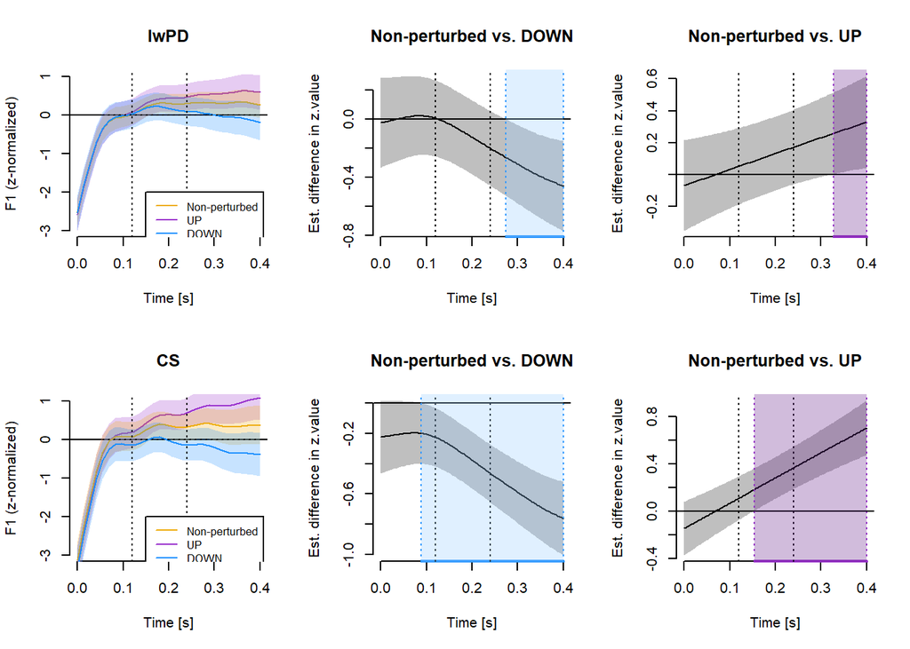

```r
xright <- 0.153535
xleft <- 0.400
ybottom <- -2
ytop <- 2
polygon(x = c(xleft, xleft, xright, xright), y = c(ybottom, ytop, ytop, ybottom), col = rgb(0.408, 0.133, 0.545, 0.3), border = NA)
```

```r
# Figure 10 (manuscript): Change in F2 depending on group and condition

par(mfrow=c(2,3))
plot_smooth(m1_reflexive, view="time_vowel", cond=list(GroupMeasure = "PD_F2",  measure = "F2",
                                                     isDOWNf1=0, isDOWNf1PD=0, isUPf1=0, isUPf1PD=0,
                                                     isDOWNf2=0, isDOWNf2PD=0, isUPf2=1, isUPf2PD=1,
                                                     isDOWNttx=0, isDOWNttxPD=0, isUPttx=0, isUPttxPD=0,
                                                     isDOWNttz=0, isDOWNttzPD=0, isUPttz=0, isUPttzPD=0,
                                                     isDOWNjawx=0, isDOWNjawxPD=0, isUPjawx=0, isUPjawxPD=0,
                                                     isDOWNjawz=0, isDOWNjawzPD=0, isUPjawz=0, isUPjawzPD=0),
            rug=F, col="darkorchid3", hide.label = T, main="IwPD", ylab="F1 (z-normalized)", xlab="Time [s]", ylim=c(-3,1))
```

```
## Summary:
##  * GroupMeasure : factor; set to the value(s): PD_F2.
##  * time_vowel : numeric predictor; with 30 values ranging from 0.000000 to 0.400000.
##  * isDOWNf1 : numeric predictor; set to the value(s): 0.
##  * isUPf1 : numeric predictor; set to the value(s): 0.
##  * isDOWNf1PD : numeric predictor; set to the value(s): 0.
##  * isUPf1PD : numeric predictor; set to the value(s): 0.
##  * isDOWNf2 : numeric predictor; set to the value(s): 0.
##  * isUPf2 : numeric predictor; set to the value(s): 1.
##  * isDOWNf2PD : numeric predictor; set to the value(s): 0.
##  * isUPf2PD : numeric predictor; set to the value(s): 1.
##  * isDOWNttx : numeric predictor; set to the value(s): 0.
##  * isUPttx : numeric predictor; set to the value(s): 0.
##  * isDOWNttxPD : numeric predictor; set to the value(s): 0.
##  * isUPttxPD : numeric predictor; set to the value(s): 0.
##  * isDOWNttz : numeric predictor; set to the value(s): 0.
##  * isUPttz : numeric predictor; set to the value(s): 0.
##  * isDOWNttzPD : numeric predictor; set to the value(s): 0.
##  * isUPttzPD : numeric predictor; set to the value(s): 0.
##  * isDOWNjawx : numeric predictor; set to the value(s): 0.
##  * isUPjawx : numeric predictor; set to the value(s): 0.
##  * isDOWNjawxPD : numeric predictor; set to the value(s): 0.
##  * isUPjawxPD : numeric predictor; set to the value(s): 0.
##  * isDOWNjawz : numeric predictor; set to the value(s): 0.
##  * isUPjawz : numeric predictor; set to the value(s): 0.
##  * isDOWNjawzPD : numeric predictor; set to the value(s): 0.
##  * isUPjawzPD : numeric predictor; set to the value(s): 0.
##  * participant : factor; set to the value(s): TRCS14. (Might be canceled as random effect, check below.)
##  * measure : factor; set to the value(s): F2.
##  * targetWord : factor; set to the value(s): BED. (Might be canceled as random effect, check below.)
##  * NOTE : The following random effects columns are canceled: s(time_vowel,participant):measureF1,s(time_vowel,participant):measureF2,s(time_vowel,participant):measureLIx,s(time_vowel,participant):measureLIz,s(time_vowel,participant):measureTTx,s(time_vowel,participant):measureTTz,s(time_vowel,par…
##
```

```r
plot_smooth(m1_reflexive, view="time_vowel", cond=list(GroupMeasure = "PD_F2",  measure = "F2",
                                                     isDOWNf1=0, isDOWNf1PD=0, isUPf1=0, isUPf1PD=0,
                                                     isDOWNf2=0, isDOWNf2PD=0, isUPf2=0, isUPf2PD=0,
                                                     isDOWNttx=0, isDOWNttxPD=0, isUPttx=0, isUPttxPD=0,
                                                     isDOWNttz=0, isDOWNttzPD=0, isUPttz=0, isUPttzPD=0,
                                                     isDOWNjawx=0, isDOWNjawxPD=0, isUPjawx=0, isUPjawxPD=0,
                                                     isDOWNjawz=0, isDOWNjawzPD=0, isUPjawz=0, isUPjawzPD=0), rug=F, col="darkgoldenrod2", add=T)
```

```
## Summary:
##  * GroupMeasure : factor; set to the value(s): PD_F2.
##  * time_vowel : numeric predictor; with 30 values ranging from 0.000000 to 0.400000.
##  * isDOWNf1 : numeric predictor; set to the value(s): 0.
##  * isUPf1 : numeric predictor; set to the value(s): 0.
##  * isDOWNf1PD : numeric predictor; set to the value(s): 0.
##  * isUPf1PD : numeric predictor; set to the value(s): 0.
##  * isDOWNf2 : numeric predictor; set to the value(s): 0.
##  * isUPf2 : numeric predictor; set to the value(s): 0.
##  * isDOWNf2PD : numeric predictor; set to the value(s): 0.
##  * isUPf2PD : numeric predictor; set to the value(s): 0.
##  * isDOWNttx : numeric predictor; set to the value(s): 0.
##  * isUPttx : numeric predictor; set to the value(s): 0.
##  * isDOWNttxPD : numeric predictor; set to the value(s): 0.
##  * isUPttxPD : numeric predictor; set to the value(s): 0.
##  * isDOWNttz : numeric predictor; set to the value(s): 0.
##  * isUPttz : numeric predictor; set to the value(s): 0.
##  * isDOWNttzPD : numeric predictor; set to the value(s): 0.
##  * isUPttzPD : numeric predictor; set to the value(s): 0.
##  * isDOWNjawx : numeric predictor; set to the value(s): 0.
##  * isUPjawx : numeric predictor; set to the value(s): 0.
##  * isDOWNjawxPD : numeric predictor; set to the value(s): 0.
##  * isUPjawxPD : numeric predictor; set to the value(s): 0.
##  * isDOWNjawz : numeric predictor; set to the value(s): 0.
##  * isUPjawz : numeric predictor; set to the value(s): 0.
##  * isDOWNjawzPD : numeric predictor; set to the value(s): 0.
##  * isUPjawzPD : numeric predictor; set to the value(s): 0.
##  * participant : factor; set to the value(s): TRCS14. (Might be canceled as random effect, check below.)
##  * measure : factor; set to the value(s): F2.
##  * targetWord : factor; set to the value(s): BED. (Might be canceled as random effect, check below.)
##  * NOTE : The following random effects columns are canceled: s(time_vowel,participant):measureF1,s(time_vowel,participant):measureF2,s(time_vowel,participant):measureLIx,s(time_vowel,participant):measureLIz,s(time_vowel,participant):measureTTx,s(time_vowel,participant):measureTTz,s(time_vowel,par…
##
```

```r
plot_smooth(m1_reflexive, view="time_vowel", cond=list(GroupMeasure = "PD_F2",  measure = "F2",
                                                     isDOWNf1=0, isDOWNf1PD=0, isUPf1=0, isUPf1PD=0,
                                                     isDOWNf2=1, isDOWNf2PD=1, isUPf2=0, isUPf2PD=0,
                                                     isDOWNttx=0, isDOWNttxPD=0, isUPttx=0, isUPttxPD=0,
                                                     isDOWNttz=0, isDOWNttzPD=0, isUPttz=0, isUPttzPD=0,
                                                     isDOWNjawx=0, isDOWNjawxPD=0, isUPjawx=0, isUPjawxPD=0,
                                                     isDOWNjawz=0, isDOWNjawzPD=0, isUPjawz=0, isUPjawzPD=0), rug=F, col="dodgerblue", add=T)
```

```
## Summary:
##  * GroupMeasure : factor; set to the value(s): PD_F2.
##  * time_vowel : numeric predictor; with 30 values ranging from 0.000000 to 0.400000.
##  * isDOWNf1 : numeric predictor; set to the value(s): 0.
##  * isUPf1 : numeric predictor; set to the value(s): 0.
##  * isDOWNf1PD : numeric predictor; set to the value(s): 0.
##  * isUPf1PD : numeric predictor; set to the value(s): 0.
##  * isDOWNf2 : numeric predictor; set to the value(s): 1.
##  * isUPf2 : numeric predictor; set to the value(s): 0.
##  * isDOWNf2PD : numeric predictor; set to the value(s): 1.
##  * isUPf2PD : numeric predictor; set to the value(s): 0.
##  * isDOWNttx : numeric predictor; set to the value(s): 0.
##  * isUPttx : numeric predictor; set to the value(s): 0.
##  * isDOWNttxPD : numeric predictor; set to the value(s): 0.
##  * isUPttxPD : numeric predictor; set to the value(s): 0.
##  * isDOWNttz : numeric predictor; set to the value(s): 0.
##  * isUPttz : numeric predictor; set to the value(s): 0.
##  * isDOWNttzPD : numeric predictor; set to the value(s): 0.
##  * isUPttzPD : numeric predictor; set to the value(s): 0.
##  * isDOWNjawx : numeric predictor; set to the value(s): 0.
##  * isUPjawx : numeric predictor; set to the value(s): 0.
##  * isDOWNjawxPD : numeric predictor; set to the value(s): 0.
##  * isUPjawxPD : numeric predictor; set to the value(s): 0.
##  * isDOWNjawz : numeric predictor; set to the value(s): 0.
##  * isUPjawz : numeric predictor; set to the value(s): 0.
##  * isDOWNjawzPD : numeric predictor; set to the value(s): 0.
##  * isUPjawzPD : numeric predictor; set to the value(s): 0.
##  * participant : factor; set to the value(s): TRCS14. (Might be canceled as random effect, check below.)
##  * measure : factor; set to the value(s): F2.
##  * targetWord : factor; set to the value(s): BED. (Might be canceled as random effect, check below.)
##  * NOTE : The following random effects columns are canceled: s(time_vowel,participant):measureF1,s(time_vowel,participant):measureF2,s(time_vowel,participant):measureLIx,s(time_vowel,participant):measureLIz,s(time_vowel,participant):measureTTx,s(time_vowel,participant):measureTTz,s(time_vowel,par…
##
```

```r
par(abline(h=0, v=c(0.12, 0.24), lty=3))
```

```
## named list()
```

```r
legend(0.15, -2, legend=c("Non-perturbed", "UP", "DOWN"), col=c("darkgoldenrod2", "darkorchid3", "dodgerblue"), lty=1:1, cex=0.8)

plot_diff(m1_reflexive, view="time_vowel", cond=list(GroupMeasure="PD_F2", measure = "F2",
                                                     isUPf1=0, isUPf1PD=0,isDOWNf1=0, isDOWNf12PD=0,
                                                     isUPf2=0, isUPf2PD=0,
                                                     isDOWNttx=0, isDOWNttxPD=0, isUPttx=0, isUPttxPD=0,
                                                     isDOWNttz=0, isDOWNttzPD=0, isUPttz=0, isUPttzPD=0,
                                                     isDOWNjawx=0, isDOWNjawxPD=0, isUPjawx=0, isUPjawxPD=0,
                                                     isDOWNjawz=0, isDOWNjawzPD=0, isUPjawz=0, isUPjawzPD=0),
                                                      comp=list(isDOWNf2=c(1,0), isDOWNf2PD=c(1,0)),
          main="Non-perturbed vs. DOWN (F2)", xlab = "Time [s]", col.diff="dodgerblue", hide.label = T)
```

```
## Summary:
##  * GroupMeasure : factor; set to the value(s): PD_F2.
##  * time_vowel : numeric predictor; with 100 values ranging from 0.000000 to 0.400000.
##  * isDOWNf1 : numeric predictor; set to the value(s): 0.
##  * isUPf1 : numeric predictor; set to the value(s): 0.
##  * isDOWNf1PD : numeric predictor; set to the value(s): 0.
##  * isUPf1PD : numeric predictor; set to the value(s): 0.
##  * isUPf2 : numeric predictor; set to the value(s): 0.
##  * isUPf2PD : numeric predictor; set to the value(s): 0.
##  * isDOWNttx : numeric predictor; set to the value(s): 0.
##  * isUPttx : numeric predictor; set to the value(s): 0.
##  * isDOWNttxPD : numeric predictor; set to the value(s): 0.
##  * isUPttxPD : numeric predictor; set to the value(s): 0.
##  * isDOWNttz : numeric predictor; set to the value(s): 0.
##  * isUPttz : numeric predictor; set to the value(s): 0.
##  * isDOWNttzPD : numeric predictor; set to the value(s): 0.
##  * isUPttzPD : numeric predictor; set to the value(s): 0.
##  * isDOWNjawx : numeric predictor; set to the value(s): 0.
##  * isUPjawx : numeric predictor; set to the value(s): 0.
##  * isDOWNjawxPD : numeric predictor; set to the value(s): 0.
##  * isUPjawxPD : numeric predictor; set to the value(s): 0.
##  * isDOWNjawz : numeric predictor; set to the value(s): 0.
##  * isUPjawz : numeric predictor; set to the value(s): 0.
##  * isDOWNjawzPD : numeric predictor; set to the value(s): 0.
##  * isUPjawzPD : numeric predictor; set to the value(s): 0.
##  * participant : factor; set to the value(s): TRCS14. (Might be canceled as random effect, check below.)
##  * measure : factor; set to the value(s): F2.
##  * targetWord : factor; set to the value(s): BED. (Might be canceled as random effect, check below.)
##  * NOTE : The following random effects columns are canceled: s(time_vowel,participant):measureF1,s(time_vowel,participant):measureF2,s(time_vowel,participant):measureLIx,s(time_vowel,participant):measureLIz,s(time_vowel,participant):measureTTx,s(time_vowel,participant):measureTTz,s(time_vowel,par…
##
```

```
##
## time_vowel window(s) of significant difference(s):
##  0.311111 - 0.395960
```

```r
par(abline(h=0, v=c(0.12, 0.24), lty=3))
```

```
## named list()
```

```r
xright <- 0.311111
xleft <- 0.395960
ybottom <- -2
ytop <- 2
polygon(x = c(xleft, xleft, xright, xright), y = c(ybottom, ytop, ytop, ybottom), col = rgb(0.6, 0.8, 1, 0.3), border = NA)

plot_diff(m1_reflexive, view="time_vowel", cond=list(GroupMeasure="PD_F2", measure = "F2",
                                                     isDOWNf1=0, isDOWNf1PD=0, isUPf1=0, isUPf1PD=0,
                                                     isDOWNf2=0, isDOWNf2PD=0,
                                                     isDOWNttx=0, isDOWNttxPD=0, isUPttx=0, isUPttxPD=0,
                                                     isDOWNttz=0, isDOWNttzPD=0, isUPttz=0, isUPttzPD=0,
                                                     isDOWNjawx=0, isDOWNjawxPD=0, isUPjawx=0, isUPjawxPD=0,
                                                     isDOWNjawz=0, isDOWNjawzPD=0, isUPjawz=0, isUPjawzPD=0),
          comp=list(isUPf2=c(1,0), isUPf2PD=c(1,0)),
          main="Non-perturbed vs. UP (F2)", xlab = "Time [s]", col.diff="darkorchid3", hide.label = T)
```

```
## Summary:
##  * GroupMeasure : factor; set to the value(s): PD_F2.
##  * time_vowel : numeric predictor; with 100 values ranging from 0.000000 to 0.400000.
##  * isDOWNf1 : numeric predictor; set to the value(s): 0.
##  * isUPf1 : numeric predictor; set to the value(s): 0.
##  * isDOWNf1PD : numeric predictor; set to the value(s): 0.
##  * isUPf1PD : numeric predictor; set to the value(s): 0.
##  * isDOWNf2 : numeric predictor; set to the value(s): 0.
##  * isDOWNf2PD : numeric predictor; set to the value(s): 0.
##  * isDOWNttx : numeric predictor; set to the value(s): 0.
##  * isUPttx : numeric predictor; set to the value(s): 0.
##  * isDOWNttxPD : numeric predictor; set to the value(s): 0.
##  * isUPttxPD : numeric predictor; set to the value(s): 0.
##  * isDOWNttz : numeric predictor; set to the value(s): 0.
##  * isUPttz : numeric predictor; set to the value(s): 0.
##  * isDOWNttzPD : numeric predictor; set to the value(s): 0.
##  * isUPttzPD : numeric predictor; set to the value(s): 0.
##  * isDOWNjawx : numeric predictor; set to the value(s): 0.
##  * isUPjawx : numeric predictor; set to the value(s): 0.
##  * isDOWNjawxPD : numeric predictor; set to the value(s): 0.
##  * isUPjawxPD : numeric predictor; set to the value(s): 0.
##  * isDOWNjawz : numeric predictor; set to the value(s): 0.
##  * isUPjawz : numeric predictor; set to the value(s): 0.
##  * isDOWNjawzPD : numeric predictor; set to the value(s): 0.
##  * isUPjawzPD : numeric predictor; set to the value(s): 0.
##  * participant : factor; set to the value(s): TRCS14. (Might be canceled as random effect, check below.)
##  * measure : factor; set to the value(s): F2.
##  * targetWord : factor; set to the value(s): BED. (Might be canceled as random effect, check below.)
##  * NOTE : The following random effects columns are canceled: s(time_vowel,participant):measureF1,s(time_vowel,participant):measureF2,s(time_vowel,participant):measureLIx,s(time_vowel,participant):measureLIz,s(time_vowel,participant):measureTTx,s(time_vowel,participant):measureTTz,s(time_vowel,par…
##
```

```
##
## time_vowel window(s) of significant difference(s):
##  0.177778 - 0.400000
```

```r
par(abline(h=0, v=c(0.12, 0.24), lty=3))
```

```
## named list()
```

```r
xright <- 0.177778
xleft <- 0.400
ybottom <- -2
ytop <- 2
polygon(x = c(xleft, xleft, xright, xright), y = c(ybottom, ytop, ytop, ybottom), col = rgb(0.408, 0.133, 0.545, 0.3), border = NA)

plot_smooth(m1_reflexive, view="time_vowel", cond=list(GroupMeasure = "CS_F2",  measure = "F2",
                                                     isDOWNf1=0, isDOWNf1PD=0, isUPf1=0, isUPf1PD=0,
                                                     isDOWNf2=0, isDOWNf2PD=0, isUPf2=1, isUPf2PD=0,
                                                     isDOWNttx=0, isDOWNttxPD=0, isUPttx=0, isUPttxPD=0,
                                                     isDOWNttz=0, isDOWNttzPD=0, isUPttz=0, isUPttzPD=0,
                                                     isDOWNjawx=0, isDOWNjawxPD=0, isUPjawx=0, isUPjawxPD=0,
                                                     isDOWNjawz=0, isDOWNjawzPD=0, isUPjawz=0, isUPjawzPD=0),
            rug=F, col="darkorchid3", hide.label = T, main="CS", ylab="F1 (z-normalized)", xlab="Time [s]", ylim=c(-3,1))
```

```
## Summary:
##  * GroupMeasure : factor; set to the value(s): CS_F2.
##  * time_vowel : numeric predictor; with 30 values ranging from 0.000000 to 0.400000.
##  * isDOWNf1 : numeric predictor; set to the value(s): 0.
##  * isUPf1 : numeric predictor; set to the value(s): 0.
##  * isDOWNf1PD : numeric predictor; set to the value(s): 0.
##  * isUPf1PD : numeric predictor; set to the value(s): 0.
##  * isDOWNf2 : numeric predictor; set to the value(s): 0.
##  * isUPf2 : numeric predictor; set to the value(s): 1.
##  * isDOWNf2PD : numeric predictor; set to the value(s): 0.
##  * isUPf2PD : numeric predictor; set to the value(s): 0.
##  * isDOWNttx : numeric predictor; set to the value(s): 0.
##  * isUPttx : numeric predictor; set to the value(s): 0.
##  * isDOWNttxPD : numeric predictor; set to the value(s): 0.
##  * isUPttxPD : numeric predictor; set to the value(s): 0.
##  * isDOWNttz : numeric predictor; set to the value(s): 0.
##  * isUPttz : numeric predictor; set to the value(s): 0.
##  * isDOWNttzPD : numeric predictor; set to the value(s): 0.
##  * isUPttzPD : numeric predictor; set to the value(s): 0.
##  * isDOWNjawx : numeric predictor; set to the value(s): 0.
##  * isUPjawx : numeric predictor; set to the value(s): 0.
##  * isDOWNjawxPD : numeric predictor; set to the value(s): 0.
##  * isUPjawxPD : numeric predictor; set to the value(s): 0.
##  * isDOWNjawz : numeric predictor; set to the value(s): 0.
##  * isUPjawz : numeric predictor; set to the value(s): 0.
##  * isDOWNjawzPD : numeric predictor; set to the value(s): 0.
##  * isUPjawzPD : numeric predictor; set to the value(s): 0.
##  * participant : factor; set to the value(s): TRCS14. (Might be canceled as random effect, check below.)
##  * measure : factor; set to the value(s): F2.
##  * targetWord : factor; set to the value(s): BED. (Might be canceled as random effect, check below.)
##  * NOTE : The following random effects columns are canceled: s(time_vowel,participant):measureF1,s(time_vowel,participant):measureF2,s(time_vowel,participant):measureLIx,s(time_vowel,participant):measureLIz,s(time_vowel,participant):measureTTx,s(time_vowel,participant):measureTTz,s(time_vowel,par…
##
```

```r
plot_smooth(m1_reflexive, view="time_vowel", cond=list(GroupMeasure = "CS_F2",  measure = "F2",
                                                     isDOWNf1=0, isDOWNf1PD=0, isUPf1=0, isUPf1PD=0,
                                                     isDOWNf2=0, isDOWNf2PD=0, isUPf2=0, isUPf2PD=0,
                                                     isDOWNttx=0, isDOWNttxPD=0, isUPttx=0, isUPttxPD=0,
                                                     isDOWNttz=0, isDOWNttzPD=0, isUPttz=0, isUPttzPD=0,
                                                     isDOWNjawx=0, isDOWNjawxPD=0, isUPjawx=0, isUPjawxPD=0,
                                                     isDOWNjawz=0, isDOWNjawzPD=0, isUPjawz=0, isUPjawzPD=0), rug=F, col="darkgoldenrod2", add=T)
```

```
## Summary:
##  * GroupMeasure : factor; set to the value(s): CS_F2.
##  * time_vowel : numeric predictor; with 30 values ranging from 0.000000 to 0.400000.
##  * isDOWNf1 : numeric predictor; set to the value(s): 0.
##  * isUPf1 : numeric predictor; set to the value(s): 0.
##  * isDOWNf1PD : numeric predictor; set to the value(s): 0.
##  * isUPf1PD : numeric predictor; set to the value(s): 0.
##  * isDOWNf2 : numeric predictor; set to the value(s): 0.
##  * isUPf2 : numeric predictor; set to the value(s): 0.
##  * isDOWNf2PD : numeric predictor; set to the value(s): 0.
##  * isUPf2PD : numeric predictor; set to the value(s): 0.
##  * isDOWNttx : numeric predictor; set to the value(s): 0.
##  * isUPttx : numeric predictor; set to the value(s): 0.
##  * isDOWNttxPD : numeric predictor; set to the value(s): 0.
##  * isUPttxPD : numeric predictor; set to the value(s): 0.
##  * isDOWNttz : numeric predictor; set to the value(s): 0.
##  * isUPttz : numeric predictor; set to the value(s): 0.
##  * isDOWNttzPD : numeric predictor; set to the value(s): 0.
##  * isUPttzPD : numeric predictor; set to the value(s): 0.
##  * isDOWNjawx : numeric predictor; set to the value(s): 0.
##  * isUPjawx : numeric predictor; set to the value(s): 0.
##  * isDOWNjawxPD : numeric predictor; set to the value(s): 0.
##  * isUPjawxPD : numeric predictor; set to the value(s): 0.
##  * isDOWNjawz : numeric predictor; set to the value(s): 0.
##  * isUPjawz : numeric predictor; set to the value(s): 0.
##  * isDOWNjawzPD : numeric predictor; set to the value(s): 0.
##  * isUPjawzPD : numeric predictor; set to the value(s): 0.
##  * participant : factor; set to the value(s): TRCS14. (Might be canceled as random effect, check below.)
##  * measure : factor; set to the value(s): F2.
##  * targetWord : factor; set to the value(s): BED. (Might be canceled as random effect, check below.)
##  * NOTE : The following random effects columns are canceled: s(time_vowel,participant):measureF1,s(time_vowel,participant):measureF2,s(time_vowel,participant):measureLIx,s(time_vowel,participant):measureLIz,s(time_vowel,participant):measureTTx,s(time_vowel,participant):measureTTz,s(time_vowel,par…
##
```

```r
plot_smooth(m1_reflexive, view="time_vowel", cond=list(GroupMeasure = "CS_F2", measure = "F2",
                                                     isDOWNf1=0, isDOWNf1PD=0, isUPf1=0, isUPf1PD=0,
                                                     isDOWNf2=1, isDOWNf2PD=0, isUPf2=0, isUPf2PD=0,
                                                     isDOWNttx=0, isDOWNttxPD=0, isUPttx=0, isUPttxPD=0,
                                                     isDOWNttz=0, isDOWNttzPD=0, isUPttz=0, isUPttzPD=0,
                                                     isDOWNjawx=0, isDOWNjawxPD=0, isUPjawx=0, isUPjawxPD=0,
                                                     isDOWNjawz=0, isDOWNjawzPD=0, isUPjawz=0, isUPjawzPD=0), rug=F, col="dodgerblue", add=T)
```

```
## Summary:
##  * GroupMeasure : factor; set to the value(s): CS_F2.
##  * time_vowel : numeric predictor; with 30 values ranging from 0.000000 to 0.400000.
##  * isDOWNf1 : numeric predictor; set to the value(s): 0.
##  * isUPf1 : numeric predictor; set to the value(s): 0.
##  * isDOWNf1PD : numeric predictor; set to the value(s): 0.
##  * isUPf1PD : numeric predictor; set to the value(s): 0.
##  * isDOWNf2 : numeric predictor; set to the value(s): 1.
##  * isUPf2 : numeric predictor; set to the value(s): 0.
##  * isDOWNf2PD : numeric predictor; set to the value(s): 0.
##  * isUPf2PD : numeric predictor; set to the value(s): 0.
##  * isDOWNttx : numeric predictor; set to the value(s): 0.
##  * isUPttx : numeric predictor; set to the value(s): 0.
##  * isDOWNttxPD : numeric predictor; set to the value(s): 0.
##  * isUPttxPD : numeric predictor; set to the value(s): 0.
##  * isDOWNttz : numeric predictor; set to the value(s): 0.
##  * isUPttz : numeric predictor; set to the value(s): 0.
##  * isDOWNttzPD : numeric predictor; set to the value(s): 0.
##  * isUPttzPD : numeric predictor; set to the value(s): 0.
##  * isDOWNjawx : numeric predictor; set to the value(s): 0.
##  * isUPjawx : numeric predictor; set to the value(s): 0.
##  * isDOWNjawxPD : numeric predictor; set to the value(s): 0.
##  * isUPjawxPD : numeric predictor; set to the value(s): 0.
##  * isDOWNjawz : numeric predictor; set to the value(s): 0.
##  * isUPjawz : numeric predictor; set to the value(s): 0.
##  * isDOWNjawzPD : numeric predictor; set to the value(s): 0.
##  * isUPjawzPD : numeric predictor; set to the value(s): 0.
##  * participant : factor; set to the value(s): TRCS14. (Might be canceled as random effect, check below.)
##  * measure : factor; set to the value(s): F2.
##  * targetWord : factor; set to the value(s): BED. (Might be canceled as random effect, check below.)
##  * NOTE : The following random effects columns are canceled: s(time_vowel,participant):measureF1,s(time_vowel,participant):measureF2,s(time_vowel,participant):measureLIx,s(time_vowel,participant):measureLIz,s(time_vowel,participant):measureTTx,s(time_vowel,participant):measureTTz,s(time_vowel,par…
##
```

```r
par(abline(h=0, v=c(0.12, 0.24), lty=3))
```

```
## named list()
```

```r
legend(0.15, -2, legend=c("Non-perturbed", "UP", "DOWN"), col=c("darkgoldenrod2", "darkorchid3", "dodgerblue"), lty=1:1, cex=0.8)

plot_diff(m1_reflexive, view="time_vowel", cond=list(GroupMeasure="CS_F2", measure = "F2",
                                                     isDOWNf1PD=0, isDOWNf1=0, isUPf1=0, isUPf1PD=0,
                                                     isDOWNf2PD=0, isUPf2=0, isUPf2PD=0,
                                                     isDOWNttx=0, isDOWNttxPD=0, isUPttx=0, isUPttxPD=0,
                                                     isDOWNttz=0, isDOWNttzPD=0, isUPttz=0, isUPttzPD=0,
                                                     isDOWNjawx=0, isDOWNjawxPD=0, isUPjawx=0, isUPjawxPD=0,
                                                     isDOWNjawz=0, isDOWNjawzPD=0, isUPjawz=0, isUPjawzPD=0),
                                                     comp=list(isDOWNf2=c(1,0)),
          main="Non-perturbed vs. DOWN (F2)", xlab = "Time [s]", col.diff="dodgerblue", hide.label = T)
```

```
## Summary:
##  * GroupMeasure : factor; set to the value(s): CS_F2.
##  * time_vowel : numeric predictor; with 100 values ranging from 0.000000 to 0.400000.
##  * isDOWNf1 : numeric predictor; set to the value(s): 0.
##  * isUPf1 : numeric predictor; set to the value(s): 0.
##  * isDOWNf1PD : numeric predictor; set to the value(s): 0.
##  * isUPf1PD : numeric predictor; set to the value(s): 0.
##  * isUPf2 : numeric predictor; set to the value(s): 0.
##  * isDOWNf2PD : numeric predictor; set to the value(s): 0.
##  * isUPf2PD : numeric predictor; set to the value(s): 0.
##  * isDOWNttx : numeric predictor; set to the value(s): 0.
##  * isUPttx : numeric predictor; set to the value(s): 0.
##  * isDOWNttxPD : numeric predictor; set to the value(s): 0.
##  * isUPttxPD : numeric predictor; set to the value(s): 0.
##  * isDOWNttz : numeric predictor; set to the value(s): 0.
##  * isUPttz : numeric predictor; set to the value(s): 0.
##  * isDOWNttzPD : numeric predictor; set to the value(s): 0.
##  * isUPttzPD : numeric predictor; set to the value(s): 0.
##  * isDOWNjawx : numeric predictor; set to the value(s): 0.
##  * isUPjawx : numeric predictor; set to the value(s): 0.
##  * isDOWNjawxPD : numeric predictor; set to the value(s): 0.
##  * isUPjawxPD : numeric predictor; set to the value(s): 0.
##  * isDOWNjawz : numeric predictor; set to the value(s): 0.
##  * isUPjawz : numeric predictor; set to the value(s): 0.
##  * isDOWNjawzPD : numeric predictor; set to the value(s): 0.
##  * isUPjawzPD : numeric predictor; set to the value(s): 0.
##  * participant : factor; set to the value(s): TRCS14. (Might be canceled as random effect, check below.)
##  * measure : factor; set to the value(s): F2.
##  * targetWord : factor; set to the value(s): BED. (Might be canceled as random effect, check below.)
##  * NOTE : The following random effects columns are canceled: s(time_vowel,participant):measureF1,s(time_vowel,participant):measureF2,s(time_vowel,participant):measureLIx,s(time_vowel,participant):measureLIz,s(time_vowel,participant):measureTTx,s(time_vowel,participant):measureTTz,s(time_vowel,par…
##
```

```
##
## time_vowel window(s) of significant difference(s):
##  0.193939 - 0.400000
```

```r
par(abline(h=0, v=c(0.12, 0.24), lty=3))
```

```
## named list()
```

```r
xright <- 0.193939
xleft <- 0.400
ybottom <- -2
ytop <- 2
polygon(x = c(xleft, xleft, xright, xright), y = c(ybottom, ytop, ytop, ybottom), col = rgb(0.6, 0.8, 1, 0.3), border = NA)

plot_diff(m1_reflexive, view="time_vowel", cond=list(GroupMeasure="CS_F2", measure = "F2",
                                                      isDOWNf1=0, isUPf1=0, isDOWNf1PD=0, isUPf1PD=0,
                                                      isDOWNf2=0, isDOWNf2PD=0, isUPf2PD=0,
                                                      isDOWNttx=0, isDOWNttxPD=0, isUPttx=0, isUPttxPD=0,
                                                      isDOWNttz=0, isDOWNttzPD=0, isUPttz=0, isUPttzPD=0,
                                                      isDOWNjawx=0, isDOWNjawxPD=0, isUPjawx=0, isUPjawxPD=0,
                                                      isDOWNjawz=0, isDOWNjawzPD=0, isUPjawz=0, isUPjawzPD=0),
                                                      comp=list(isUPf2=c(1,0)),
          main="Non-perturbed vs. UP (F2)", xlab = "Time [s]", col.diff="darkorchid3", hide.label = T)
```

```
## Summary:
##  * GroupMeasure : factor; set to the value(s): CS_F2.
##  * time_vowel : numeric predictor; with 100 values ranging from 0.000000 to 0.400000.
##  * isDOWNf1 : numeric predictor; set to the value(s): 0.
##  * isUPf1 : numeric predictor; set to the value(s): 0.
##  * isDOWNf1PD : numeric predictor; set to the value(s): 0.
##  * isUPf1PD : numeric predictor; set to the value(s): 0.
##  * isDOWNf2 : numeric predictor; set to the value(s): 0.
##  * isDOWNf2PD : numeric predictor; set to the value(s): 0.
##  * isUPf2PD : numeric predictor; set to the value(s): 0.
##  * isDOWNttx : numeric predictor; set to the value(s): 0.
##  * isUPttx : numeric predictor; set to the value(s): 0.
##  * isDOWNttxPD : numeric predictor; set to the value(s): 0.
##  * isUPttxPD : numeric predictor; set to the value(s): 0.
##  * isDOWNttz : numeric predictor; set to the value(s): 0.
##  * isUPttz : numeric predictor; set to the value(s): 0.
##  * isDOWNttzPD : numeric predictor; set to the value(s): 0.
##  * isUPttzPD : numeric predictor; set to the value(s): 0.
##  * isDOWNjawx : numeric predictor; set to the value(s): 0.
##  * isUPjawx : numeric predictor; set to the value(s): 0.
##  * isDOWNjawxPD : numeric predictor; set to the value(s): 0.
##  * isUPjawxPD : numeric predictor; set to the value(s): 0.
##  * isDOWNjawz : numeric predictor; set to the value(s): 0.
##  * isUPjawz : numeric predictor; set to the value(s): 0.
##  * isDOWNjawzPD : numeric predictor; set to the value(s): 0.
##  * isUPjawzPD : numeric predictor; set to the value(s): 0.
##  * participant : factor; set to the value(s): TRCS14. (Might be canceled as random effect, check below.)
##  * measure : factor; set to the value(s): F2.
##  * targetWord : factor; set to the value(s): BED. (Might be canceled as random effect, check below.)
##  * NOTE : The following random effects columns are canceled: s(time_vowel,participant):measureF1,s(time_vowel,participant):measureF2,s(time_vowel,participant):measureLIx,s(time_vowel,participant):measureLIz,s(time_vowel,participant):measureTTx,s(time_vowel,participant):measureTTz,s(time_vowel,par…
##
```

```
##
## time_vowel window(s) of significant difference(s):
##  0.173737 - 0.400000
```

```r
par(abline(h=0, v=c(0.12, 0.24), lty=3))
```

```
## named list()
```

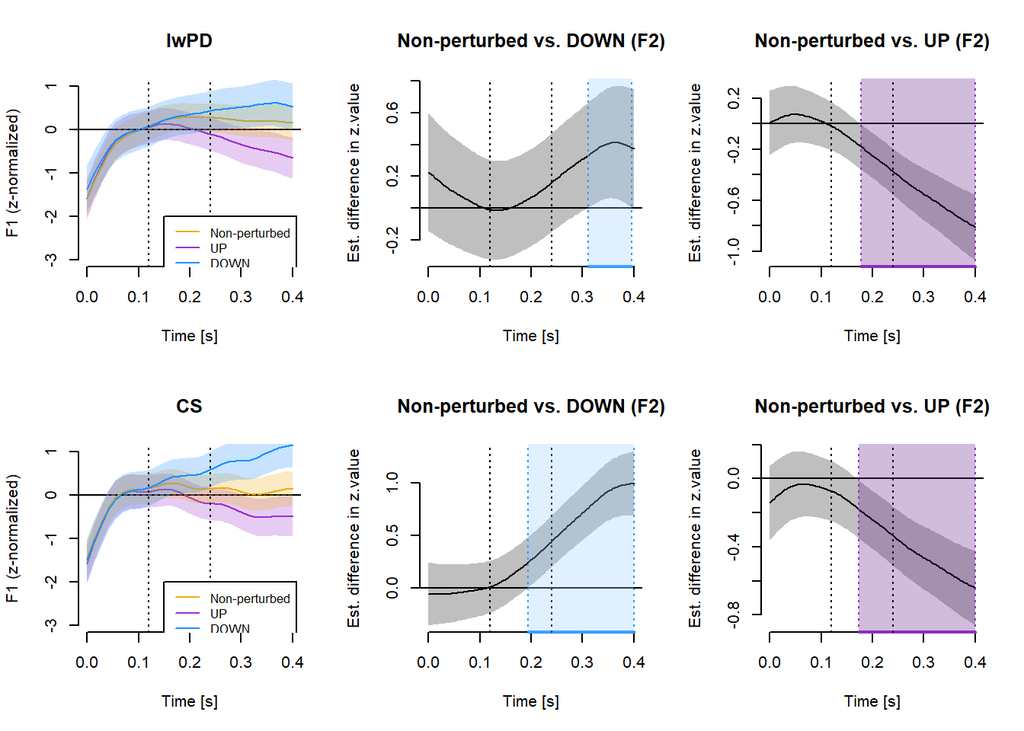

```r
xright <- 0.173737
xleft <- 0.400
ybottom <- -2
ytop <- 2
polygon(x = c(xleft, xleft, xright, xright), y = c(ybottom, ytop, ytop, ybottom), col = rgb(0.408, 0.133, 0.545, 0.3), border = NA)
```

```r
# Figure 11 (manuscript): Change in TTy depending on group and condition

par(mfrow=c(2,3))
plot_smooth(m1_reflexive, view="time_vowel", cond=list(GroupMeasure = "PD_TTz",  measure = "TTz",
                                                     isDOWNf1=0, isDOWNf1PD=0, isUPf1=0, isUPf1PD=0,
                                                     isDOWNf2=0, isDOWNf2PD=0, isUPf2=0, isUPf2PD=0,
                                                     isDOWNttx=0, isDOWNttxPD=0, isUPttx=0, isUPttxPD=0,
                                                     isDOWNttz=0, isDOWNttzPD=0, isUPttz=1, isUPttzPD=1,
                                                     isDOWNjawx=0, isDOWNjawxPD=0, isUPjawx=0, isUPjawxPD=0,
                                                     isDOWNjawz=0, isDOWNjawzPD=0, isUPjawz=0, isUPjawzPD=0),
            rug=F, col="darkorchid3", hide.label = T, main="IwPD", ylab="TTy (z-normalized)", xlab="Time [s]", ylim=c(-2,2))
```

```
## Summary:
##  * GroupMeasure : factor; set to the value(s): PD_TTz.
##  * time_vowel : numeric predictor; with 30 values ranging from 0.000000 to 0.400000.
##  * isDOWNf1 : numeric predictor; set to the value(s): 0.
##  * isUPf1 : numeric predictor; set to the value(s): 0.
##  * isDOWNf1PD : numeric predictor; set to the value(s): 0.
##  * isUPf1PD : numeric predictor; set to the value(s): 0.
##  * isDOWNf2 : numeric predictor; set to the value(s): 0.
##  * isUPf2 : numeric predictor; set to the value(s): 0.
##  * isDOWNf2PD : numeric predictor; set to the value(s): 0.
##  * isUPf2PD : numeric predictor; set to the value(s): 0.
##  * isDOWNttx : numeric predictor; set to the value(s): 0.
##  * isUPttx : numeric predictor; set to the value(s): 0.
##  * isDOWNttxPD : numeric predictor; set to the value(s): 0.
##  * isUPttxPD : numeric predictor; set to the value(s): 0.
##  * isDOWNttz : numeric predictor; set to the value(s): 0.
##  * isUPttz : numeric predictor; set to the value(s): 1.
##  * isDOWNttzPD : numeric predictor; set to the value(s): 0.
##  * isUPttzPD : numeric predictor; set to the value(s): 1.
##  * isDOWNjawx : numeric predictor; set to the value(s): 0.
##  * isUPjawx : numeric predictor; set to the value(s): 0.
##  * isDOWNjawxPD : numeric predictor; set to the value(s): 0.
##  * isUPjawxPD : numeric predictor; set to the value(s): 0.
##  * isDOWNjawz : numeric predictor; set to the value(s): 0.
##  * isUPjawz : numeric predictor; set to the value(s): 0.
##  * isDOWNjawzPD : numeric predictor; set to the value(s): 0.
##  * isUPjawzPD : numeric predictor; set to the value(s): 0.
##  * participant : factor; set to the value(s): TRCS14. (Might be canceled as random effect, check below.)
##  * measure : factor; set to the value(s): TTz.
##  * targetWord : factor; set to the value(s): BED. (Might be canceled as random effect, check below.)
##  * NOTE : The following random effects columns are canceled: s(time_vowel,participant):measureF1,s(time_vowel,participant):measureF2,s(time_vowel,participant):measureLIx,s(time_vowel,participant):measureLIz,s(time_vowel,participant):measureTTx,s(time_vowel,participant):measureTTz,s(time_vowel,par…
##
```

```r
plot_smooth(m1_reflexive, view="time_vowel", cond=list(GroupMeasure = "PD_TTz",  measure = "TTz",
                                                     isDOWNf1=0, isDOWNf1PD=0, isUPf1=0, isUPf1PD=0,
                                                     isDOWNf2=0, isDOWNf2PD=0, isUPf2=0, isUPf2PD=0,
                                                     isDOWNttx=0, isDOWNttxPD=0, isUPttx=0, isUPttxPD=0,
                                                     isDOWNttz=0, isDOWNttzPD=0, isUPttz=0, isUPttzPD=0,
                                                     isDOWNjawx=0, isDOWNjawxPD=0, isUPjawx=0, isUPjawxPD=0,
                                                     isDOWNjawz=0, isDOWNjawzPD=0, isUPjawz=0, isUPjawzPD=0), rug=F, col="darkgoldenrod2", add=T)
```

```
## Summary:
##  * GroupMeasure : factor; set to the value(s): PD_TTz.
##  * time_vowel : numeric predictor; with 30 values ranging from 0.000000 to 0.400000.
##  * isDOWNf1 : numeric predictor; set to the value(s): 0.
##  * isUPf1 : numeric predictor; set to the value(s): 0.
##  * isDOWNf1PD : numeric predictor; set to the value(s): 0.
##  * isUPf1PD : numeric predictor; set to the value(s): 0.
##  * isDOWNf2 : numeric predictor; set to the value(s): 0.
##  * isUPf2 : numeric predictor; set to the value(s): 0.
##  * isDOWNf2PD : numeric predictor; set to the value(s): 0.
##  * isUPf2PD : numeric predictor; set to the value(s): 0.
##  * isDOWNttx : numeric predictor; set to the value(s): 0.
##  * isUPttx : numeric predictor; set to the value(s): 0.
##  * isDOWNttxPD : numeric predictor; set to the value(s): 0.
##  * isUPttxPD : numeric predictor; set to the value(s): 0.
##  * isDOWNttz : numeric predictor; set to the value(s): 0.
##  * isUPttz : numeric predictor; set to the value(s): 0.
##  * isDOWNttzPD : numeric predictor; set to the value(s): 0.
##  * isUPttzPD : numeric predictor; set to the value(s): 0.
##  * isDOWNjawx : numeric predictor; set to the value(s): 0.
##  * isUPjawx : numeric predictor; set to the value(s): 0.
##  * isDOWNjawxPD : numeric predictor; set to the value(s): 0.
##  * isUPjawxPD : numeric predictor; set to the value(s): 0.
##  * isDOWNjawz : numeric predictor; set to the value(s): 0.
##  * isUPjawz : numeric predictor; set to the value(s): 0.
##  * isDOWNjawzPD : numeric predictor; set to the value(s): 0.
##  * isUPjawzPD : numeric predictor; set to the value(s): 0.
##  * participant : factor; set to the value(s): TRCS14. (Might be canceled as random effect, check below.)
##  * measure : factor; set to the value(s): TTz.
##  * targetWord : factor; set to the value(s): BED. (Might be canceled as random effect, check below.)
##  * NOTE : The following random effects columns are canceled: s(time_vowel,participant):measureF1,s(time_vowel,participant):measureF2,s(time_vowel,participant):measureLIx,s(time_vowel,participant):measureLIz,s(time_vowel,participant):measureTTx,s(time_vowel,participant):measureTTz,s(time_vowel,par…
##
```

```r
plot_smooth(m1_reflexive, view="time_vowel", cond=list(GroupMeasure = "PD_TTz",  measure = "TTz",
                                                     isDOWNf1=0, isDOWNf1PD=0, isUPf1=0, isUPf1PD=0,
                                                     isDOWNf2=0, isDOWNf2PD=0, isUPf2=0, isUPf2PD=0,
                                                     isDOWNttx=0, isDOWNttxPD=0, isUPttx=0, isUPttxPD=0,
                                                     isDOWNttz=1, isDOWNttzPD=1, isUPttz=0, isUPttzPD=0,
                                                     isDOWNjawx=0, isDOWNjawxPD=0, isUPjawx=0, isUPjawxPD=0,
                                                     isDOWNjawz=0, isDOWNjawzPD=0, isUPjawz=0, isUPjawzPD=0), rug=F, col="dodgerblue", add=T)
```

```
## Summary:
##  * GroupMeasure : factor; set to the value(s): PD_TTz.
##  * time_vowel : numeric predictor; with 30 values ranging from 0.000000 to 0.400000.
##  * isDOWNf1 : numeric predictor; set to the value(s): 0.
##  * isUPf1 : numeric predictor; set to the value(s): 0.
##  * isDOWNf1PD : numeric predictor; set to the value(s): 0.
##  * isUPf1PD : numeric predictor; set to the value(s): 0.
##  * isDOWNf2 : numeric predictor; set to the value(s): 0.
##  * isUPf2 : numeric predictor; set to the value(s): 0.
##  * isDOWNf2PD : numeric predictor; set to the value(s): 0.
##  * isUPf2PD : numeric predictor; set to the value(s): 0.
##  * isDOWNttx : numeric predictor; set to the value(s): 0.
##  * isUPttx : numeric predictor; set to the value(s): 0.
##  * isDOWNttxPD : numeric predictor; set to the value(s): 0.
##  * isUPttxPD : numeric predictor; set to the value(s): 0.
##  * isDOWNttz : numeric predictor; set to the value(s): 1.
##  * isUPttz : numeric predictor; set to the value(s): 0.
##  * isDOWNttzPD : numeric predictor; set to the value(s): 1.
##  * isUPttzPD : numeric predictor; set to the value(s): 0.
##  * isDOWNjawx : numeric predictor; set to the value(s): 0.
##  * isUPjawx : numeric predictor; set to the value(s): 0.
##  * isDOWNjawxPD : numeric predictor; set to the value(s): 0.
##  * isUPjawxPD : numeric predictor; set to the value(s): 0.
##  * isDOWNjawz : numeric predictor; set to the value(s): 0.
##  * isUPjawz : numeric predictor; set to the value(s): 0.
##  * isDOWNjawzPD : numeric predictor; set to the value(s): 0.
##  * isUPjawzPD : numeric predictor; set to the value(s): 0.
##  * participant : factor; set to the value(s): TRCS14. (Might be canceled as random effect, check below.)
##  * measure : factor; set to the value(s): TTz.
##  * targetWord : factor; set to the value(s): BED. (Might be canceled as random effect, check below.)
##  * NOTE : The following random effects columns are canceled: s(time_vowel,participant):measureF1,s(time_vowel,participant):measureF2,s(time_vowel,participant):measureLIx,s(time_vowel,participant):measureLIz,s(time_vowel,participant):measureTTx,s(time_vowel,participant):measureTTz,s(time_vowel,par…
##
```

```r
par(abline(h=0, v=c(0.12, 0.24), lty=3))
```

```
## named list()
```

```r
legend(0.15, -1, legend=c("Non-perturbed", "UP", "DOWN"), col=c("darkgoldenrod2", "darkorchid3", "dodgerblue"), lty=1:1, cex=0.8)

plot_diff(m1_reflexive, view="time_vowel", cond=list(GroupMeasure = "PD_TTz",  measure = "TTz",
                                                     isUPf1=0, isUPf1PD=0,isDOWNf1=0, isDOWNf12PD=0,
                                                     isUPf2=0, isUPf2PD=0, isDOWNf2=0, isDOWNf2pd=0,
                                                     isDOWNttx=0, isDOWNttxPD=0, isUPttx=0, isUPttxPD=0,
                                                     isUPttz=0, isUPttzPD=0,
                                                     isDOWNjawx=0, isDOWNjawxPD=0, isUPjawx=0, isUPjawxPD=0,
                                                     isDOWNjawz=0, isDOWNjawzPD=0, isUPjawz=0, isUPjawzPD=0),
                                                      comp=list(isDOWNttz=c(1,0), isDOWNttzPD=c(1,0)),
          main="Non-perturbed vs. DOWN (TTy)", col.diff="dodgerblue", xlab = "Time [s]", hide.label = T)
```

```
## Summary:
##  * GroupMeasure : factor; set to the value(s): PD_TTz.
##  * time_vowel : numeric predictor; with 100 values ranging from 0.000000 to 0.400000.
##  * isDOWNf1 : numeric predictor; set to the value(s): 0.
##  * isUPf1 : numeric predictor; set to the value(s): 0.
##  * isDOWNf1PD : numeric predictor; set to the value(s): 0.
##  * isUPf1PD : numeric predictor; set to the value(s): 0.
##  * isDOWNf2 : numeric predictor; set to the value(s): 0.
##  * isUPf2 : numeric predictor; set to the value(s): 0.
##  * isDOWNf2PD : numeric predictor; set to the value(s): 0.
##  * isUPf2PD : numeric predictor; set to the value(s): 0.
##  * isDOWNttx : numeric predictor; set to the value(s): 0.
##  * isUPttx : numeric predictor; set to the value(s): 0.
##  * isDOWNttxPD : numeric predictor; set to the value(s): 0.
##  * isUPttxPD : numeric predictor; set to the value(s): 0.
##  * isUPttz : numeric predictor; set to the value(s): 0.
##  * isUPttzPD : numeric predictor; set to the value(s): 0.
##  * isDOWNjawx : numeric predictor; set to the value(s): 0.
##  * isUPjawx : numeric predictor; set to the value(s): 0.
##  * isDOWNjawxPD : numeric predictor; set to the value(s): 0.
##  * isUPjawxPD : numeric predictor; set to the value(s): 0.
##  * isDOWNjawz : numeric predictor; set to the value(s): 0.
##  * isUPjawz : numeric predictor; set to the value(s): 0.
##  * isDOWNjawzPD : numeric predictor; set to the value(s): 0.
##  * isUPjawzPD : numeric predictor; set to the value(s): 0.
##  * participant : factor; set to the value(s): TRCS14. (Might be canceled as random effect, check below.)
##  * measure : factor; set to the value(s): TTz.
##  * targetWord : factor; set to the value(s): BED. (Might be canceled as random effect, check below.)
##  * NOTE : The following random effects columns are canceled: s(time_vowel,participant):measureF1,s(time_vowel,participant):measureF2,s(time_vowel,participant):measureLIx,s(time_vowel,participant):measureLIz,s(time_vowel,participant):measureTTx,s(time_vowel,participant):measureTTz,s(time_vowel,par…
##
```

```
##
## time_vowel window(s) of significant difference(s):
##  0.274747 - 0.400000
```

```r
par(abline(h=0, v=c(0.12, 0.24), lty=3))
```

```
## named list()
```

```r
xright <- 0.274747
xleft <- 0.400
ybottom <- -2
ytop <- 2
polygon(x = c(xleft, xleft, xright, xright), y = c(ybottom, ytop, ytop, ybottom), col = rgb(0.6, 0.8, 1, 0.3), border = NA)

plot_diff(m1_reflexive, view="time_vowel", cond=list(GroupMeasure = "PD_TTz",  measure = "TTz",
                                                     isDOWNf1=0, isDOWNf1PD=0, isUPf1=0, isUPf1PD=0,
                                                     isUPf2=0, isUPf2PD=0, isDOWNf2=0, isDOWNf2pd=0,
                                                     isDOWNttx=0, isDOWNttxPD=0, isUPttx=0, isUPttxPD=0,
                                                     isDOWNttz=0, isDOWNttzPD=0,
                                                     isDOWNjawx=0, isDOWNjawxPD=0, isUPjawx=0, isUPjawxPD=0,
                                                     isDOWNjawz=0, isDOWNjawzPD=0, isUPjawz=0, isUPjawzPD=0),
                                                    comp=list(isUPttz=c(1,0), isUPttzPD=c(1,0)),
          main="Non-perturbed vs. UP (TTy)", xlab = "Time [s]", col.diff="darkorchid3", hide.label = T)
```

```
## Summary:
##  * GroupMeasure : factor; set to the value(s): PD_TTz.
##  * time_vowel : numeric predictor; with 100 values ranging from 0.000000 to 0.400000.
##  * isDOWNf1 : numeric predictor; set to the value(s): 0.
##  * isUPf1 : numeric predictor; set to the value(s): 0.
##  * isDOWNf1PD : numeric predictor; set to the value(s): 0.
##  * isUPf1PD : numeric predictor; set to the value(s): 0.
##  * isDOWNf2 : numeric predictor; set to the value(s): 0.
##  * isUPf2 : numeric predictor; set to the value(s): 0.
##  * isDOWNf2PD : numeric predictor; set to the value(s): 0.
##  * isUPf2PD : numeric predictor; set to the value(s): 0.
##  * isDOWNttx : numeric predictor; set to the value(s): 0.
##  * isUPttx : numeric predictor; set to the value(s): 0.
##  * isDOWNttxPD : numeric predictor; set to the value(s): 0.
##  * isUPttxPD : numeric predictor; set to the value(s): 0.
##  * isDOWNttz : numeric predictor; set to the value(s): 0.
##  * isDOWNttzPD : numeric predictor; set to the value(s): 0.
##  * isDOWNjawx : numeric predictor; set to the value(s): 0.
##  * isUPjawx : numeric predictor; set to the value(s): 0.
##  * isDOWNjawxPD : numeric predictor; set to the value(s): 0.
##  * isUPjawxPD : numeric predictor; set to the value(s): 0.
##  * isDOWNjawz : numeric predictor; set to the value(s): 0.
##  * isUPjawz : numeric predictor; set to the value(s): 0.
##  * isDOWNjawzPD : numeric predictor; set to the value(s): 0.
##  * isUPjawzPD : numeric predictor; set to the value(s): 0.
##  * participant : factor; set to the value(s): TRCS14. (Might be canceled as random effect, check below.)
##  * measure : factor; set to the value(s): TTz.
##  * targetWord : factor; set to the value(s): BED. (Might be canceled as random effect, check below.)
##  * NOTE : The following random effects columns are canceled: s(time_vowel,participant):measureF1,s(time_vowel,participant):measureF2,s(time_vowel,participant):measureLIx,s(time_vowel,participant):measureLIz,s(time_vowel,participant):measureTTx,s(time_vowel,participant):measureTTz,s(time_vowel,par…
##
```

```
##
## time_vowel window(s) of significant difference(s):
##  0.331313 - 0.400000
```

```r
par(abline(h=0, v=c(0.12, 0.24), lty=3))
```

```
## named list()
```

```r
xright <- 0.331313
xleft <- 0.400
ybottom <- -2
ytop <- 2
polygon(x = c(xleft, xleft, xright, xright), y = c(ybottom, ytop, ytop, ybottom), col = rgb(0.408, 0.133, 0.545, 0.3), border = NA)

plot_smooth(m1_reflexive, view="time_vowel", cond=list(GroupMeasure = "CS_TTz",  measure = "TTz",
                                                     isDOWNf1=0, isDOWNf1PD=0, isUPf1=0, isUPf1PD=0,
                                                     isDOWNf2=0, isDOWNf2PD=0, isUPf2=0, isUPf2PD=0,
                                                     isDOWNttx=0, isDOWNttxPD=0, isUPttx=0, isUPttxPD=0,
                                                     isDOWNttz=0, isDOWNttzPD=0, isUPttz=1, isUPttzPD=0,
                                                     isDOWNjawx=0, isDOWNjawxPD=0, isUPjawx=0, isUPjawxPD=0,
                                                     isDOWNjawz=0, isDOWNjawzPD=0, isUPjawz=0, isUPjawzPD=0),
            rug=F, col="darkorchid3", hide.label = T, main="CS", ylab="TTy (z-normalized)", xlab="Time [s]", ylim=c(-2,2))
```

```
## Summary:
##  * GroupMeasure : factor; set to the value(s): CS_TTz.
##  * time_vowel : numeric predictor; with 30 values ranging from 0.000000 to 0.400000.
##  * isDOWNf1 : numeric predictor; set to the value(s): 0.
##  * isUPf1 : numeric predictor; set to the value(s): 0.
##  * isDOWNf1PD : numeric predictor; set to the value(s): 0.
##  * isUPf1PD : numeric predictor; set to the value(s): 0.
##  * isDOWNf2 : numeric predictor; set to the value(s): 0.
##  * isUPf2 : numeric predictor; set to the value(s): 0.
##  * isDOWNf2PD : numeric predictor; set to the value(s): 0.
##  * isUPf2PD : numeric predictor; set to the value(s): 0.
##  * isDOWNttx : numeric predictor; set to the value(s): 0.
##  * isUPttx : numeric predictor; set to the value(s): 0.
##  * isDOWNttxPD : numeric predictor; set to the value(s): 0.
##  * isUPttxPD : numeric predictor; set to the value(s): 0.
##  * isDOWNttz : numeric predictor; set to the value(s): 0.
##  * isUPttz : numeric predictor; set to the value(s): 1.
##  * isDOWNttzPD : numeric predictor; set to the value(s): 0.
##  * isUPttzPD : numeric predictor; set to the value(s): 0.
##  * isDOWNjawx : numeric predictor; set to the value(s): 0.
##  * isUPjawx : numeric predictor; set to the value(s): 0.
##  * isDOWNjawxPD : numeric predictor; set to the value(s): 0.
##  * isUPjawxPD : numeric predictor; set to the value(s): 0.
##  * isDOWNjawz : numeric predictor; set to the value(s): 0.
##  * isUPjawz : numeric predictor; set to the value(s): 0.
##  * isDOWNjawzPD : numeric predictor; set to the value(s): 0.
##  * isUPjawzPD : numeric predictor; set to the value(s): 0.
##  * participant : factor; set to the value(s): TRCS14. (Might be canceled as random effect, check below.)
##  * measure : factor; set to the value(s): TTz.
##  * targetWord : factor; set to the value(s): BED. (Might be canceled as random effect, check below.)
##  * NOTE : The following random effects columns are canceled: s(time_vowel,participant):measureF1,s(time_vowel,participant):measureF2,s(time_vowel,participant):measureLIx,s(time_vowel,participant):measureLIz,s(time_vowel,participant):measureTTx,s(time_vowel,participant):measureTTz,s(time_vowel,par…
##
```

```r
plot_smooth(m1_reflexive, view="time_vowel", cond=list(GroupMeasure = "CS_TTz",  measure = "TTz",
                                                     isDOWNf1=0, isDOWNf1PD=0, isUPf1=0, isUPf1PD=0,
                                                     isDOWNf2=0, isDOWNf2PD=0, isUPf2=0, isUPf2PD=0,
                                                     isDOWNttx=0, isDOWNttxPD=0, isUPttx=0, isUPttxPD=0,
                                                     isDOWNttz=0, isDOWNttzPD=0, isUPttz=0, isUPttzPD=0,
                                                     isDOWNjawx=0, isDOWNjawxPD=0, isUPjawx=0, isUPjawxPD=0,
                                                     isDOWNjawz=0, isDOWNjawzPD=0, isUPjawz=0, isUPjawzPD=0), rug=F, col="darkgoldenrod2", add=T)
```

```
## Summary:
##  * GroupMeasure : factor; set to the value(s): CS_TTz.
##  * time_vowel : numeric predictor; with 30 values ranging from 0.000000 to 0.400000.
##  * isDOWNf1 : numeric predictor; set to the value(s): 0.
##  * isUPf1 : numeric predictor; set to the value(s): 0.
##  * isDOWNf1PD : numeric predictor; set to the value(s): 0.
##  * isUPf1PD : numeric predictor; set to the value(s): 0.
##  * isDOWNf2 : numeric predictor; set to the value(s): 0.
##  * isUPf2 : numeric predictor; set to the value(s): 0.
##  * isDOWNf2PD : numeric predictor; set to the value(s): 0.
##  * isUPf2PD : numeric predictor; set to the value(s): 0.
##  * isDOWNttx : numeric predictor; set to the value(s): 0.
##  * isUPttx : numeric predictor; set to the value(s): 0.
##  * isDOWNttxPD : numeric predictor; set to the value(s): 0.
##  * isUPttxPD : numeric predictor; set to the value(s): 0.
##  * isDOWNttz : numeric predictor; set to the value(s): 0.
##  * isUPttz : numeric predictor; set to the value(s): 0.
##  * isDOWNttzPD : numeric predictor; set to the value(s): 0.
##  * isUPttzPD : numeric predictor; set to the value(s): 0.
##  * isDOWNjawx : numeric predictor; set to the value(s): 0.
##  * isUPjawx : numeric predictor; set to the value(s): 0.
##  * isDOWNjawxPD : numeric predictor; set to the value(s): 0.
##  * isUPjawxPD : numeric predictor; set to the value(s): 0.
##  * isDOWNjawz : numeric predictor; set to the value(s): 0.
##  * isUPjawz : numeric predictor; set to the value(s): 0.
##  * isDOWNjawzPD : numeric predictor; set to the value(s): 0.
##  * isUPjawzPD : numeric predictor; set to the value(s): 0.
##  * participant : factor; set to the value(s): TRCS14. (Might be canceled as random effect, check below.)
##  * measure : factor; set to the value(s): TTz.
##  * targetWord : factor; set to the value(s): BED. (Might be canceled as random effect, check below.)
##  * NOTE : The following random effects columns are canceled: s(time_vowel,participant):measureF1,s(time_vowel,participant):measureF2,s(time_vowel,participant):measureLIx,s(time_vowel,participant):measureLIz,s(time_vowel,participant):measureTTx,s(time_vowel,participant):measureTTz,s(time_vowel,par…
##
```

```r
plot_smooth(m1_reflexive, view="time_vowel", cond=list(GroupMeasure = "CS_TTz",  measure = "TTz",
                                                     isDOWNf1=0, isDOWNf1PD=0, isUPf1=0, isUPf1PD=0,
                                                     isDOWNf2=0, isDOWNf2PD=0, isUPf2=0, isUPf2PD=0,
                                                     isDOWNttx=0, isDOWNttxPD=0, isUPttx=0, isUPttxPD=0,
                                                     isDOWNttz=1, isDOWNttzPD=0, isUPttz=0, isUPttzPD=0,
                                                     isDOWNjawx=0, isDOWNjawxPD=0, isUPjawx=0, isUPjawxPD=0,
                                                     isDOWNjawz=0, isDOWNjawzPD=0, isUPjawz=0, isUPjawzPD=0), rug=F, col="dodgerblue", add=T)
```

```
## Summary:
##  * GroupMeasure : factor; set to the value(s): CS_TTz.
##  * time_vowel : numeric predictor; with 30 values ranging from 0.000000 to 0.400000.
##  * isDOWNf1 : numeric predictor; set to the value(s): 0.
##  * isUPf1 : numeric predictor; set to the value(s): 0.
##  * isDOWNf1PD : numeric predictor; set to the value(s): 0.
##  * isUPf1PD : numeric predictor; set to the value(s): 0.
##  * isDOWNf2 : numeric predictor; set to the value(s): 0.
##  * isUPf2 : numeric predictor; set to the value(s): 0.
##  * isDOWNf2PD : numeric predictor; set to the value(s): 0.
##  * isUPf2PD : numeric predictor; set to the value(s): 0.
##  * isDOWNttx : numeric predictor; set to the value(s): 0.
##  * isUPttx : numeric predictor; set to the value(s): 0.
##  * isDOWNttxPD : numeric predictor; set to the value(s): 0.
##  * isUPttxPD : numeric predictor; set to the value(s): 0.
##  * isDOWNttz : numeric predictor; set to the value(s): 1.
##  * isUPttz : numeric predictor; set to the value(s): 0.
##  * isDOWNttzPD : numeric predictor; set to the value(s): 0.
##  * isUPttzPD : numeric predictor; set to the value(s): 0.
##  * isDOWNjawx : numeric predictor; set to the value(s): 0.
##  * isUPjawx : numeric predictor; set to the value(s): 0.
##  * isDOWNjawxPD : numeric predictor; set to the value(s): 0.
##  * isUPjawxPD : numeric predictor; set to the value(s): 0.
##  * isDOWNjawz : numeric predictor; set to the value(s): 0.
##  * isUPjawz : numeric predictor; set to the value(s): 0.
##  * isDOWNjawzPD : numeric predictor; set to the value(s): 0.
##  * isUPjawzPD : numeric predictor; set to the value(s): 0.
##  * participant : factor; set to the value(s): TRCS14. (Might be canceled as random effect, check below.)
##  * measure : factor; set to the value(s): TTz.
##  * targetWord : factor; set to the value(s): BED. (Might be canceled as random effect, check below.)
##  * NOTE : The following random effects columns are canceled: s(time_vowel,participant):measureF1,s(time_vowel,participant):measureF2,s(time_vowel,participant):measureLIx,s(time_vowel,participant):measureLIz,s(time_vowel,participant):measureTTx,s(time_vowel,participant):measureTTz,s(time_vowel,par…
##
```

```r
par(abline(h=0, v=c(0.12, 0.24), lty=3))
```

```
## named list()
```

```r
legend(0.15, -1, legend=c("Non-perturbed", "UP", "DOWN"), col=c("darkgoldenrod2", "darkorchid3", "dodgerblue"), lty=1:1, cex=0.8)

plot_diff(m1_reflexive, view="time_vowel", cond=list(GroupMeasure = "CS_TTz",  measure = "TTz",
                                                     isDOWNf1PD=0, isDOWNf1=0, isUPf1=0, isUPf1PD=0,
                                                     isUPf2=0, isUPf2PD=0, isDOWNf2=0, isDOWNf2pd=0,
                                                     isDOWNttx=0, isDOWNttxPD=0, isUPttx=0, isUPttxPD=0,
                                                     isDOWNttzPD=0, isUPttz=0, isUPttzPD=0,
                                                     isDOWNjawx=0, isDOWNjawxPD=0, isUPjawx=0, isUPjawxPD=0,
                                                     isDOWNjawz=0, isDOWNjawzPD=0, isUPjawz=0, isUPjawzPD=0),
                                                     comp=list(isDOWNttz=c(1,0)),
          main="Non-perturbed vs. DOWN (TTy)", col.diff="dodgerblue", xlab = "Time [s]", hide.label = T)
```

```
## Summary:
##  * GroupMeasure : factor; set to the value(s): CS_TTz.
##  * time_vowel : numeric predictor; with 100 values ranging from 0.000000 to 0.400000.
##  * isDOWNf1 : numeric predictor; set to the value(s): 0.
##  * isUPf1 : numeric predictor; set to the value(s): 0.
##  * isDOWNf1PD : numeric predictor; set to the value(s): 0.
##  * isUPf1PD : numeric predictor; set to the value(s): 0.
##  * isDOWNf2 : numeric predictor; set to the value(s): 0.
##  * isUPf2 : numeric predictor; set to the value(s): 0.
##  * isDOWNf2PD : numeric predictor; set to the value(s): 0.
##  * isUPf2PD : numeric predictor; set to the value(s): 0.
##  * isDOWNttx : numeric predictor; set to the value(s): 0.
##  * isUPttx : numeric predictor; set to the value(s): 0.
##  * isDOWNttxPD : numeric predictor; set to the value(s): 0.
##  * isUPttxPD : numeric predictor; set to the value(s): 0.
##  * isUPttz : numeric predictor; set to the value(s): 0.
##  * isDOWNttzPD : numeric predictor; set to the value(s): 0.
##  * isUPttzPD : numeric predictor; set to the value(s): 0.
##  * isDOWNjawx : numeric predictor; set to the value(s): 0.
##  * isUPjawx : numeric predictor; set to the value(s): 0.
##  * isDOWNjawxPD : numeric predictor; set to the value(s): 0.
##  * isUPjawxPD : numeric predictor; set to the value(s): 0.
##  * isDOWNjawz : numeric predictor; set to the value(s): 0.
##  * isUPjawz : numeric predictor; set to the value(s): 0.
##  * isDOWNjawzPD : numeric predictor; set to the value(s): 0.
##  * isUPjawzPD : numeric predictor; set to the value(s): 0.
##  * participant : factor; set to the value(s): TRCS14. (Might be canceled as random effect, check below.)
##  * measure : factor; set to the value(s): TTz.
##  * targetWord : factor; set to the value(s): BED. (Might be canceled as random effect, check below.)
##  * NOTE : The following random effects columns are canceled: s(time_vowel,participant):measureF1,s(time_vowel,participant):measureF2,s(time_vowel,participant):measureLIx,s(time_vowel,participant):measureLIz,s(time_vowel,participant):measureTTx,s(time_vowel,participant):measureTTz,s(time_vowel,par…
##
```

```
##
## Difference is not significant.
```

```r
par(abline(h=0, v=c(0.12, 0.24), lty=3))
```

```
## named list()
```

```r
plot_diff(m1_reflexive, view="time_vowel", cond=list(GroupMeasure = "CS_TTz",  measure = "TTz",
                                                      isDOWNf1=0, isUPf1=0, isDOWNf1PD=0, isUPf1PD=0,
                                                      isUPf2=0, isUPf2PD=0, isDOWNf2=0, isDOWNf2pd=0,
                                                      isDOWNttx=0, isDOWNttxPD=0, isUPttx=0, isUPttxPD=0,
                                                      isDOWNttz=0, isDOWNttzPD=0, isUPttzPD=0,
                                                      isDOWNjawx=0, isDOWNjawxPD=0, isUPjawx=0, isUPjawxPD=0,
                                                      isDOWNjawz=0, isDOWNjawzPD=0, isUPjawz=0, isUPjawzPD=0),
                                                      comp=list(isUPttz=c(1,0)),
          main="Non-perturbed vs. UP (TTy)", hide.label = T, col.diff="darkorchid3", xlab = "Time [s]")
```

```
## Summary:
##  * GroupMeasure : factor; set to the value(s): CS_TTz.
##  * time_vowel : numeric predictor; with 100 values ranging from 0.000000 to 0.400000.
##  * isDOWNf1 : numeric predictor; set to the value(s): 0.
##  * isUPf1 : numeric predictor; set to the value(s): 0.
##  * isDOWNf1PD : numeric predictor; set to the value(s): 0.
##  * isUPf1PD : numeric predictor; set to the value(s): 0.
##  * isDOWNf2 : numeric predictor; set to the value(s): 0.
##  * isUPf2 : numeric predictor; set to the value(s): 0.
##  * isDOWNf2PD : numeric predictor; set to the value(s): 0.
##  * isUPf2PD : numeric predictor; set to the value(s): 0.
##  * isDOWNttx : numeric predictor; set to the value(s): 0.
##  * isUPttx : numeric predictor; set to the value(s): 0.
##  * isDOWNttxPD : numeric predictor; set to the value(s): 0.
##  * isUPttxPD : numeric predictor; set to the value(s): 0.
##  * isDOWNttz : numeric predictor; set to the value(s): 0.
##  * isDOWNttzPD : numeric predictor; set to the value(s): 0.
##  * isUPttzPD : numeric predictor; set to the value(s): 0.
##  * isDOWNjawx : numeric predictor; set to the value(s): 0.
##  * isUPjawx : numeric predictor; set to the value(s): 0.
##  * isDOWNjawxPD : numeric predictor; set to the value(s): 0.
##  * isUPjawxPD : numeric predictor; set to the value(s): 0.
##  * isDOWNjawz : numeric predictor; set to the value(s): 0.
##  * isUPjawz : numeric predictor; set to the value(s): 0.
##  * isDOWNjawzPD : numeric predictor; set to the value(s): 0.
##  * isUPjawzPD : numeric predictor; set to the value(s): 0.
##  * participant : factor; set to the value(s): TRCS14. (Might be canceled as random effect, check below.)
##  * measure : factor; set to the value(s): TTz.
##  * targetWord : factor; set to the value(s): BED. (Might be canceled as random effect, check below.)
##  * NOTE : The following random effects columns are canceled: s(time_vowel,participant):measureF1,s(time_vowel,participant):measureF2,s(time_vowel,participant):measureLIx,s(time_vowel,participant):measureLIz,s(time_vowel,participant):measureTTx,s(time_vowel,participant):measureTTz,s(time_vowel,par…
##
```

```
##
## time_vowel window(s) of significant difference(s):
##  0.214141 - 0.400000
```

```r
par(abline(h=0, v=c(0.12, 0.24), lty=3))
```

```
## named list()
```

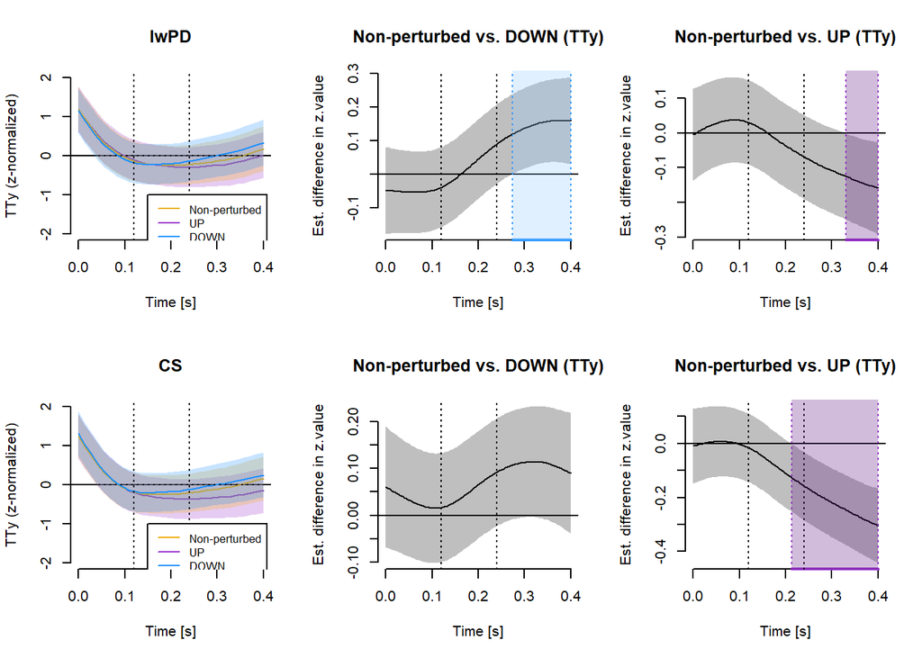

```r
xright <- 0.214141
xleft <- 0.400
ybottom <- -2
ytop <- 2
polygon(x = c(xleft, xleft, xright, xright), y = c(ybottom, ytop, ytop, ybottom), col = rgb(0.408, 0.133, 0.545, 0.3), border = NA)
```

```r
# Figure 12 (manuscript): Change in TBy depending on group and condition
par(mfrow=c(2,3))
plot_smooth(m1_reflexive_tb, view="time_vowel", cond=list(GroupMeasure = "PD_TBz",  measure = "TBz",
                                                     isDOWNf1=0, isDOWNf1PD=0, isUPf1=0, isUPf1PD=0,
                                                     isDOWNf2=0, isDOWNf2PD=0, isUPf2=0, isUPf2PD=0,
                                                     isDOWNttx=0, isDOWNttxPD=0, isUPttx=0, isUPttxPD=0,
                                                     isDOWNttz=0, isDOWNttzPD=0, isUPttz=0, isUPttzPD=0,
                                                     isDOWNtbx=0, isDOWNtbxPD=0, isUPtbx=0, isUPtbxPD=0,
                                                     isDOWNtbz=0, isDOWNtbzPD=0, isUPtbz=1, isUPtbzPD=1,
                                                     isDOWNjawx=0, isDOWNjawxPD=0, isUPjawx=0, isUPjawxPD=0,
                                                     isDOWNjawz=0, isDOWNjawzPD=0, isUPjawz=0, isUPjawzPD=0),
            rug=F, col="darkorchid3", hide.label = T, main="IwPD", ylab="TBy (z-normalized)", xlab="Time [s]", ylim=c(-2,2))
```

[output not shown]

```r
plot_smooth(m1_reflexive_tb, view="time_vowel", cond=list(GroupMeasure = "PD_TBz",  measure = "TBz",
                                                     isDOWNf1=0, isDOWNf1PD=0, isUPf1=0, isUPf1PD=0,
                                                     isDOWNf2=0, isDOWNf2PD=0, isUPf2=0, isUPf2PD=0,
                                                     isDOWNttx=0, isDOWNttxPD=0, isUPttx=0, isUPttxPD=0,
                                                     isDOWNttz=0, isDOWNttzPD=0, isUPttz=0, isUPttzPD=0,
                                                     isDOWNtbx=0, isDOWNtbxPD=0, isUPtbx=0, isUPtbxPD=0,
                                                     isDOWNtbz=0, isDOWNtbzPD=0, isUPtbz=0, isUPtbzPD=0,
                                                      isDOWNjawx=0, isDOWNjawxPD=0, isUPjawx=0, isUPjawxPD=0,
                                                     isDOWNjawz=0, isDOWNjawzPD=0, isUPjawz=0, isUPjawzPD=0), rug=F, col="darkgoldenrod2", add=T)
```

[output not shown]

```r
plot_smooth(m1_reflexive_tb, view="time_vowel", cond=list(GroupMeasure = "PD_TBz",  measure = "TBz",
                                                     isDOWNf1=0, isDOWNf1PD=0, isUPf1=0, isUPf1PD=0,
                                                     isDOWNf2=0, isDOWNf2PD=0, isUPf2=0, isUPf2PD=0,
                                                     isDOWNttx=0, isDOWNttxPD=0, isUPttx=0, isUPttxPD=0,
                                                     isDOWNttz=0, isDOWNttzPD=0, isUPttz=0, isUPttzPD=0,                                                                                                isDOWNtbx=0, isDOWNtbxPD=0, isUPtbx=0, isUPtbxPD=0,
                                                     isDOWNtbz=1, isDOWNtbzPD=1, isUPtbz=0, isUPtbzPD=0,

                                                     isDOWNjawx=0, isDOWNjawxPD=0, isUPjawx=0, isUPjawxPD=0,
                                                     isDOWNjawz=0, isDOWNjawzPD=0, isUPjawz=0, isUPjawzPD=0), rug=F, col="dodgerblue", add=T)
```

[output not shown]

```r
par(abline(h=0, v=c(0.12, 0.24), lty=3))
```

```
## named list()
```

```r
legend(0.15, -1, legend=c("Non-perturbed", "UP", "DOWN"), col=c("darkgoldenrod2", "darkorchid3", "dodgerblue"), lty=1:1, cex=0.8)

plot_diff(m1_reflexive_tb, view="time_vowel", cond=list(GroupMeasure = "PD_TBz",  measure = "TBz",
                                                     isUPf1=0, isUPf1PD=0,isDOWNf1=0, isDOWNf12PD=0,
                                                     isUPf2=0, isUPf2PD=0, isDOWNf2=0, isDOWNf2pd=0,
                                                     isDOWNttx=0, isDOWNttxPD=0, isUPttx=0, isUPttxPD=0,
                                                     isDOWNttz=0, isDOWNttzPD=0, isUPttz=0, isUPttzPD=0,
                                                    isDOWNtbx=0, isDOWNtbxPD=0, isUPtbx=0, isUPtbxPD=0,
                                                     isUPtbz=0, isUPtbzPD=0,
                                                     isDOWNjawx=0, isDOWNjawxPD=0, isUPjawx=0, isUPjawxPD=0,
                                                     isDOWNjawz=0, isDOWNjawzPD=0, isUPjawz=0, isUPjawzPD=0),
                                                      comp=list(isDOWNtbz=c(1,0), isDOWNtbzPD=c(1,0)),
          main="Non-perturbed vs. DOWN (TBy)", xlab="Time [s]", col.diff="dodgerblue", hide.label = T)
```

[output not shown]

```
##
## time_vowel window(s) of significant difference(s):
##  0.278788 - 0.400000
```

```r
par(abline(h=0, v=c(0.12, 0.24), lty=3))
```

```
## named list()
```

```r
xright <- 0.278788
xleft <- 0.400
ybottom <- -2
ytop <- 2
polygon(x = c(xleft, xleft, xright, xright), y = c(ybottom, ytop, ytop, ybottom), col = rgb(0.6, 0.8, 1, 0.3), border = NA)

plot_diff(m1_reflexive_tb, view="time_vowel", cond=list(GroupMeasure = "PD_TBz",  measure = "TBz",
                                                     isDOWNf1=0, isDOWNf1PD=0, isUPf1=0, isUPf1PD=0,
                                                     isUPf2=0, isUPf2PD=0, isDOWNf2=0, isDOWNf2pd=0,
                                                     isDOWNttx=0, isDOWNttxPD=0, isUPttx=0, isUPttxPD=0,
                                                     isDOWNttz=0, isDOWNttzPD=0, isUPttz=0, isUPttzPD=0,
                                                     isDOWNtbx=0, isDOWNtbxPD=0, isUPtbx=0, isUPtbxPD=0,
                                                     isDOWNtbz=0, isDOWNtbzPD=0,

                                                     isDOWNjawx=0, isDOWNjawxPD=0, isUPjawx=0, isUPjawxPD=0,
                                                     isDOWNjawz=0, isDOWNjawzPD=0, isUPjawz=0, isUPjawzPD=0),
                                                    comp=list(isUPtbz=c(1,0), isUPtbzPD=c(1,0)),
          main="Non-perturbed vs. UP (TBy)", xlab="Time [s]", col.diff="darkorchid3", hide.label = T)
```

[output not shown]

```
##
## time_vowel window(s) of significant difference(s):
##  0.262626 - 0.400000
```

```r
par(abline(h=0, v=c(0.12, 0.24), lty=3))
```

```
## named list()
```